# Kinship

Malcolm Ross and Jeffrey C. Marck

## 1. Introduction[^1]

Kinship terms are terms used to address or refer to one’s relatives, e.g. ‘mother’, ‘son’, ‘grandfather’ and the like. Unlike the lexical items discussed elsewhere in these volumes, a language’s kinship terms form a more or less closed system. The system determines what distinctions its terms encode, and the definitions of terms are largely constrained by the system they belong to—‘largely’ because a system’s terms sometimes overlap in meaning. The goal of this chapter is to reconstruct early Oceanic kinship terms and to hypothesise the system to which they belonged.

A number of linguists and anthropologists have treated kinship terms as a window into the social organisation of present and past kinship systems. Works that reconstruct Oceanic social organisation in this way include Rivers (1914), Blust (1981c), Pawley & Green (1984), Hage (1999, 2001a, ch.3 of this volume) and Turner (2007). Moving further back in time, early Austronesian kinship systems are reconstructed by Blust (1980a, 1980c, 1994).

In this chapter we touch on the reconstruction of social organisation only as it relates to lexical reconstruction. A kinship terminology and the social organisation of its users are often not in a one-to-one relationship. A terminology may retain terms that reflect past social conditions. For example, a number of Oceanic kinship terminologies indicate that their communities once practised a form of cross-cousin marriage whereby a man’s preferred potential wife was his mother’s brother’s daughter. (§2.4.1.2.5). Some communities still practised it at first contact with Europeans. Others apparently did not, yet the terms implying it still persisted, perhaps because the terminology continues to enshrine what members of the community regard as an ideal (McKinley 1971). A paper on the matrilineality of early Oceanic social structure by the late Per Hage, an anthropologist with linguistic interests, is reprinted as chapter 3 of this volume.

This chapter builds on earlier attempts to reconstruct a POc kinship terminology. Wilhelm Milke’s 1938 paper on POc sibling terms built on a collection of data remarkable at the time, and was expanded twenty years later (Milke 1958b) into a full reconstruction of the POc terminology. He further added to it in later papers (Milke 1965:345–346; 1968:158–161, 167). Pawley (1981) and Pawley & Green (1984) provide a listing of POc kinship terms which largely follows Milke’s. Chowning (1991) includes a critique of previous reconstructions and presents a modified version of the POc terminology. The present chapter is based on a fresh analysis of a larger database that digitisation makes possible, with the consequence that its results sometimes differ from its predecessors.[^2]

Qualitatively, the data collected for this chapter fall into three rough categories. In the first category are the reasonably comprehensive accounts of kinship terminologies and associated practices that are found in some ethnographies. The second category comprises incomplete terminologies constructed from lists of kinship terms in some ethnographic writings and a few ethnographically informed dictionaries and grammars. In the third category are individual terms collected from dictionaries and wordlists. These are often glossed only vaguely, e.g., ‘uncle’, ambiguous because Oceanic languages tend to label a paternal uncle (father’s brother) and a maternal uncle (mother’s brother) differently. The sources of the first two data categories are listed in an appendix at the end of the chapter. The sources of the third kind of data are those used in chapters throughout these volumes, listed in Appendix A towards the back of the volume.

This chapter falls into four parts. The introduction continues in §2.2 with a description of two Oceanic terminologies, Nakanai and NE Ambae, providing a framework for what follows. The second (§2.3) is a typological overview of Oceanic kinship terminologies, based as far as possible on comprehensive terminologies. This leads to §2.3.5, describing the probable structure of the POc kinship terminology and the forms of its terms. The last and longest part (§2.4) reconstructs POc kinship terms themselves.

## 2. Introducing Oceanic kinship terminologies

This section examines the terminology in Nakanai,[^3] a MM language of New Britain, as an example of the distinctions often encoded in Oceanic terminologies. Figure 2.1 shows the Nakanai terms for blood relatives, Figure 2.2 for in-laws.

Before turning to Nakanai, two matters need an explanation. First, as explained in vol.1:32 and in vol.5:75-76, most Oceanic languages outside Polynesian[^4] reflect a POc grammatical distinction between directly and indirectly possessed nouns (Lichtenberk 1985a). A directly possessed POc noun took a possessor suffix, marked here with a following hyphen (e.g. *tama- ‘father’: *tama-gu ‘my father’, *tama-mu ‘your (singular) father’, *tama-ña ‘his/her father’ etc), whereas an indirectly possessed noun required no suffix. Directly possessed nouns are inalienable; that is, they are items that usually do not exist without a possessor. They include many kinship terms. But the converse is not true: not all kinship terms are directly possessed.

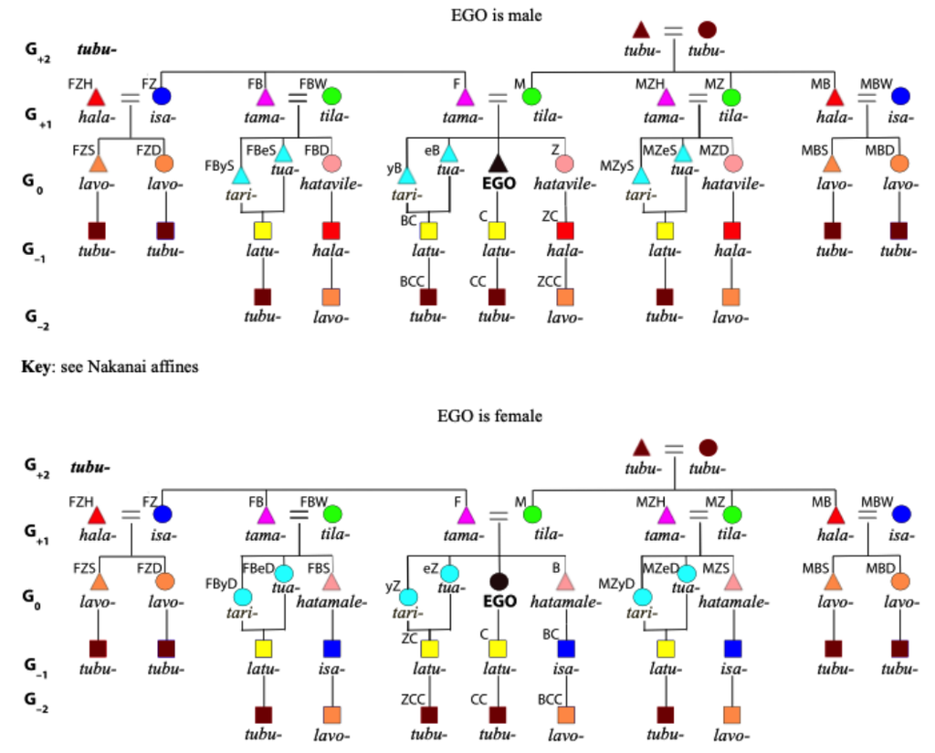

**Figure 2.1:** Terms for blood relations in Nakanai

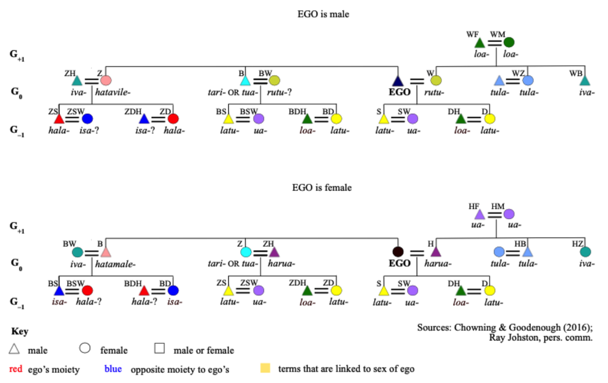

**Figure 2.2:** Terms for in-laws in Nakanai

Secondly, in the middle of the figures is a person labelled ‘EGO’. EGO (Latin ‘I, me’) is ‘the speaker’, i.e. the person in relation to whom some other person, ALTER (Latin ‘other’), is labelled. Thus if I am EGO, my father is an ALTER labelled in relation to me. If he is defined in relation to some other EGO, he might then be my brother, my son, my grandson, and so on.

### 2.1. Attributes encoded in a kinship terminology

Figure 2.1 shows that a male EGO distinguishes between brothers who are older than him (*tua-*) and those who are younger (*tari-*), whereas English has no term with a meaning that depends on the age of ALTER relative to EGO.

Figures 2.1 and 2.2 show Nakanai terms from the perspectives of both a male and a female EGO.[^5] The differences between them take two forms. First, a male EGO refers to his brother as *tua-* or *tari-*, whereas a female EGO uses *tua-* or *tari-* for her sister. That is, Nakanai *tua-* and *tari-* must be glossed ‘sibling of same sex as EGO’ (usually abbreviated ‘same-sex sibling’ or ‘s.s. sibling’), not ‘brother’ or ‘sister’. The sex of *tua-* or *tari-* depends on EGO’s sex. Second, a male EGO labels his opposite-sex sibling *hatavile-*, but a female EGO refers to her opposite-sex sibling as *hatamale-*. We prefix the conventional ‘female’ and ‘male’ symbols to a gloss to indicate who uses it: thus *hatavile-* ‘♂sister’ and *hatamale-* ‘♀brother’. In English, however, no distinction between terms depends on EGO’s sex. The distinction between English *wife* and *husband* encodes ALTER’s sex, not EGO’s. Indeed, ALTER’s sex plays a significant role in the English terminology, with six basic pairs: *mother*/*father*, *aunt*/*uncle*, *sister*/*brother*, *daughter*/*son*, *niece*/*nephew* and *wife*/*husband*. Nakanai has only one: *tila-*/*tama* ‘mother/father’. Note, too, that EGO distinguishes among s.s. siblings by age relative to EGO, but labels o.s. siblings by their (ALTER’s) own sex.

In the figures and elsewhere, generations are indicated with, e.g., G₀ ‘EGO’s generation’, G₊₁ ‘one generation above EGO’, G₋₂ ‘two generations below EGO’, and so on. In Figure 2.1, *tubu-* appears against G₊₂, indicating that all members of G₊₂ are *tubu-* in Nakanai. It also exemplifies the classificatory nature of Oceanic kinship terms. The term *tubu-* labels all members of G₊₂. Most kinship terminologies include classifying terms. English has some too: *uncle* labels EGO’s father’s brothers, father’s sisters’ husbands, mother’s brothers and mother’s sisters’ husbands. *Aunt* and *cousin* are also classifying. Nakanai and English classify siblings-in-law in the same way: English *brother-in-law* refers to EGO’s wife’s brother and to EGO’s sister’s husband, and Nakanai *iva-* does the same.

Some kinship terms in Oceanic languages are used reciprocally. A Nakanai EGO refers to his/her mother’s brother as *hala-* and, when EGO is a child’s *hala-*, he refers to his sister’s child as *hala-*. That is, the term is reciprocal across generations. Figure 2.1 also shows that some grandparents and grandchildren refer to each other reciprocally as *tubu-*.

The Nakanai terminology classifies blood relatives of G₊₁ in a particular way. EGO’s father’s brother is labelled with the same term as EGO’s father, and EGO’s mother’s sister with the same term as EGO’s mother. This has two consequences. One is that father’s brother’s descendants have the same labels as father’s descendants, and mother’s sister’s descendants the same labels as mother’s. The other consequence is that what in English would be *cousins* fall into two Nakanai categories. Father’s brother’s and mother’s sister’s children are labelled as if they were EGO’s siblings, but father’s sister’s and mother’s brother’s children have a different label, *lavo-*. In the kinship literature the former are labelled ‘parallel cousins’, the latter ‘cross-cousins’. ‘Cross’ here refers to the fact that cross-cousins are related to EGO via opposite-sex parents. The classifying attribute of Oceanic kinship terms is discussed further in §2.2.3.

The last few paragraphs have touched on various attributes of kinship terminologies in general. Their presence or absence in Nakanai and English is summed up in Table 2.1. Presence is shown by a tick. A particular attribute may or may not be reflected in a terminology.[^6] For example, English has no terms that depend on sex relative to EGO.

‘Sex of linking relative’ refers to the contrast between, e.g. ‘father’s brother’ and ‘mother’s brother’.

**Table 2.1** Attributes and values of Nakanai and English terms

| Attribute | Nakanai | English | values of terms |
| --- | --- | --- | --- |
| generations distinguished | ✔ | ✔ | –2, –1, 0, +1, +2 etc |
| sex of ALTER | ✔ | ✔ | male, female, either |
| sex relative to EGO | ✔ |  | same, opposite, either |
| sex of linking relative | ✔ |  | same, male, female |
| seniority within generation | ✔ |  | elder, younger, none |
| reciprocity across generations | ✔ |  | yes, no |
| affinity | ✔ | ✔ | blood relative, in-law |

### 2.2. ‘Parallel’, ‘cross’ and kinship notation

As noted above, ethnographers use the terms ‘parallel cousin’ for cousins related to EGO via mother’s sister or father’s brother and ‘cross-cousin’ for those related to EGO via mother’s brother or father’s sister.[^7] Similar terms are sometimes used of siblings, such that a ‘s.s. sibling’ is a sibling of the same sex as EGO and a ‘cross-sibling’ or ‘cross-sex sibling’ is of the opposite sex to EGO. This usage is inconsistent, as ‘parallel cousin’ and ‘cross-cousin’ refer to their parent’s sex, not their own, and the latter sometimes needs to be stipulated as in ‘same-sex cross-cousin’ or ‘opposite-sex cross-cousin’. For consistency’s sake, we follow Murdock 1949, 1968a). replacing ‘cross-sibling’ by ‘opposite-sex sibling’ (‘o.s. sibling’).

**Table 2.2** Abbreviating kinship terms

| M | mother | (NB not ‘Male’) |
| --- | --- | --- |
| F | father | (NB not ‘Female’) |
| P | parent |  |

| Z | sister | (Z, as S is reserved for ‘son’) |
| --- | --- | --- |
| B | brother |  |
| G | sibling | (Latin *germāna*, *germānus*) |

| W | wife |  |
| --- | --- | --- |
| H | husband | (French *épouse*, *époux*) |
| E | spouse |  |

| D | daughter |
| --- | --- |
| S | son |
| C | child |

In the interests of space, glosses in cognate sets (§2.4) and figures employ a version of the conventional ethnographic abbreviations for kinship terms. Its basic building blocks are shown in Table 2.2. In each of the four sub-table, the third abbreviation, an innovation borrowed from Hage (2001b), embraces the two categories above it. These capture Oceanic categories and reduce abbreviations so that, for example, ‘parent’s sibling’ is expressed as ‘PG’, instead of the more conventional ‘FB, MB, FZ, MZ’. The syntax of these terms is straightforward, e.g. MZ ‘mother’s sister’, EGC ‘spouse’s sibling’s child’, and so on.

There are four modifiers, each abbreviated as a lower-case letter preceding one of the letters in Table 2.2. They are:

| s | same sex as EGO |
| --- | --- |
| o | opposite sex to EGO |
| y | younger than EGO within EGO’s generation |
| e | elder than EGO within EGO’s generation |

Thus oC ‘opposite sex child’; ysG ‘younger same-sex sibling’.

Relative sex is reckoned relative to EGO in order to avoid ambiguity. Hence EGsC ‘spouse’s sibling’s child of EGO’s sex’, not ‘spouse’s siblings’s child of spouse’s sibling’s sex’. However, there are terms that encode sex relative to someone other than EGO, and in these cases curly brackets are used, e.g. {PsG}C ‘child of parent’s same-sex sibling’,[^8] i.e. ‘parallel cousin’, as opposed to PsGC ‘child of parent’s sibling of EGO’s sex’.

### 2.3. Nakanai terms and their definition

Like a good many other societies in Oceania, Nakanai society has divisions based on descent (Chowning 1965 calls them ‘sibs’). Some societies, like Tolai (Fingleton 1986), have just two divisions or ‘moieties’. Others, like Nakanai, have several divisions. In many Oceanic societies descent is matrilineal (see ch 3). In other words, a child belongs to its mother’s lineage. Since marriages are between members of different divisions, this means that a father’s children belong to his wife’s division. Among EGO’s closer relatives the only members of EGO’s generation who are of another division are cross-cousins. Being of a different division from EGO, they are possible marriage candidates.

In Figure 2.1 there is just one reciprocal term for members of G₊₂ and G₋₂. This is *tubu-* ‘grandparent/grandchild’. However, at G₋₂ *tubu-* is restricted to the grandchildren of EGO’s s.s. siblings and s.s. parallel cousins, whilst the grandchildren of o.s. siblings and o.s. parallel cousins are labelled *lavo-*. This also seems to be rule-governed. Because Nakanai society is matrilineal and EGO’s spouse is of a different division from ego, male EGO’s *latu-* ‘children’ are not of his lineage or division, but his sister’s children, *hala-*, are. The situation is reversed if EGO is female: *latu-* are of her division, but *isa-* are not. The rule then stipulates one uses *tubu-* for the child of one’s *latu-*, but *lavo-* for the child of one’s *hala-* or *isa-*.

The application of *tubu-* to the children of one’s cross-cousins, i.e. relatives of the same generation as one’s children, not one’s grandchildren, is obscure, but is touched on in §2.3.3.

In many Oceanic cultures the mother’s oldest living brother has the greatest authority within his matriline to instruct his sister’s children on societal matters and to make decisions about matters such as their marriages. The way in which this authority relates to that of the father, who does not belong to his children’s division, varies from society to society. The role of the mother’s oldest brother means that there is typically a dedicated term for mother’s brothers. In Nakanai this is *hala-*. The fact that in many Oceanic cultures mother’s oldest brother had or has significant responsibilities towards his sister’s children (♂ZC) is enshrined in a special term that a male EGO uses to refer to those children. It also captures the fact that in a matrilineal society a man’s sister’s son is his heir. The special term for sister’s son/sister’s child is sometimes the term for MB, used reciprocally, as it is in Nakanai (see further §2.3.2.2).

- male blood relative of EGO’s father’s generation, related to EGO through EGO’s father’s male ancestors and their male descendants; and
- husband of female blood relative of EGO’s mother’s generation; the female relative is related to EGO through EGO’s mother’s female ancestors and their female descendants.

This definition includes ‘father’ and ‘father’s brother’ as primary referents. Both are grandfather’s sons, or FFS. They and grandfather’s brother’s son are *great-grandfather’s* *grandsons*—and so on. Tracking back through ego’s ancestry using the first part of the definition gives a set of glosses for *tama-*: FFS, FFFSS, FFFFSSS and so on, abbreviated as FnFSn, where the two instances of n are equal. Doing the same with the second part gives MnMDnH. Glosses of this kind, not used elsewhere in this chapter, serve to show that classifying terms denote theoretically unbounded but definable classes in many Oceanic languages, and are in this respect fundamentally different from English. The Tolai (MM), for example, who number in the tens of thousands, see themselves as all related[^9] and as members of one of the two Tolai divisions (moieties), and therefore as having a kin relationship with every other Tolai (Epstein 1969:122; Fingleton 1986:304).

Ethnographers argue over whether a term like Nakanai *tama-* has one meaning or more than one.[^10] Those who argue for two or more meanings (polysemy) distinguish between a narrow sense, ‘father’, and a classificatory sense, FₙFSₙ (Malinowski 1929:442, 495–96, 513, 527; Lounsbury 1965; Scheffler 2003; Shapiro 2018). Those who argue for one meaning (monosemy) regard something like the definitions above as the appropriate gloss of *tama-* (Leach 1958, attacking Malinowski; Schneider 1984). The question for a linguist is, What would a dictionary definition look like, and why? Pawley & Sayaba’s draft dictionary of Wayan Fijian has the following (edited and reordered):

> *tama-* 1. Father. 2. Classificatory father, one who is brother or classificatory brother to one’s father. 3. Uncle, specifically the husband of one’s mother’s sister or classificatory sister.

This is clearly a polysemous definition. It is perhaps a linguistic universal that speakers often use a term with a narrow sense for a larger class of which the narrow-sense referent is perceived as the most salient member. How this occurs in folk classifications of plants and animals is discussed by Evans (2008) and Pawley (2011b) respectively. The definition above is an example of this broad phenomenon in the context of a kinship terminology.

Ethnographic accounts indicate that, for example, ‘father’ in the narrow sense typically has a relationship with his offspring that is closer to them than that of his brothers and other classificatory ‘fathers’, and that speakers certainly understand and act on a difference between the two senses (Codrington 1891:36–37; Humphreys 1926:34; Malinowski 1929:442–443; Powdermaker 1933:137–138; Mead 1934:220; Blackwood 1935:59–60; Fischer 1966:117; Hogbin 1964a:17; Scheffler 1965:75–76; Wagner 1986: xvi, 62).

This issue leads into another ethnographic question. Are definitions of kinship terms cognitively real? Do they reflect speakers’ concepts? Goodenough (1956, 1965) answered ‘yes’; Burling (1964) vigorously ‘no’. A dictionary-maker would argue that dictionary definitions should be a good approximation of cognitive reality, otherwise speakers cannot agree (or disagree) with them.

## 3. The typology of Oceanic kinship terminologies

The typology of Oceanic kinship terminologies briefly presented here is based on 139 cases where a complete or near-complete terminology is available covering ego’s parents and their siblings and the parents’ and siblings’ children. Ideally each terminology should also include all their children, but many otherwise detailed ethnographies omit terms for the children of some or all of ego’s cousins. The terminologies also cover members of the grandparent and grandchild generations. Sources are in the appendix to this chapter.

These 139 languages are referred to below as ‘the sample’, but they are not a sample chosen for statistical purposes. They are simply the languages for which relevant data are available. NCV is under-represented, New Caledonia and Fiji over-represented. Nonetheless, they are distributed throughout Oceanic.

The typological investigation in §2.3.1–4 does not cover in-law terms.

### 3.1. Bifurcate merging and its modifications

The Nakanai terminology in §2.2.3 exemplifies the fact that a terminology’s semantic structure determines the meaning of each term. Conversely, each term covers one or more kinship slots, e.g. tama- covers F, FB and MZH (and more). If the slots covered by each term laterally as far as and including ego’s parents’ siblings are diagrammed, we have a visual representation of a terminology’s structure, as in Figures 2.3 and 2.4.

Lowie (1928) categorised kinship terminologies, based on how they treat G₊₁. He called terminologies like Nakanai ‘**bifurcate merging**’—‘bifurcate’, because the terms for ‘mother’ and ‘father’ are distinct, and ‘merging’ because each parent and her/his s.s. siblings are merged terminologically (called by the same term), but o.s. siblings are labelled differently (§2.2.3).

Lowie’s ‘**generational**’ category, where all uncles and aunts are treated as parents, turns up in a sprinkling of Oceanic languages (see later in this section).

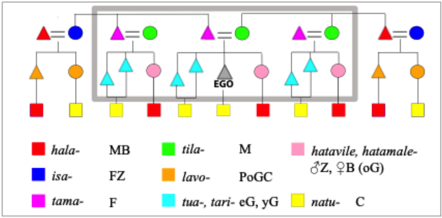

**Figure 2.3:** Structure of the Nakanai terminology, showing bifurcate merging terms

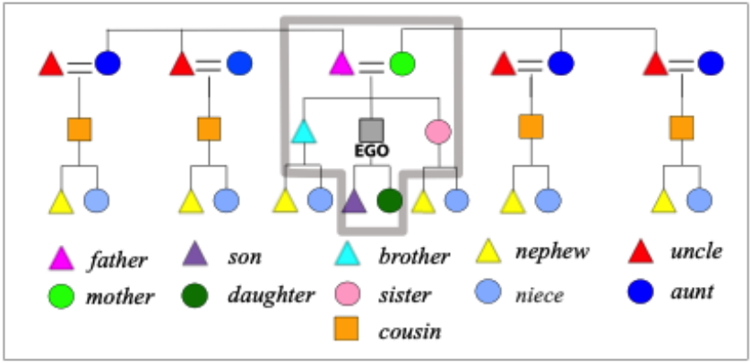

**Figure 2.4:** Structure of English terminology, showing lineal terms

English, on the other hand, Lowie classed as ‘**lineal**’ because terms for ego’s ancestors and descendants (‘lineal kin’), as well as siblings, are distinct from those for uncles, aunts and cousins (‘collateral kin’), which are all categorised by generation. There are no Oceanic lineal terminologies.[^11]

The grey rectangle in Figure 2.3 encloses the part of the terminology that is ‘merged’.

A working definition of ‘merging’ is needed here. Sources sometimes give binomials (terms consisting of two lexical items), like Sye (SV) *drinme- pelaɣ* ‘mother’s sister’, where *drinme-* is ‘mother’ and *pelaɣ* apparently means ‘removed’, ‘apart’ or, with kinship terms, ‘adoptive’ (there is no *pelaɣ* entry in Crowley 2000). Because the second, modifying, part of many binomials is omitted in daily use, a kinship binomial like *drinme- pelaɣ* is counted for analytic purposes as ‘the same’ as *drinme-* ‘mother’, i.e., as merged.

Of the 139 sample languages, 65 (47%) are bifurcate merging in accordance with the definition above.

At the core of a bifurcate merging structure are the mergers in (2) above and, remarkably, they are found in 137 of the 139 sample languages. One language, Sye, lacks one of the mergers in (2a), and two, Sye and Nadrau Fijian, lack (2b).[^12] However, whereas the mergers in (2) are near-universal in Oceanic, there are numerous languages that do not conform to the definitions in (3), because at least one term for a merged category is extended to include a G₊₁ or G0 term outside the rectangle. In some languages the restriction in (3a) is breached, in others the restriction in (3b), and in yet others both restrictions in (3). The languages in which each breach occurs are shown in Table 2.5.

**Table 2.5** Oceanic terminologies with bifurcate merging and breaches thereof

|  | Bifurcate merging | FZ = M | FZ = M and MB = F | PGC = G |
| --- | --- | --- | --- | --- |
| Adm | Mussau, Sori, Lele, Pak, Baluan, Lou | Yapese | — | — |
| SJ and NNG | Yabem, Bukawa, Middle Watut | Sobei, Wogeo, Mapos Buang | — | o.s: *Takia*, *Adzera*, *Mapos Buang* |
| PT | Kilivila, Muyuw, Dobu, Galea, Sudest | Kalauna, Tubetube | N Mekeo | Bwaidoga, Sinaugoro (Saroa), Motu, Roro, N Mekeo |
| MM | Nakanai, W Kara, Lakurumau, Nalik, Lihir, Notsi, Lamusong, Lelet, Usen Barok, Sursurunga, Patpatar, Tolai (both) | Nehan, Petats, Hahon, Mono-Alu, Nduke, Roviana, Marovo, Varisi | Simbo | *Vitu* (o.s.), Mono-Alu, Varisi, Simbo, Nduke, Roviana |
| SES | NWGR,¹ Baegu, E Arosi | Bugotu, Gela, Lengo, Birao, Longgu, Kwaio, Sa’a, Fagani, W Arosi, Owa | — | W Guadalcanal (Gae), Lengo, To’aba’ita, Kwaio, Fagani, W Arosi, Owa |
| NCV | Araki, Raga, Big Nambas, N Ambrym, Nguna | Loh, Mota, Akei, NE Ambae, Nduindui, Vao, Ninde, Sinesip | — | Loh |
| SV | Kwamera | Anejom | — | — |
| NCal | Belep, Nyelâyu, Yuanga, Kumak, Fwai, Pwaamei, Bwatoo, Wahmwaang, Cèmuhî, Paicî, Arhâ, Ajië, Xârâcùù, Xaragure, Numèè, Kwenyii | — | — | Nengone, Drehu, Iaai |
| Mic | — | Nauruan, Marshallese, Satawalese | Chuukese | *Marshallese* (s.s.), Satawalese, Chuukese, Lamotrek |
| Fij | Wayan, Vuda, NW Viti Levu, Deuba, Kadavu, Bauan, Nadrau, Tokatoka, Moala, Matailobau, Lakeba | Cakaudrove, Macuata | — | Tavua, MacuataTokatoka |
| Pn exc EPn | Ifira-Mele, W Futunan | Rennellese, Takuu, Luangiua, Sikaiana | Pukapuka | Tongan, Tokelau, E Futunan, *Rennellese* (s.s.), Anuta, Tikopia, Pileni, Luangiua, Sikaiana |
| EPn | — | — | Tahitian, Māori, Rapa, Hawaiian | Rapa, Maori, Tahitian, Marquesan, Hawaiian |

¹ NWGR = Rivers’ (1914) Northwest ‘Guadalcanar’.

Taking (3a) first, two breaches occur:

1. EGO’s father’s sister is called by the term for mother/mother’s sister (FZ = M: 44 cases);
2. EGO’s father’s sister and mother’s brother are called respectively by the terms for mother/mother’s sister and father/father’s brother (FZ = M, MB = F: 8 cases);

The case numbers tells us that FZ = M occurs far more often than MB = F. Furthermore, there is an implicational relationship such that MB = F only occurs where FZ = M occurs, but never vice versa. The distinctiveness of the ‘mother’s brother’ category is almost as durable as the mergers in (2), whereas the ‘father’s sister’ category is readily lost.

Turning to (3b), three breaches occur:

3. EGO’s cross-cousin is called by a term for sibling/parallel cousin (MBC = FBC = FZC = MZC = G, i.e. PGC = G); this may apply to
   - only s.s. cross-cousins (2 cases);
   - only o.s. cross-cousins (4 cases);
   - all cross-cousins (40 cases).

Terminologies in which the breach applies only to s.s. or only to o.s. cross-cousins are shown in italics in the rightmost column of Table 2.5.[^13]

Each of these breaches brings a system nearer to Lowie’s generational category. The outcome of (i) above is that all female members of G₊₁ are called ‘mother’, of (ii) that all members of G₊₁ are called ‘mother’, ‘father’ or ‘parent’. The outcome of (iii), when it applies to all cross-cousins, is that all members of G₀ are called by sibling terms. Note that (i), (ii) and (iii) do not affect distinctions of sex (absolute or relative-to-ego) or relative age that a terminology may make.

Of the 46 languages where PGC = G (Table 2.5, rightmost column), 22 have no other tendency toward a generational structure (Table 2.6, column 1).

**Table 2.6** Oceanic kinship terminologies that tend toward Lowie’s generational structure

|  | 1 | 2 | 3 | 4 |
| --- | --- | --- | --- | --- |
|  | Only PGC = G | Only PGC = G and FZ = M | PGC = G and FZ = M and MB = F | PGC = G and FZ = M and MB F and M = F |
| Adm | — | — | — | — |
| SJ and NNG | *Takia*, *Adzera* (o.s.) | *Mapos Buang* (o.s.) | — | — |
| PT | Bwaidoga, Sinaugoro (Saroa), Motu, Roro | — | N Mekeo | — |
| MM | *Vitu* (o.s.) | Mono-Alu, Nduke, Roviana, Varisi | Simbo | — |
| SES | W Guadalcanal (Gae), To’aba’ita | Lengo, Kwaio, Fagani, W Arosi, Owa | — | — |
| NCV | Loh | Loh | — | — |
| SV | — | — | — | — |
| NCal | Nengone, Drehu, Iaai | — | — | — |
| Mic | Lamotrek | *Marshallese* (s.s.), Satawalese | Chuukese | — |
| Fij | Tavua | Macuata, Koroalau | — | — |
| Pn exc EPn | Tongan, Tokelau, E Futunan, Anuta, Tikopia, Pileni | — | *Rennellese* (s.s.), W Futunan, Takuu, Luangiua, Sikaiana | Pukapuka |
| EPn | Marquesan | — | Rapa, Maori | Tahitian, Hawaiian |

Two groups in Table 2.6 deserve comment. The first of these is the Central Papuan subgroup of PT. Sinaugoro, Motu, Roro and North Mekeo are the Central Papuan languages in the sample. The Roro structure is shown in Figure 2.5. Sinaugoro, Motu and Roro retain bifurcate merging in the parental generation but have generational terminology in ego’s generation, i.e. all ego’s siblings and cousins are identically labelled, according to seniority. This was probably the situation in Proto Central Papuan. North Mekeo, however, adds generational terminology at G₊₁, shown in Figure 2.6. This is almost a full-blown generational terminology, as are the others listed in column 3 of Table 2.6.

The other group in need of comment is Polynesian. Only Ifira-Mele and West Futuna (= Futuna-Aniwa) are listed in Table 2.5 as bifurcate merging. There is good reason to infer that the structure of the Ifira-Mele terminology is the result of contact with NCV languages of Nguna (§2.3.3). The same may be true of West Futuna, which has had contact with the languages of Tanna (SV).(Lynch & Fakamuria 1994). It is probable that PPn had a terminology like that of Tongan and similar to Roro (Figure 2.5), in which all blood-relatives of ego’s generation were labelled in the same way as ego’s siblings, but the parental generation had dedicated terms for FZ and MB (Marck 1996). Loss of FZ and MB terms in various of the outliers and in PEPn resulted in structures like that in North Mekeo. However, Pukapuka, Tahitian and Hawaiian have also replaced PPn *tina- ‘mother’ (§2.4.1.2.1) and *tama- ‘father’ (§2.4.1.2.1) with a reflex of *matuqa- ‘parent’ (§2.4.1.2.3). The elimination of the sex distinction in the parental generation has resulted in a purely generational structure in Lowie’s (1928) sense, leading to the adoption of ‘Hawaiian’ as the term for a generational structure in Murdock’s (1949) classification of kinship terminologies.

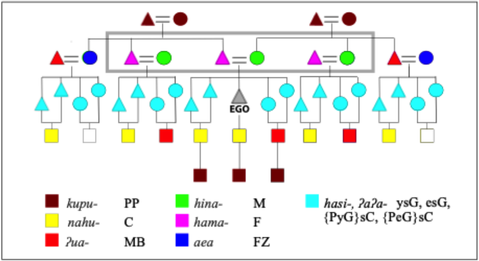

**Figure 2.5:** Structure of the Roro terminology, showing bifurcate merging terms

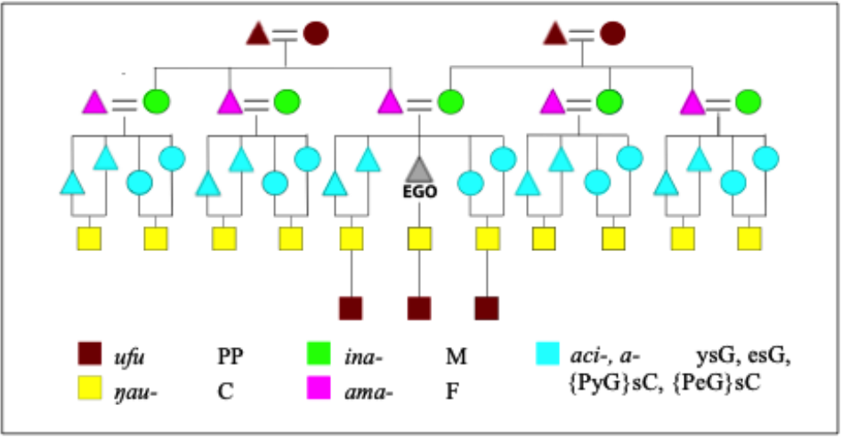

**Figure 2.6:** Structure of the N Mekeo terminology

### 3.2. Other structural features involving ego’s blood relatives

#### 3.2.1. EGO’s siblings and parallel cousins

Bifurcate merging means that in almost every Oceanic terminology, EGO’s parallel cousins, i.e. EGO’s father’s brother’s and mother’s sister’s children, are labelled with the same terms as EGO’s siblings (§2.3.1). However, there is considerable variation in this labelling. For example, there may be a terminological distinction between s.s. and o.s. siblings/parallel cousins; or a seniority distinction among siblings/parallel cousins.[^14]

These distinctions are structurally independent of bifurcate merging. The most frequently found distinction is between s.s. and o.s. siblings/parallel cousins. Following this pattern, speakers of earlier New Guinea Pidgin took the terms *susa* and *brata* from English *sister* and *brother* but used them in an Oceanic manner. If I was female, my *brata* was my sister (s.s. sibling) and my *susa* was my brother (o.s. sibling). These two categories are further subdivided in many Oceanic terminologies. A common pattern is illustrated by Nakanai (§2.2.3; Figure 2.3), where s.s. siblings are divided into those elder (*tua-*) or younger (*tari-*) than EGO, but o.s. siblings are divided into female (*hatavile-*) and male (*hatamale-*).

There are thus three sibling distinctions in Oceanic languages:

- relative sex: same sex as EGO vs opposite sex from EGO (sG vs oG)
- seniority: younger than EGO vs elder than EGO (yG vs eG)
- ALTER’s sex (Z vs B)

Eleven configurations of these distinctions occur in Oceanic languages, and Table 2.7 shows the number of times each configuration occurs in the sample.[^15] Column 1 shows whether a terminology makes the relative sex distinction (y[es] or n[o]). If it does, then there are entries in columns 2 to 5. Columns 2 and 4 show whether the seniority distinction is applied respectively to s.s. and o.s. siblings. Columns 3 and 5 do the same for ALTER’s sex. But if column 1 shows that a terminology lacks the relative sex distinction, then columns 4 and 5 are blank, because o.s. siblings are referred to by the same terms as s.s. siblings. For example, Nakanai makes the s.s./o.s. distinction (column 1), the seniority distinction for s.s. siblings (column 2), and uses different o.s. terms according to ALTER’s sex (column 5). It is thus one of the 17 languages with the configuration in row 6. The column totals show that only four terminologies distinguish ALTER’s sex in the terms for s.s. siblings, and that only three distinguish seniority of o.s. siblings. The four configurations that include one of these distinctions are shown in grey (3, 4, 7 and 8) and are presumably the outcomes of local accidents.[^16] Theoretically, 20 configurations are possible, but only 11 occur in Table 2.7—or more properly ten, as row 9 contains question marks for unknown values.[^17] Whilst one can speculate about the reasons for the absence or near-absence of certain configurations, it is clear that they reflect absences from the POc terminology (§2.3.5). Table 2.8 shows the languages in the six most attested categories in Table 2.7.

**Table 2.7** Distributions of sibling distinctions across Oceanic languages

|  | 1 | 2 | 3 | 4 | 5 |  |
| --- | --- | --- | --- | --- | --- | --- |
| config. | sG/oG | ysG/esG | sZ/sB | yoG/eoG | oZ/oB | Totals |
| 1 | y | n | n | n | n | 42 |
| 2 | y | n | n | n | y | 9 |
| 3 | y | n | n | y | n | 2 |
| 4 | y | n | y | n | n | 3 |
| 5 | y | y | n | n | n | 38 |
| 6 | y | y | n | n | y | 17 |
| 7 | y | y | n | y | n | 1 |
| 8 | y | y | y | n | y | 1 |
| 9 | y | y | n | ? | ? | 8 |
| 10 | n | n | n | — | — | 5 |
| 11 | n | y | n | — | — | 12 |
| Total y | 121 | 77 | 4 | 3 | 27 |  |
| Total n | 17 | 61 | 134 | 110 | 86 |  |
|  |  |  |  |  | Grand total: | 138 |

**Table 2.8** Terminologies according to the better represented configurations in Table 2.7

|  | Config 1 | Config 2 | Config 5 | Config 6 | Config 10 | Config 11 |
| --- | --- | --- | --- | --- | --- | --- |
| Adm | Sori, Lele |  | Pak | Baluan, Lou | Yapese | Mussau |
| SJ and NNG | Takia, Adzera | Mapos Buang, Lakurumau, Roviana, Marovo, Big Nambas, Anejom | Wogeo, Yabem, Middle Watut |  |  |  |
| PT | Dobu, Galea, Tubetube, Sudest |  | Kilivila, Muyuw, Kalauna, Bwaidoga, Sinaugoro |  |  | Motu, Roro, N Mekeo |
| MM | Vitu, W Kara, Nalik, Lihir, Notsi, Lamusong, Madak, Barok, Sursurunga, Nehan, Petats, Hahon, Mono-Alu | Lakurumau, Roviana, Marovo | Varisi, Nduke, Simbo | Nakanai |  |  |
| SES | Gae, Lengo, Sa’a, W Arosi, E Arosi |  | Bugotu, Gela, Birao, Longgu, To’aba’ita, Baegu |  | NWGR | Kwaio, Fagani, Owa |
| NCV | Loh, Araki, Nduindui, N Ambrym, Nguna | Big Nambas | Mota, NE Ambae, Raga, Vao, Ninde | Sinesip |  |  |
| SV |  | Anejom |  | Kwamera |  |  |
| NCal |  |  | Drehu, Iaai | Kumak, Ajië, Xârâcùù, Nengone | Belep, Jawe | Nyelâyu, Cèmuhî, Paicî |
| Mic | Satawalese, Lamotrek | Chuukese |  | Marshallese | Nauruan |  |
| Fij | Moala |  | most Fijian languages |  |  | Matailobau, Koroalau |
| Pn exc EPn | E Futunan, Anuta, Tikopia, Ifira-Mele, W Futunan, Takuu, Luangiua, Sikaiana | Tokelau, Rennellese | Pukapuka | Tongan, Pileni |  |  |
| EPn |  |  |  | Rapa, Maori, Tahitian, Marquesan, Hawaiian |  |  |

In the vast majority of Oceanic languages, terms for parallel cousins are identical to those for siblings, but there is a dimension that is not represented here. In some languages, as one might expect, terms for EGO’s younger and elder siblings are applied to EGO’s younger and elder parallel cousins. In other languages, however, the terms make reference not to EGO’s seniority but to seniority of the cousin’s parent relative to EGO’s parent. For example, if the parallel cousin is EGO’s mother’s sister’s child, the choice of the ‘younger’ or ‘elder’ term depends on whether the cousin’s mother is younger or elder than EGO’s mother. This matter is not pursued here, as the data often do not allow us to determine who seniority refers to in a given terminology.

#### 3.2.2. Children

The role of mother’s brother and his relationship with his sister’s children are discussed briefly at the end of §2.2.3. In 52 terminologies each refers to the other by the same dedicated dedicated term (column 1 of Table 2.9). In 55 others, there is a separate term for each relationship (column 2). In yet others, there is no dedicated term for ‘sister’s child’ and the latter is not distinguished from other children. It is either referred to simply as a ‘child’ or by another kinship term, the narrow meaning of which is shown in parentheses (column 3). Among the items in column 2, in Simbo (MM), Pukapuka, Rapa and Māori (EPn) the MB term is the term for ‘father’.

An odd phenomenon, commented on several times in the literature, occurs in certain SES languages. In Bugotu, Gela, Lengo and Owa, the MB term reflects POc *tubu- ‘grandfather’ but does not retain this meaning. It is also used reciprocally for ♂ZC.

In a few WOc languages an apparent mirror-image of the MB/♂ZC relationship is enshrined in the terminology: FZ and ♀BC are referred to by the same term. These languages are Muyuw, Galea, and Motu (PT), and Vitu and Nakanai (MM). However, terms used only by a female ego and terms for children other than ego’s child and ego’s sister’s child are often not recorded, so we do not know how widespread this reciprocal usage is.

**Table 2.9** Terms for male EGO’s sister’s child

|  | 1 | 2 | 3 |
| --- | --- | --- | --- |
|  | MB = ♂ZC | MB, ♂ZC | MB, ♂ZC = C |
| Adm | Yapese, Mussau, Lele, Pak | Baluan, Lou | Sori (sG) |
| SJ and NNG | Sobei, Wogeo, Takia, Mapos Buang | Yabem, Bukawa, Middle Watut |  |
| PT | Kilivila, Muyuw, Kalauna, Dobu, Galea, Sinaugoro, Motu, Roro | Tubetube | Bwaidoga, N Mekeo |
| MM | Vitu, Nakanai, W Kara, Lakurumau, Nalik, Lamusong, Barok, Sursurunga, Trivett’s Tolai, Matupit Tolai, Nehan, Hahon, Mono-Alu, Nduke, Marovo | Patpatar, Petats, Simbo | Lihir (oGC), Notsi (oGC), Varisi (CC), Roviana |
| SES | NWGR, Birao, Longgu, To’aba’ita, Kwaio, Sa’a, Fagani, W Arosi, E Arosi |  |  |
| NCV | Loh , Araki, Vao | Mota, Raga, N Ambrym, Akei, NE Ambae, Nduindui, Big Nambas, Ninde, Sinesip, Nguna |  |
| SV |  | Sye, Kwamera | Anejom |
| NCal | Nyelâyu , Kumak, Fwai, Pwaamei, Wahmwaang, Cèmuhî | Yuanga, Bwatoo, Arhâ, Ajië, Paicî, Xârâcùù, Xaragure, Nengone, Drehu | Kwenyii |
| Mic | Nauruan | Marshallese, Satawalese, Lamotrek | Chuukese |
| Fij | Bauan | Vuda, Wayan, Nadrau, Tokatoka, Matailobau, Tavua, Deuba, Nakoroka, Cakaudrove, Moala, Lakeba, Lau | Koroalau (CC), Macuata |
| Pn exc EPn |  | Tongan, Tokelau, E Futunan, Anuta, Tikopia, Ifira-Mele, W Futunan |  |
| EPn | Marquesan | Pukapuka, Rapa, Maori | Tahitian, Hawaiian |

In a scattering of languages the children of EGO’s male blood relatives and those of female blood relatives are referred to by different terms. In these languages the term for the children of females is usually the term used for ♂ZC. Our data are in this respect too incomplete for a listing of languages to be meaningful.

In a relatively small number of languages a sex distinction is made among children. There are dedicated kinship terms for female and male children in Pak, Baluan and Lou (Adm), Lihir, Notsi, Lamusong, Barok and Patpatar (MM, New Ireland), N Ambrym (NCV) and Tongan, Tokelau, E Futuna and Rennellese (Pn).

#### 3.2.3. Grandparents and grandchildren

Some Oceanic languages have a dedicated term for mother’s mother’s brother (e.g. Tolai *kaku-*; see also §2.3.3), but a majority encode all grandparents and members of EGO’s grandparents’ generation with a single term (often a reflex of POc *tubu-; §2.4.1.4.1). Other languages do make a distinction between female and male members of the grandparent generation. Our data are incomplete in this regard, but these languages include: Notsi, Sursurunga and Mono-Alu (MM); Bugotu, Sa’a, W Arosi and Fagani (SES); Akei, Big Nambas, Ninde and Nguna (NCV); almost all NCal languages (exceptions are Belep in the north, Kwenyii in the south, and the languages of the Loyalties); Marshallese, and Lamotrek (Mic), numerous and scattered Fijian languages, and Ifira-Mele (Pn).

Owa (SES) has a general term *pʷāpʷā* for members of the grandparent generation as well as *wauwa-* ‘grandfather’ and tura- ‘grandmother’. It is quite possible that there are other languages with a similar configuration that do not show up in the sample. Sori and Pak (Adm) are recorded with separate terms for PF, MM, FM. On the other hand, a few languages have no ‘grandparent’ terms, instead using ‘mother’ and ‘father’ for both parents and grandparents. They are Simbo, Nduke and Roviana (MM), Numèè (NCal) and Satawalese and Chuukese (Mic).

Data on ‘grandchild’ terms are more complete, and fall into two categories:

- a ‘grandparent’ term is used reciprocally of both grandparents and grandchildren;
- there is a dedicated ‘grandchild’ term.

These categories mostly follow genealogical boundaries. A ‘grandparent’ term is used reciprocally to refer to grandchildren in Mussau, NNG, PT, MM, SES and Marshallese (Mic). A dedicated grandchild term is used in Yapese, Adm, NCal including the Loyalties, and throughout Fiji and Polynesia. NCV languages in the sample are divided. Most have a ‘grandchild’ term, but the northern languages Loh, Mota and Araki use ‘grandparent’ reciprocally.

Languages that also use ‘mother’ and ‘father’ for grandparents are exceptions to these generalisations. Roviana uses ‘father’ reciprocally for a grandchild, Nduke has ‘child’s child’, and Numèè (along with Kwenyii), Satawalese and Chuukese use ‘child’ for grandchildren as well as children.

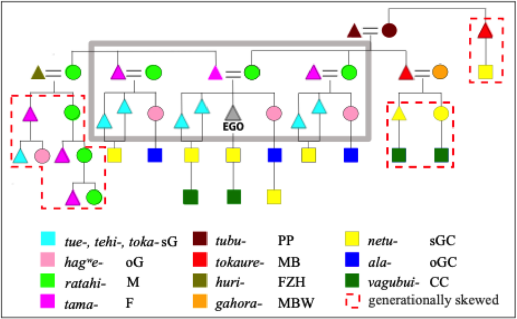

**Figure 2.7:** Structure of the NE Ambae terminology, with bifurcate merging terms

### 3.3. Generational skewing

A small number of languages in the sample have ‘cross’ terms with extended meanings that are mostly quite unlike those in Nakanai. These are exemplified by NE Ambae, a north Vanuatu language (Figure 2.7).[^19]

Within the merged portion of the terminology, the structure of NE Ambae (Figure 2.7) differs from Nakanai (Figure 2.3) only in the unusual addition of *tue-* ‘s.s. sibling’ as a cover term for both *tehi-* ‘younger s.s. sibling’ and *toka-* ‘elder s.s. sibling’.

It is the ‘cross’ portion of the NE Ambae terminology in Figure 2.7 that is of particular interest. On the left-hand side of the figure, father’s sister is also called *ratahi-* ‘mother’, and so are the female descendants in her matriline, i.e. FZD, FZDD, FZDDD. Their brothers (FZS, FZDS, FZDDS) are all called *tama-* ‘father’. The children of each *tama-* are labelled in the same way as the children of the three *tama-* in the merged portion of the figure.

The right-hand ‘cross’ portion of the terminology is different. The children of EGO’s mother’s brother are called *natu-* ‘child’, and their children *vaɣabui-* ‘grandchild’.

The technical term for this phenomenon is ‘**generational skewing**’. On the left of the figure, ‘mother’, ‘father’ and the two sibling terms are used of women a generation or more below EGO’s mother. On the right of the figure, ‘child’ and ‘grandchild’ are used of individuals a generation above EGO’s child and grandchild. Skewing is also found in various locations outside the Austronesian family (see Lounsbury 1964a and the contributions to Trautmann & Whiteley 2012).

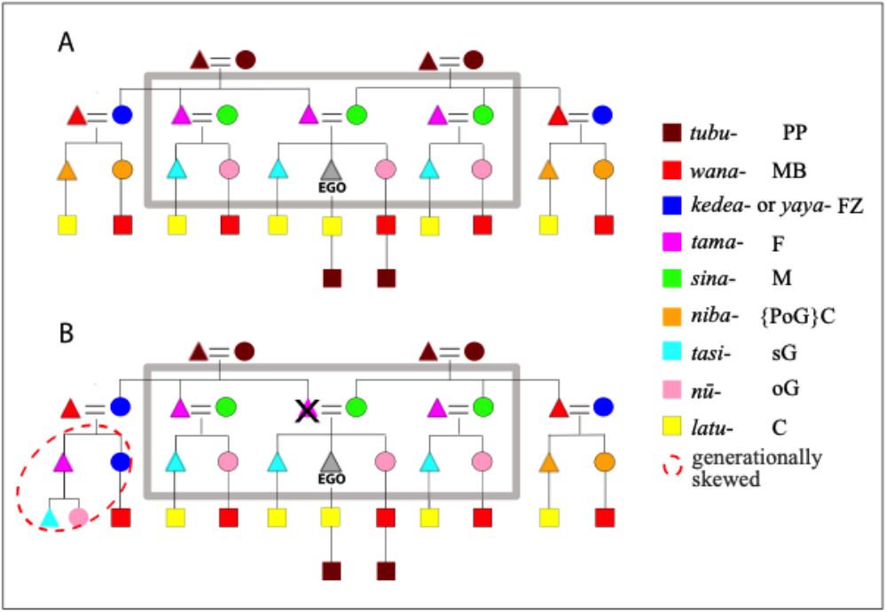

**Figure 2.8:** The structures of the two states of the Dobu kinship terminology

There is a plentiful literature on generationally skewed terminologies, asking how they come into being and what function they serve. However, a few things seem reasonably clear. There are two varieties of generational skewing. One is like NE Ambae, in Murdock’s terms a ‘Crow’ terminology. Its mirror-image, ‘Omaha’, is not represented in Oceanic. Kohler (1897) found that ‘Crow’ terminologies were correlated with matrilineal societies, ‘Omaha’ with patrilineal. This correlation stands as a high probability, but not an absolute, as examples of patrilineal Crow and matrilineal Omaha have since been found. The converse does not hold, i.e. unilineal (matri- or patrilineal) descent is not a good predictor of generational skewing. For example, Nakanai society is matrilineal but its terminology is not skewed.

The witness of speakers of languages with a skewed terminology gives us some indication of how skewing happens. Deacon’s ‘best’ informant for Semiang (= Sinesip, NCV) volunteered the information that if a male EGO’s mother’s brother died, by custom EGO would marry the MB’s widow, thereby becoming ‘father’ to MB’s children, and calling them ‘child’, accounting for the right-hand side of Figure 2.7. Conversely, if EGO is among the children of the deceased, then their cross-cousin becomes their ‘father’, accounting for the left-hand side (Deacon 1934:77-78). It seems that these uses in this circumstance have become entrenched, resulting in the skewed terminology.

Kronenfeld (2012) describes a two-state terminology in the Fanti language of Ghana. The situation is similar to that in Dobu. Kronenfeld takes issue with the concept of a ‘Crow’ terminology, viewing it as a generally skewed overlay on an existing bifurcate merging (‘Iroquois’) terminology. The Fanti two-state terminology can be taken as corroborating Fortune’s account of Dobu and its historical role.

To ‘qualify’ as a fully skewed system the changes illustrated by NE Ambae in Figure 2.7 are expected:

1. on the father’s side
   1. father’s sister’s matrilineal female descendants (FZD, FZDD, FZDDD) are referred to with the same term as FZ;
   2. father’s sister’s matrilineal male descendants (FZS, FZDS, FZDDS) are called ‘father’;
   3. the children of father’s sister’s matrilineal male descendants (FZSC, FZDSC, FZDDSC) are called by the same terms as EGO’s siblings (i.e. as the children of a ‘father’)
2. on the mother’s side
   1. mother’s brother’s child is called by the term for EGO’s child’;
   2. mother’s brother’s grandchild is called by the term for EGO’s grandchild.

Twenty-one languages in the sample show signs of generational skewing, but only three, Mota, NE Ambae and Nguna (all NCV) qualify fully. The evidence is set out schematically in Table 2.10.[^20] The abbreviations in the first row are relationships in a genealogical tree. The abbreviations beneath them represent the narrow sense of the term that is used for that relationship. In NE Ambae, for example, the relationship of father’s sister (FZ) is referred to by the term for mother (M), the relationship of father’s sister’s son (FZS) by the term for father (F), and so on. Terms that do not reflect generational skewing are omitted for readability’s sake.

**Table 2.10** Oceanic languages reflecting generational skewing

| gloss | FZ | FZS | FZD | FZSC | FZDS | FZDD | MBS | MBD | MBSC | MBDC |
| --- | --- | --- | --- | --- | --- | --- | --- | --- | --- | --- |
| Yapese | M | F | M | G | G |  | C | C |  | CC |
| Sori | FZ | F | FZ |  |  |  |  | C |  |  |
| Lele | FZ¹ | F | FZ |  |  | FZ |  | D |  |  |
| Pak | FZ | FZS FZ |  | G | FZS | FZ |  | D | CC |  |
| Kilivila | PP | F | PP |  | FZ | FZ | C | C |  |  |
| Dobu state B | FZ | F | FZ |  |  |  |  |  |  |  |
| Sudest | FZ |  |  |  |  |  | C² | C² |  |  |
| Nakanai |  |  |  | *PP* | *PP* |  |  |  | PP | PP |
| Notsi |  |  |  | *PP* | *PP ³ |  |  |  | PP | *PP³ |
| Lamusong | FZ |  |  | G | FZ |  |  |  | G | *FZ* |
| Usen Barok |  |  |  | G |  |  |  |  | G |  |
| Trivett’s Tolai | PP |  | PP |  |  | PP |  | F |  | PP |
| Mota | M | F | M | G | F | M | C | C | PP | PP |
| Akei | M | F | M |  |  |  | C | C | CC |  |
| NE Ambae M |  | F | M | G | F | M | C | C | CC | CC |
| Nduindui | M | F | M | G | *G* |  | C | C | CC | CC |
| Raga | FZ | F | FZ |  | F | FZ | C | C |  | CC |
| Ninde | FZ | F | FZ | G | *G* |  | C |  |  | CC |
| Sinesip | M | F | M |  |  |  | C | C |  |  |
| Nguna | FZ | F | FZ | G | F | FZ | C | C | G | G |
| Ifira-Mele | FZ | F | FZ |  |  |  | C | C |  |  |

- ¹ Father’s mother is also called by the FZ term.
- ² Alternates with the term for cross-cousin.
- ³ The term is *tubo-*, reflecting POc *tubu PP, not reflected as PP in Notsi.

The backbone of the skewed system is the terms for the matrilineal female, FZ, FZD and FZDD, shown in grey. The observation here is that whatever term is used for FZ is also used for FZD, FZDD and FZDDD (FZDDD is not shown; cf Figure 2.7). In some languages, e.g. Lele (Adm), the same term is projected upwards, i.e. used for FM. The matrilineal female’s brother (FZS, FZDS) is labelled as ‘father’ (F). In Pak (Adm) a special term is used for FZS, which is then also used for FZDS.

Abbreviations in italics represent terms that have evidently been copied from elsewhere in the paradigm. For example, Nduindui terms are almost identical to those of its neighbour, NE Ambae, but the term used for FZDS is not the expected term ‘father’ but ‘sibling’, copied from FZSC. In Nduindui matrilineal moieties have been replaced by patrilineal sections. The Nduindui terms for father’s sister’s children retain the old nomenclature, but it is lost in the following generations (Allen 1964a).

Nakanai and Notsi (both MM) show only a fragment of an assumed formerly skewed system. In a terminology with skewing on the mother’s side, mother’s brother’s children (MBS and MBD) are called ‘child’ (C), and their children (MBSC and MBDC) are called ‘grandchild’. The latter are, however, of the same generation as EGO’s children. Nakanai and Notsi retain only this peculiarity of a skewed system, and have copied the ‘grandchild’ term to the children of the paternal cross-cousins.

The sample languages include two Tolai dialects, Matupit Tolai and an unlocated dialect described by Trevitt (1940). This pair is interesting in that Matupit Tolai is unskewed, whereas ‘Trevitt’s Tolai’ (labelled thus in Table 2.10) shows signs of skewing. Both dialects are shown in Figure 2.9. Assuming the hypothesis that unskewed and skewed versions of a terminology initially coexist, Matupit Tolai represents the unskewed version, Trevitt’s Tolai a frozen skewed version. Trevitt’s Tolai uses the term *tubu-* ‘grandparent’ for FZ, FZD and FZDD, presumably because, working upward, FM is *tubu-*.[^21] FZS and FZDS are not called by the expected term ‘father’, but instead *nauva-* FZS is extended to FZDS. A peculiarity of Trevitt’s Tolai is that it uses *tama-* reciprocally of ‘father’ and ‘child’, and this is then predictably extended to mother’s brother’s daughter (but not son), whose daughter is then labelled *tubu-* ‘grandchild’.

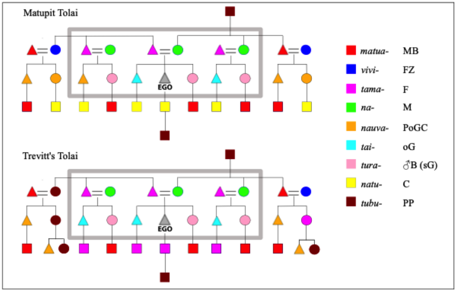

**Figure 2.9:** Two dialects of Tolai

The only Pn language with skewing is Ifira-Mele, and we attribute this to contact with neighbouring Nguna on the island of Efate.

### 3.4. The geography of typology

A review of Tables 2.5 to 2.10 reveals that typology rarely follows geographic or genealogical boundaries closely. This is scarcely surprising, as changes in terminological structure are likely to occur independently in different places. Without the terms themselves, changes do not provide a secure basis for determining shared innovations, as some of the comments published with Marshall (1984) explain. But this does not mean that the typological investigation above is irrelevant to the reconstruction of POc and the subsequent history of Oceanic languages.

The distribution of birfurcate merging (Table 2.5) is significant. It is strong in the Admiralties, in the New Britain/New Ireland area of MM, in New Caledonia other than the Loyalties, and in most of Fiji. This distribution, coupled with the fact that it is easier to derive other structures from bifurcate merging than vice versa, suggests that the POc terminology had bifurcate merging. However, it was lost among the small islands of Micronesia and eastern Polynesia.

The data supporting generational skewing are admittedly found in only a small minority of Oceanic languages, but their presence in quite widely distributed languages of the Admiralties, PT, the New Britain/New Ireland area of MM, and NCV points to the presence of skewing in POc.

**Table 2.11** Reconstructed POc kinship terms

| Gloss | Reference terms |  | Address terms |
| --- | --- | --- | --- |
| ‘father, father’s brother, mother’s sister’s husband’ | *tama- | *ama | *mama |
| ‘mother, mother’s sister, father’s brother’s wife’ | *tina-, *kina- | *ina | *(ñ,n)ana, *nai |
| ‘mother’s brother’ | *matuqa- |  | *wawa |
| ‘child of ego, s.s. sibling or parallel cousin’ | *natu-, *tu- |  |  |
| ‘♂sister’s child’ | *[qa]lawa |  |  |
| ‘♂sister’s child’ (?) | *pa(s,c)u, *pa(s,c)ua- |  |  |
| ‘kin of grandparent and grandchild generations’ | *tubu- | *ubu | *bubu, *[bu]bui |
|  | *tabu- | *abu[a] |  |
|  | *wawa[-] |  | *tete |
| ‘kin of grandchild generation’ | *makubu- |  |  |
| ‘great-great-grandparent, great-great-grandchild’ | *bawa[-] |  | *sese- |
| ‘younger s.s. sibling, younger s.s. parallel cousin’ | *taci-, *kaci- |  |  |
| ‘elder s.s. sibling, elder s.s. parallel cousin’ | *tua-, *tuaka- |  | *kaka |
| ‘♂sister’, ♂female parallel cousin’ | *papine- |  |  |
| ‘♀brother’, ♀male parallel cousin’ | *mʷaqane- |  |  |
| ‘friend, companion; relative of ego’s generation’ | *tuRaŋ |  |  |
| ‘spouse’ | *qasawa- |  |  |
| ‘woman, wife’ | *pine |  |  |
| ‘s.s. sibling-in-law’ | *ipaR/*ipa- |  |  |
| ‘o.s. sibling-in-law, younger than ego’ | *taci- |  |  |
| ‘o.s. sibling-in-law, older than ego’ | *tua- |  |  |
| ‘parent- or child-in-law’ | *rawa |  |  |

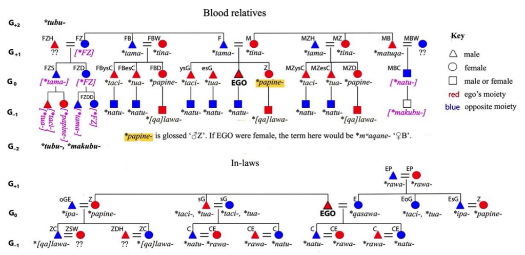

**Figure 2.10:** Reconstructed POc kinship terms

### 3.5. Reconstructing the Proto Oceanic kinship terminology

The POc kinship terms reconstructed in the subsections of §2.4.1 (blood relatives) and §2.4.2 (in-laws) are listed in Table 2.11 and plotted as a tree diagram in Figure 2. First, POc kinship terms in §2.4 were reconstructed. Then the terminology was assembled from the terms and their reconstructed glosses, but with an eye on the typology of terminologies presented in §2.3. On the division of terms into reference and address terms, and the division of certain reference terms into *t-initial and *t-less, see §2.4.1.1.

The glosses of the terms for ‘father’ and ‘mother’, based on glosses of their reflexes, support the typological evidence above that POc terminology was bifurcate merging (§2.3.1). The s.s. sibling terms distinguished *taci- ‘younger s.s. sibling’ from *tua- or *tuaka- ‘elder s.s. sibling’. The o.s. sibling terms differentiated between the directly possessed terms *papine- ‘♂o.s. (female) sibling’ and *mʷaqane- ‘♀o.s. (male) sibling’. These were also the POc terms for ‘wife’ and ‘husband’ (vol.5:50–55), but when they referred to spouses they were indirectly possessed. Putative *lopu- ‘o.s. sibling’ is omitted from both the figure and the table as its POc status is uncertain (§2.4.1.5.3).

There is broad agreement that early Oceanic society was matrilineal. In his survey of earlier findings of Oceanic matrilineality Blust (1981c:70–72) notes that Codrington (1891:30), Deacon (1934:705), and Capell and Lester (1945-46, part 4:315) had all suggested that at least in some parts of Melanesia, where societies with moieties are interspersed with societies that lack them, moieties are a retention, a view that Blust endorses. In his 1994 paper he shows that POc matrilineality was inherited from PMP, and points to Murdock’s (1968a) survey of sibling terminologies, which finds that the same-sex/opposite-sex opposition is correlated with the presence of descent groups and especially with matrilineality. More recently Hage (1999; this volume), Hage & Marck (2003) and Marck (2008) have also argued vigorously in favour of POc matrilineality, partly on genetic grounds.

If POc was indeed matrilineal, then it presumably had two moieties like those of Tolai, NE Ambae and a number of other Oceanic languages (§2.2.3). Symptomatic of this is the presence of two terms for ‘child’. POc *[qa]lawa- denoted in its narrow sense ‘sister’s child’ (i.e. the one to whom EGO was mother’s brother) and in its classificatory sense ‘female parallel cousin’s child’. The default term was *natu-, the only term that, as in Tolai, switches moiety according to EGO’s sex: opposite moiety to EGO if EGO is male, same moiety as EGO if EGO is female.

The existence of a dedicated term, *matuqa, for EGO’s mother’s brother (literally ‘the old one’) reflects his role among his kin (§2.2.3) and is further evidence of matrineality. If the society were patrilineal, the leading male among his relatives would be his father.

### 3.6. Generational skewing in Proto Oceanic

Previous reconstructions of POc kinship terms seem to have assumed that there must have been a separate term for EGO’s father’s sister. Perhaps there was, but one cannot reconstruct it (§2.4.1.2.6). Given that most other terms for blood relatives are easily reconstructable, this blank in the terminology demands an explanation, and a fairly straightforward one emerges from the discussion of generational skewing in §2.3.3. Like Dobu, POc apparently had two states, a state A in which there were dedicated terms for father’s sister and for cross-cousins and their children, and a state B in which these terms were replaced by generationally skewed terms. Assuming that early Oceanic speakers lived in small hamlets with perhaps one or two extended families scattered along coastlines (vol.1:62), it is possible that children rarely heard the state A terms, rendering them liable to the replacement which is visible in the data. The few generationally skewed terminologies that exist today reflect a freezing of all or parts of state B (Table 2.10, plus others not included in the sample), but most Oceanic terminologies reflect state A, with variations resulting from a past two-state situation.

In the POc terminology in Figure 2 the slots with terms in square brackets are essentially gaps. No distinct terms can be reconstructed for them. They are in the lineages that involve cross-cousins: father’s sister and her descendants and mother’s brother’s descendants. The terms in the brackets are the generationally skewed terms that would have been used in state B, with the exception of ‘father’s sister’. This is shown as [*FZ] because the POc term is unknown. It was perhaps *tina- ‘mother’ or *tubu- ‘grandparent’, both discussed below.

The evidence of the languages listed in Table 2.10, like NE Ambae (Figure 2.7) and Trevitt’s Tolai (Figure 2.9), leads us to expect that EGO’s mothers’ brother’s children will be called ‘child’, despite the fact that they are of EGO’s generation. This extract from the data for ‘child’ in §2.4.1.3.1 confirms this. Glosses not relevant to generational skewing have been removed. A majority of the reflexes are from NCV languages. This is not surprising, as generational skewing, at least in the north of the region, is mentioned in the ethnographic literature. The presence of reflexes from the Admiralties, PT, MM (western Solomons), the Loyalties and Micronesia makes it likely that the sense ‘mother’s brother’s child’ is of POc antiquity.

| **POc** |  | *natu- | ‘child, s.s. sibling’s child, parallel cousin’s child, **mother’s brother’s child**’ |
| --- | --- | --- | --- |
| Adm | Pak | *naro-* | [♀MBC] ‘child’ |
| PT | Kilivila | *latu-* | [♂MBC] ‘child’ |
| MM | Tolai | *tama-* | [MBC] ‘father, child’ (Trevitt 1940) |
| MM | Marovo | *tu-* | [MBC] ‘child’ |
| NCV | Mota | *natu-* | [MBC] ‘child’ |
| NCV | Raga | *nitu-* | [MBC] ‘child’ |
| NCV | Tasiriki | *natu-* | [BC MBC] ‘child’ |
| NCV | Daakaka | *natɛ-* | [MBC] ‘♂child’ |
| NCV | Ninde | *nitu-* | [♂BC ♂MBC] ‘child’ |
| NCV | Naman | *netu-* | [MBC] ‘child’ (Deacon 1934: 104–106) |
| NCV | Uripiv | *natu-* | [MBC] ‘child’ |
| NCV | Neve’ei | *natu-* | [MBC] ‘child’ |
| NCV | Nguna | *natu* | [MBC] ‘child’ (Facey 1989) |
| NCal | Iaai | *noko-* | [MBC] ‘child’ (Ray 1917) |
| Mic | Puluwatese | *nawɨ-* | [MBC] ‘child’ |

One would also expect that the children of EGO’s MBC would be called by the same term as ‘grandchild’, and the data give some support to this notion. POc apparently used two terms for ‘grandchild’. POc *tubu- ‘grandparent’ was used reciprocally of ‘grandchild’. POc *makubu- was not reciprocal and meant ‘grandchild; kin two generations below ego’. The terms in the set below reflect a variety of ‘grandchild’ terms, but have in common the fact that they are also used for mother’s brother’s grandchild, who was of EGO’s child’s generation, not EGO’s grandchild’s.

| **POc** |  | *tubu- | ‘grandparent, grandchild’ |
| --- | --- | --- | --- |
| **POc** |  | *makubu- | ‘grandchild; kin two generations below ego’ |
| Yap | Yapese | *tuŋin* | [BCC MBDC] ‘grandchild’ |
| Adm | Pak | *makapu-* | [sGCC MBSC] ‘grandchild’ |
| MM | Tolai | *tubu-* | [FZ FZD FZDD MBDS] ‘grandchild’ (Trevitt 1940) |
| MM | Babatana | *bazu-* | [♂MBDC] ‘grandchild’ |
| NCV | Tasiriki | *mabʷi-* | [BCC MBSC] ‘grandchild’ |
| NCV | Mota | *tupu-* | [MBCC FZCC] ‘grandparent, grandchild’ |
| NCV | Naman | *nābu-* | [MBSS] ‘grandchild’ |
| NCV | Neve’ei | *nābu-* | [MBSS] ‘grandchild’ |
| NCV | Nguna | *sūli* | [BCC ♀MBCC] ‘grandchild’ |
| NCV | Ninde | *neiʙü-* | [MBDS ♂MBSS] ‘grandchild’ |
| Fij | Lautoka | *viaŋo-* | [WZC MBCC] ‘grandchild’ |
| Fij | Tavuki | *makubu* | [BCC MBCC] ‘grandchild’ |

NE Ambae and Trevitt’s Tolai also suggest that father’s mother, father’s sister (FZ), FZD, FZDD and so on, i.e. father’s maternal line, were either labelled ‘mother’ or ‘grandparent’ in POc. The evidence for this is less than the set above, but the strength of the ‘mother’ set below (from §2.4.1.2.2) is reinforced by the Nduindui and Chuukese glosses, which include both FZD and FZDD. The POc term was presumably the well supported *tina- ‘mother’, despite the fact that Lele, Mota and Nduindui all have another term for ‘mother’. The evidence for POc *tubu- in this role is thinner but the glosses are convincing.

| Yap | Yapese | *ci-tini(ŋo)-* | [FBW FZ FZD] | ‘mother, mother’s sister’ |
| --- | --- | --- | --- | --- |
| Adm | Lele | *nane-* | [FZD] | ‘mother, mother’s sister’ |
| NCV | Mota | *veve-* | [FBW FZD] | ‘mother, mother’s sister’(Codrington 1891) |
| NCV | Nduindui | *re-tahi-* | [PZ FZD FZDD] | ‘mother’ |
| NCV | Tasiriki | *tina-* | [PZ FZD] | ‘mother’ |
| Mic | Puluwatese | *yīn* | [PZ FZD] | ‘mother’ |
| Mic | Trukese | *yine-y* | [PZ PM FZD FZDD] | ‘mother’ |
| PT | Kilivila | *tabu-* | [FZ FZD FZDD] | ‘grandparent’ (Malinowski 1929; Lounsbury 1965) |
| MM | Tolai | *tubu-* | [FZ FZD FZDD MBDS] | ‘grandparent’(Trevitt 1940) |

In NE Ambae the brother of the father’s lineal female is called *tama- ‘father’, i.e. FMB, F (and FB), FZS, FZDS and FZDDS are all *tama-. Again there is respectable evidence for this among the data in §2.4.1.2.1

[output not shown]

Collectively, the evidence above is respectable support for the hypothesis that the gaps in the POc tree are there because POc has a stage B. Some of the bracketed terms in Figure 2 are reconstructed not by the comparative method but by local inference. For example, if mother’s brother’s child was labelled *natu-, otherwise ‘child’, then mother’s brother’s child’s child was probably labelled *makubu-, otherwise ‘grandchild’.

## 4. Reconstructing Proto Oceanic kinship terms

In this section POc terms are presented with supporting evidence. Among other things, we were interested in ascertaining whether a reconstructed term was a POc innovation or an inheritance from an earlier Austronesian interstage. As in other chapters of these volumes, we often rely on others’ reconstructions of PAn, PMP or PEMP terms as evidence of inheritance. Where a relevant reconstruction has not been made, however, we have explored SHWNG languages to see whether a term is reconstructable to PEMP—and therefore inherited into POc—and have cited relevant SHWNG data. SHWNG languages fall into four subgroups: South Halmahera (SH), Raja Ampat (RA), Bomberai (Bom) and Cenderawasih Bay (CB).

Some PPn kin terms are shown with two forms, like *tina- and *tinana ‘mother’ (Pawley 1967:262–263; Wilson 1982:35–60, 96-99). The first term of the pair, like other items ending in a hyphen, retained POc direct possession of kin terms whereby the possessor suffix was added directly to the stem (vol.1:32; vol.5:75–76), but this occurred only with a singular possessor.[^22] With a non-singular possessor and optionally with a singular possessor an indirect possession construction was used, e.g. PPn *t-o-tā tama-na [ART-PCL-P:1PL father-P:3SG] ‘our father’ (Wilson 1982:97). In the indirect construction the possessed noun retained a fossil reflex of the POc *-ña P:3SG, giving the second term of the pair.

There are several pitfalls associated with the glossing of kinship terms. At one end of the continuum, a term is glossed with a single term, e.g. ‘father’, yet, given that Oceanic kinship terminologies are classificatory, it is almost certain that a ‘father’ term has wider reference that includes ‘father’s brother’ and ‘mother’s sister’s husband’. However, defining the ‘father’ term as denoting F, FB and MZH in many cases does not cover the term’s actual denotation, which may well be potentially boundless (see §2.2.3). A few publications, e.g. Fingleton (1986) on Tolai, offer definitions of this kind. The usual ethnographic gloss, however, is a long string of relatives, like Elbert & Monberg’s (1965:13) gloss of Rennellese *tama-*/*tamana*: F, FB, FZH, FFBDH, FFBS, FMZS, MH, FMZDH, MZH, MMZDH, HF, WF. A string of this kind is sometimes difficult to interpret, as it omits a relationship that is implied if the term denotes a boundless class. Does this mean that the authors have omitted a possible gloss? We cannot tell, as ethnographers do not always explicate the structure of the kinship system, but instead focus on the behaviours of various kin towards each other. In any case, the interpretation of a gloss list like the one for Rennellese ‘father’ is dependent on an understanding of the structure of the kinship system.

Often when the long-list glosses in a cognate set are compared, we find that perhaps only the first three items on the list agree across cognates. Beyond these it is impossible to draw any conclusion about the larger category denoted by the reconstruction.

In light of these considerations and to save space, long lists of glosses are generally not given in the definitions below. These can sometimes be found in the ethnographies listed in the appendix to this chapter. Instead, we restrict ourselves to the most straightforward glosses, like ‘father, father’s brother,’ FZH. In the interests of readability the first gloss (or two) is given in plain English and subsequent glosses as abbreviations. On occasion, a definition of the whole category is provided, like the one above (‘Father or any male blood relative…’).

To avoid too much clutter in the cognate sets below, we have not given the source of most cognates. As with other chapters and volumes, the lexical source(s) for most languages are listed in Appendix A. The present chapter also draws on the ethnographic sources listed at the end of the chapter. The source of a cognate is given only where (a) we have consulted two or more works for that language; (b) the source is itself a comparative work dealing with a number of languages; or (c) only one item in the chapter is drawn from that source.

In some Oceanic languages, there are two terms for the same ALTER, a reference term used in talking about that ALTER, e.g. ‘my father’ or ‘your child’, and an address (or vocative) term used to indicate whom one is talking to, e.g. ‘Dad, may I go outside?’ Address terms are marked with the abbreviation ADDR. However, there are languages in which this distinction is not made, i.e. one says, ‘My father, may I go outside?’ Diachronically, it is quite common to find a reference term that reflects an early address term.

### 4.1. Blood relatives (consanguineal kin)

#### 4.1.1. Origins

**Table 2.12** POc variant terms for close blood relatives

|  | 1 | 2 | 3 | 4 |  |
| --- | --- | --- | --- | --- | --- |
| ‘father’ | *ama | *tama- | *(*kama)* | *mama | (§2.4.1.2.1) |
| ‘mother’ | *ina | *tina- | *kina | *nana | (§2.4.1.2.2) |
|  | *ubu | *tubu- | *kubu |  |  |
| ‘grandparent, grandchild’ | — | *tibu- | — | *bubu | (§2.4.1.4.1) |
|  | *abu | *tabu- | — |  |  |
| ‘younger s.s. sibling’ | *aci | *taci- | *kaci | — | (§2.4.1.5.1) |
| ‘elder s.s. sibling’ | — | *tua-, *tuaka- | — | *kaka | (§2.4.1.5.2) |

**Table 2.13** Distribution by Oceanic subgroups/regions of POc variant terms for close blood relatives

| column: | 1 | 2 | 3 | 4 | 5 | 6 | 7 | 8 | 9 | 10 | 11 | 12 | 13 | 14 | 15 | 16 | 17 | 18 | 19 | 20 | 21 |
| --- | --- | --- | --- | --- | --- | --- | --- | --- | --- | --- | --- | --- | --- | --- | --- | --- | --- | --- | --- | --- | --- |
| SHWNG | y | y | y | y | y | y |  | y | y | y | y | y |  | y | y | y |  |  |  |  |  |
| POc | *ama | *tama- | *kama | *mama | *ina | *tina | *kina | *ñaña | *ubu | *kubu- | *tubu- | *bubu | *tibu- | *abu | *tabu- | *aci | *taci- | *kasi- | *tua- | *tuaka- | *kaka |
| Mussau |  | y |  |  |  |  | y |  |  |  | y |  |  |  |  |  | y |  | y |  |  |
| Adm |  | y |  |  | y | y |  | y |  |  | y | y |  | y | y |  | y |  |  |  |  |
| NNG | y | y | y | y | y | y | y | y | y |  | y | y | y | y | y | y | y |  | y | y | y |
| PT | y | y | y | y | y | y |  |  |  | y | y | y |  |  |  |  | y |  | y | y |  |
| Kb |  | y |  |  | y | y | y | y |  |  | y |  |  | y |  |  | y |  | y | y |  |
| MM |  | y |  | y | y | y |  | y |  |  | y | y | y |  |  |  | y | y | y | y |  |
| NWS |  | y |  | y |  | y |  |  | y |  | y | y | y |  |  | y | y | y |  | y | y |
| SES |  | y |  | y |  | y |  | y |  |  |  |  |  |  |  |  | y | y | y | y | y |
| NCV |  | y |  | y | y | y |  | y | y |  | y | y | y | y | y |  | y |  | y | y |  |
| SV |  | y |  | y |  | y |  |  |  |  | y |  |  |  |  |  | y |  | y |  |  |
| NCal |  | y |  | y |  | y |  | y |  |  | y |  |  | y |  |  | y |  | y | y |  |
| Mic |  | y |  |  |  | y |  |  |  |  | y |  |  |  |  |  | y |  |  |  |  |
| Fij |  | y |  |  |  | y |  | y |  |  | y | y |  |  |  |  | y |  | y | y |  |
| Pn |  | y |  |  |  | y |  | y | y |  | y | y |  |  |  |  | y |  |  | y |  |

‘y’ means ‘yes, there are reflexes of the item at the head of the column’.

POc forms denoting certain close blood relatives appear to form a (defective) paradigm, shown in Table 2.12. The distribution of their reflexes across Oceanic subgroups is shown in Table 2.13. The most widely reflected forms are those with *t- (column 2 of Table 2.12). They were evidently reference forms and usually took a possessor suffix (§2.2). The forms in column 4 were address forms, apart from *kaka, which has a long history as both an address and a reference form. In some Oceanic languages reflexes of the other items in column 4 are also reference forms, and it is quite likely that this extension of function had already begun in POc. However, it is impossible to identify a functional difference between the forms in column 2 and the less widely reflected forms in column 1 or the rarely reflected forms in column 3 (Table 2.13).[^23]

The relationships among the forms in Table 2.12 are obvious, but gaps and irregularities, absences of functional contrasts between forms, and three rows of ‘grandparent/grandchild’ forms instead of one all suggest that this is not entirely a paradigm in the usual morphological sense, but in part a set of relationships (re)created by analogical innovations.

Blust’s reduplication hypothesis certainly appears to explain *mama, *nana and *bubu, but it doesn’t work for *kaka (and Blust doesn’t suggest that it does). The latter is of PAn antiquity, yet the corresponding reference form *tuaka is apparently a POc innovation, so *kaka cannot be derived from it.

**Table 2.14** PMP and POc variant terms for close blood relatives

|  | PMP | POc | PMP | POc | PMP | POc |
| --- | --- | --- | --- | --- | --- | --- |
| ‘father’ | *ama | *ama | *tama | *tama- | *mama | *mama |
| ‘mother’ | *ina | *ina | *tina- | *tina- | *nana ¹ | *nana |
|  | *umpu | *ubu | *tumpu | *tubu- |  |  |
| ‘grandparent, grandchild’ | *(*impu)* | — | *(*timpu)* | *tibu- | *bubu | *bubu |
|  | *ampu | *abu | — ² | *tabu- |  |  |
| ‘younger s.s. sibling’ | *huaji, *haji ³ | *(*aci)* | *tuaji, *taji ³ | *taci- | — | — |
| ‘elder s.s. sibling’ | *aka | — | *(*teka)* | *tua-, *tuaka | *kaka | *kaka |

Note: Parentheses indicate that a form is very weakly attested, i.e. 2-3 WMP reflexes inACD. Bolding indicates that a PAn form can be reconstructed.

- ¹ ACD: Proto Philippine *nana ‘term of address for older female relative’.
- ² *tampu is reconstructed only as far back as PEMP (ACD).
- ³ Under theACDentry for PAn *Suaji is a note thaty irregular reflexes leave open the possibility that we should reconstruct both *Suaji and *Saji’. The reconstructions shown here follow from this.

The origin of *tuaka is puzzling. It consists of *tua- and *-ka, and seems to be an analogical creation to fill the previously empty slot in column 2 of Table 2.12 with a *t- form. The second element, *-ka, is an obvious abbreviation of *kaka. The first element, *tua-, perhaps already existed. It is reflected in many Oceanic languages with a possessor suffix. Its origin is not clear. Milke’s (1958b) reconstruction of *tuqaka with *-q- implies he thought *tuqa- was POc *tuqa ‘old’ (vol.2:204–205; vol.5:68; see §2.4.1.5.2). He had toyed with this thought in his 1938 paper, but in 1958b, with more data and better reconstructions, he explicitly denies it in a footnote, but leaves *-q- in place.[^26]

An alternative hypothesis—that *tuaka reflects PMP *teka and its POc continuation *toka, both in the ACD—is beset with difficulties. First, PMP *teka is supported by only one non-Oceanic reflex (Bintulu *təka* ‘elder sibling’) and, as noted in theACDentry, no corresponding basic PMP form †*eka can be reconstructed. TheACDlists several reflexes of putative POc *toka (see §2.4.1.5.2 for data). However, deriving *tuaka from *toka implies an otherwise unknown change *-o- > *-ua-*. As the converse change, *-ua- > *-o-*, vowel coalescence in unstressed syllables, is far more natural, the many apparent reflexes of putative *toka can more economically be explained as reflexes of POc *tuaka, and this is how they are treated in §2.4.1.5.2).

The use of ‘appears to’, ’seems to’ and ‘apparently’ in the foregoing paragraphs indicates that we are dangerously close to speculation, and the evidence points only to probable conclusions. Pages could be spent speculating about matters raised by Tables 2.13 and 2.14, but we restrict ourselves here to just one further question: Why are there apparently three rows for ‘grandparent, grandchild’?

Table 2.14 shows that PMP *bubu is of PAn antiquity and had a different labial consonant from the *-mp- of forms in the other columns of the ‘grandparent/grandchild’ rows. However, if Blust’s reduplication hypothesis applies here, it will have generated POc forms indistinguishable from those descended from PMP *bubu.

#### 4.1.2. Parent and child generations

##### 4.1.2.1. Father, father’s brother

The three terms for ‘father’ shown in Table 2.14, *tama-, *ama and *mama, are presented first. These are followed by a further term, *tata, that is either an address term or derived from one. There are numerous reflexes of an apparent *papa in the data, but it is impossible to determine in many cases whether these are loans from European colonial languages or not, and they are omitted here.

The POc reference term for ‘father’ was *tama-. Many glosses reflect the fact that POc kinship terminology was bifurcate merging (see §2.3.1), i.e. terms for ‘father’ also denoted father’s brothers (FB). A common third gloss is ‘mother’s sister’s husband’ (MZH). In a bifurcate merging terminology a mother’s sister is also a ‘mother’, and the husband of any ‘mother’ is a ‘father’.

| **PAn** |  | *ta-amax | ‘father’ (ACD) |
| --- | --- | --- | --- |
| **PMP** |  | *t-ama | ‘father, father’s brother’ (Blust 1980a) |
| **POc** |  | *tama- | ‘father, father’s brother, mother’s sister’s husband’ (ACD; Milke 1958b) |
| Yap | Yapese | *ci-timo(ŋo)-* | [FB MZH FZS] ‘father’ |
| Adm | Mussau | *tama-* | [MZH] ‘father, father’s brother’ |
| Adm | Baluan | *tama-* | [FFBS] ‘father, father’s brother’ |
| Adm | Lele | *tam-* | ‘father, father’s brother’ |
| Adm | Drehet | *teme* | [MZH PGC FGSC ♀ZH] ‘father, father’s brother’ |
| SJ | Sobei | *tema-* | ‘father, father’s younger brother’ |
| NNG | Tuam | *tama-* | ‘father, father’s brother’ |
| NNG | Mangap | *tama-* | ‘father, father’s brother’ |
| NNG | Lukep (Pono) | *tama-* | ‘father’ |
| NNG | Maeng | *tama-* | ‘father’ |
| NNG | Takia | *tama-* | [FFBS MZH etc] ‘father, father’s brother’ |
| NNG | Wogeo | *tama-* | [PZH] ‘father, father’s brother’ |
| NNG | Manam | *tama-* | [EF FBS] ‘father, father’s brother’ |
| NNG | Yabem | *tama-* | ‘father’ |
| NNG | Adzera | *rama-* | [MZH] ‘father, father’s brother’ |
| NNG | Mapos Buang | *ama-* | [GF] ‘father, father’s brother’ |
| NNG | Patep | *ma* | ‘father, father’s brother’ |
| PT | Sudest | *rama-* | ‘father’ |
| PT | Kilivila | *tama-* | [FB PZH FZS] ‘father’ (Malinowski 1929; Lounsbury 1965) |
| PT | Dobu | *tama-* | [etc MZH etc] ‘father, father’s brother’ |
| PT | Iamalele | *tama* | [MZH] ‘father, father’s brother’ |
| PT | Sinaugoro | *tama-* | [MZH] ‘father, father’s brother’ |
| PT | W Mekeo | *ama* | [ZH] ‘father, parent’s brother’ |
| MM | Vitu | *tama-* | [MH] ‘father, parent’s brother’ |
| MM | Nakanai | *tama-* | [HB MZH FEB MEZH] ‘father, father’s brother’ |
| MM | Kara (East) | *tama-* | ‘father’ |
| MM | Lamasong | *tama-* | [MZH FFF MMF] ‘father, father’s brother’ |
| MM | Tolai | *tama-* | [MBC] ‘father, father’s brother’ (Fingleton 1986) |
| MM | Nehan | *tama-* | [etc] ‘father, father’s brother’ (Nachman 1978) |
| MM | Hahon | *tama-* | [FZH] ‘father, father’s brother’ |
| MM | Banoni | *tama-* | [F{PsG}S MZH] ‘father, father’s brother’ |
| MM | Varisi | *tama-* | [FZH MZH] ‘father, father’s brother’ |
| MM | Marovo | *tama-* | [FZH FZS] ‘father, father’s brother’ |
| MM | Maringe | *kma-* | ‘father, father’s brother’ |
| SES | Bugotu | *tama-* | [PB] ‘father’ (Bogesi 1948) |
| SES | To’aba’ita | *(θa)ama-* | ‘father’ |
| SES | Kwara’ae | *ama-* | [MZH] ‘father, father’s brother’ (nearly obsolete) |
| SES | Sa’a | *ama-* | [FZH] ‘father’ |
| SES | Bauro | *(w)ama* | [etc] ‘father, father’s brother’ (wa- MASC) |
| **PNCV** |  | *tama- | ‘father, father’s brother’ (Clark 2009) |
| NCV | Mota | *tama-* | [FB MZH FZS] ‘father, father’s brother’ (Needham 1960; Vienne 1984) |
| NCV | Lombaha | *tama-* | [FB FZS] ‘father, father’s brother’ (Allen 1964a) |
| NCV | Raga | *tama-* | [FZS FZDS ZDH ♀DH] ‘father’ |
| NCV | Tasiriki | *tama-* | [FB FBS FZS] ‘father, father’s brother’ (Guiart 1958) |
| NCV | Araki | *rann̼a-* | [MZH] ‘father, father’s brother’ |
| NCV | Southeast Ambrym | *tamo* | ‘father’ (Lynch 1996) |
| NCV | Neve’ei | *teme-* | [FB FZS] ‘father’ |
| NCV | Namakir | *tama-* | ‘father’ |
| **PSV** |  | *e-tme- | ‘father, father’s brother’ (Lynch 2001c) |
| SV | Sye | *e-tme-* | ‘father, father’s brother’ |
| SV | Lenakel | *rəmə-* | ‘father, father’s brother’ |
| SV | Anejom̃ | *e-tma-* | [FB FZH] ‘father’ |
| **PNCal** |  | *tama- | ‘father, father’s brother’ (Ozanne-Rivierre 2000) |
| NCal | Belep | *cama-* | [MZH] ‘father, father’s brother’ |
| NCal | Nêlêmwâ | *kã̄mã* | ‘father, father’s brother’ |
| NCal | Drubea | *tẽ̄-* | ‘father, father’s brother’ |
| NCal | Iaai | *kame-* | ‘father, father’s brother’ |
| **PMic** |  | *tama | ‘father, father’s brother’ (Hage and Marck 2002) |
| Mic | Kiribatese | *tama* | [♂EF] ‘father, father’s brother’ (Lambert 1981) |
| Mic | Marshallese | *cema-* | [♂EF ♂EFB] ‘father, father’s brother’ (Spoehr 1949a) |
| Mic | Puluwatese | *hām, hæmæ-* | [FZS] ‘father, father’s brother’ |
| Mic | Woleaian | *tama-* | ‘father’ (Hage and Marck 2002) |
| Mic | Trukese | *seme-* | [PB FZS FZDS] ‘father, parent’s brother’ (Goodenough 1951) |
| Fij | Wayan | *tama-* | [MZH] ‘father, father’s brother’ |
| Fij | Bauan | *tama-* | ‘father, father’s brother’ |
| Fij | Moala | *tama-* | [P{PsG}S FMZS MH WMB] ‘father, father’s brother’ |
| **PPn** |  | *tama-, *tama-na | ‘father, father’s brother’ (Marck 1996; Pawley 1981: 284) |
| Pn | Tongan | *tama(i)* | ‘father, father’s brother’ (Völkel 2015) |
| Pn | Samoan | *tamā* | [etc] ‘father, father’s brother’ (Holmes 1957) |
| Pn | Rennellese | *tama-, tamana* | [FZH FFBDH F{PsG}S MH MZH EF] ‘father, father’s brother’ |
| Pn | Pileni | *tamo* | [MZH] ‘father, father’s brother’ |

Reflexes of *ama ‘father, father’s brother’ are few and restricted to PNGOc. It is only the presence of non-Oceanic reflexes that allows us to reconstruct this term to POc.

| **PAn** |  | *amax | ‘father’ (ACD) |
| --- | --- | --- | --- |
| **PMP** |  | *ama | ‘father, father’s brother’ (Blust 1994) |
| **POc** |  | *ama | ‘father, father’s brother’ |
| NNG | Tuam | *ama* | ‘father’ |
| NNG | Tami | *ama(ʔ)* | ‘father’ |
| NNG | Medebur | *ama* | ‘father’ (Z’graggen 1974a) |
| NNG | Labu | *ama* | ‘father’ |
| PT | Tawala | *ama-* | ‘father’ |

POc *mama either was an address term or was descended from one, as theACDgloss notes. Chowning (1991) also thinks that POc *mama was an address term, as it has this function all along the north coast of Papua New Guinea.

It seems that the denotation of *mama changed in Proto New Caledonian to ‘elder s.s. sibling’. Indeed, the change may have been earlier, as this is also its meaning in Neve’ei. This appears to be an extension of seniority status to elder s.s. siblings which also affects *tata below.

| **PAn** |  | *mamah | ‘father, father’s brother’ (ACD: ’father__s brother’) |
| --- | --- | --- | --- |
| **PMP** |  | *mama | ‘father, father’s brother’ (ACD: ’a young child__s term of address for his father, vocative of *ama, parent__s younger sibling, junior uncle’) |
| **POc** |  | *mama | ‘father, father’s brother’ (ACD; Chowning 1991) |
| SJ | Sobei | *mam* | ‘father, father-in-law’ (ADDR) (Sterner 1992) |
| NNG | Gitua | *mama* | ‘father’ |
| NNG | Sio | *mama* | ‘father’ |
| NNG | Mindiri | *mamə* | ‘father’ |
| NNG | Wogeo | *mam* | ‘father, father’s brother’ |
| NNG | Kairiru | *mam* | ‘father’ |
| NNG | Yabem | *mama* | ‘father’ |
| NNG | Numbami | *mama* | [MZH] ‘father, father’s brother’ |
| NNG | Silisili | *mama* | ‘father’ |
| PT | Gapapaiwa | *mama(i)* | ‘father’ |
| PT | W Motu | *mama* | [MZH] ‘father, father’s brother’ (Lister-Turner & Clark 1954) |
| MM | Lavongai | *mama(i)* | ‘father’ (Fast and Fast 1989) |
| MM | Nalik | *mama-* | ‘father’ (Volker 2020) |
| MM | Usen Barok | *mama* | ‘father, father’s brother’ |
| MM | Patpatar | *məma-* | [MZH FZ] ‘father, father’s brother’ |
| MM | Varisi | *mamae* | [FZH MZH] ‘father, father’s brother’ |
| MM | Roviana | *mama* | ‘father’ (Waterhouse 1949) |
| MM | Kokota | *mama* | [PZH] ‘father, father’s brother’ |
| SES | Bugotu | *mama* | [PB] ‘father’ (ADDR) (Bogesi 1948) |
| SES | Lengo | *mama* | ‘father, father’s brother’ |
| SES | Longgu | *mama* | [PZH] ‘father, father’s brother’ |
| SES | Baegu | *mā* | ‘father, father’s brother’ |
| SES | Kwaio | *maʔa* | ‘father, father’s brother’ |
| SES | Sa’a | *mamaʔa, ma’a* | [FZH] ‘father’ |
| **PNCV** |  | *mama | ‘father’ (Clark 2009; Proto North Vanuatu *mama) |
| NCV | Mota | *mama* | ‘father’ (§ 1882:67; REF and ADDR) |
| NCV | Nduindui | *mama* | [FZS BS FZH FZDH] ‘father, father’s brother’ |
| NCV | Neve’ei | *mameh* | [♂{FeB}S {WeZ}♀H] ‘♂elder brother’ |
| NCV | Nguna | *mama* | [MZH FZS FZDS FZDDS] ‘father’ (Facey 1989) |
| NCal | Fwai | *māma* | ‘♂elder brother’ |
| NCal | Kwênyii | *mõmʷã* | ‘elder s.s. sibling’ |
| NCal | Nengone | *mama* | ‘elder s.s. sibling’ (Ozanne-Rivierre 2000) |
| Mic | Mokilese | *mʷāmʷa* | ‘father’ |

A more widely distributed POc address term is *tata, used for anyone called ‘father’ (F, FB, MZH etc) and by extension for other senior males, primarily elder s.s. siblings and any mother’s brother. In some languages this extension has become entrenched. In Notsi, for example, the term denotes both ‘mother’s brother’ and his reciprocal, ‘♂sister’s child’.

| **POc** |  | *tata | ‘address term for any male called “father’’ and for other senior males’ (ADDR) |
| --- | --- | --- | --- |
| NNG | Kove | *tata* | ‘father, father’s brother’ (ADDR) (Chowning 2009) |
| NNG | Sio | *tata* | ‘elder s.s. sibling’ |
| PT | Iamalele | *tata* | ‘elder s.s. sibling’ |
| MM | Vitu | *tata* | [FG MH MB (ADDR)] ‘father’ |
| MM | Notsi | *tata* | [♂ZC ♂MMZS ♂WFB ♂MMBDH ♀HFZS ♀HZH] ‘mother’s brother’ |
| MM | Lamasong | *tata* | [♂ZC MMMB ♂ZDDC ♂{PsG}DC] ‘mother’s brother’ |
| MM | Siar | *tata* | ‘father’ (Frowein 2011) |
| MM | Uruava | *tatá-* | ‘elder s.s. sibling’ |
| NCV | Raga | *tata* | [FZS FZDS ZDH ♀DH] ‘father’ |
| NCV | Araki | *ta* | [MZH] ‘father, father’s brother’ |
| NCV | Apma | *tata* | ‘father’ |
| NCV | N Ambrym | *tāta, teta* | [♂S BS FFF FFBS MFZDS MFMB MH MZH] ‘father, father’s brother’ (Franjieh 2012) |
| NCV | Paamese (South) | *tātā* | ‘father’ |
| NCV | Big Nambas | *tatei* | ‘father, father’s brother’ |
| NCV | Neve’ei | *tate* | ‘father, father’s sister’s son’ |
| NCV | South Efate | *tata* | ‘father’ (Lynch 2004d) |
| SV | Ura | *dera* | ‘father, father’s brother’ (ADDR) |
| SV | Lenakel | *tata* | ‘father, father’s brother’ (ADDR) |
| NCal | Belep | *caca* | [MZH] ‘father, father’s brother’ |
| NCal | Fwai | *tāra, tāru* | ‘father, father’s brother’ |
| NCal | Dehu | *kakā* | ‘father, father’s brother’ |
| Mic | Carolinian | *tāta* | ‘father, father’s brother’ |
| Fij | Tavuki | *tata* | ‘father, father’s brother’ |
| Pn | Samoan | *tā* | ‘father, father’s brother’ (Milner 1966) |
| Pn | Aniwa | *tata* | [MZH] ‘father, father’s brother’ (Guiart 1961) |

##### 4.1.2.2. Mother, mother’s sister

Lynch (1996) provides commentary on the fact that POc *tina- is more frequently replaced by another lexical item than POc *tama- ‘father’. This is especially so in EOc languages.

| **PAn** |  | *ta-ina | ‘mother’ (ACD) |
| --- | --- | --- | --- |
| **PMP** |  | *tina | ‘mother, mother’s sister’ (Blust 1980a; ACD) |
| **POc** |  | *tina | ‘mother, mother’s sister’ (Milke 1958b: ‘mother’) |
| Adm | Baluan | *tina-* | [MFBD etc] ‘mother, mother’s sister’ |
| Adm | Pak | *hi-rino-* | [PZ FZD FZDD FFBD FFBDD] ‘mother’ |
| Adm | Bipi | *tine* | [♀MFZSD ♂ZW] ‘mother, mother’s sister’ |
| Adm | Nyindrou | *tine-* | ‘mother, mother’s sister’ |
| SJ | Sobei | *tina-* | ‘mother, mother’s younger sister’ |
| NNG | Tuam | *tina-* | ‘mother’ |
| NNG | Sio | *tino-* | [etc] ‘mother, mother’s sister’ (Groves 1934b) |
| NNG | Lukep (Pono) | *tina-* | ‘mother’ |
| NNG | Aria | *tna-* | [F{PsG}D] ‘mother, mother’s sister’ |
| NNG | Takia | *tna-* | [etc] ‘mother, mother’s sister’ |
| NNG | Wogeo | *tina-* | [PZ PBW WZ ♂BW] ‘mother’ |
| NNG | Yabem | *tɪna-* | ‘mother’ |
| NNG | Adzera | *rina-* | [FBW] ‘mother, mother’s sister’ |
| PT | Sudest | *təna-* | ‘mother’ |
| PT | Iamalele | *ina* | ‘mother’ |
| PT | Sinaugoro | *sina-* | [FBW] ‘mother, mother’s sister’ |
| PT | W Mekeo | *ina-* | [PZ BW] ‘mother’ |
| MM | Vitu | *tina-* | ‘mother’ |
| MM | Nalik | *dina* | ‘mother’ |
| MM | Patpatar | *e-tna-* | ‘mother’ |
| MM | Tolai | *tina-* | ‘mother, mother’s sister’ (Trevitt 1940) |
| MM | Nehan | *tina-* | ‘mother’ (Glennon and Glennon 2006) |
| MM | Hahon | *cina-* | [PZ FBW] ‘mother’ |
| MM | Banoni | *cinna* | [M{PsG}D FW FBW] ‘mother, mother’s sister’ |
| MM | Varisi | *sina-* | [MBW FZ FBW] ‘mother, mother’s sister’ |
| MM | Marovo | *tina-* | [BW] ‘mother, mother’s sister’ |
| SES | Gela | *tina-* | [FZ] ‘mother, mother’s sister’ |
| SES | Lengo | *tina-* | ‘mother’ |
| SES | To’aba’ita | *θa-ina-* | ‘mother’ |
| SES | Arosi | *ina-* | [etc] ‘mother, mother’s sister’ |
| SES | Bauro | *ka-ina-* | ‘mother’ (ka- FEM) |
| **PNCV** |  | *tina | ‘mother, mother’s sister’ (Clark 2009) |
| **PNCV** |  | *ra-tina- | ‘mother, mother’s sister’ |
| NCV | Vurës | *re-tna-* | ‘mother’ |
| NCV | Nokuku | *tina-* | ‘mother’ |
| NCV | Araki | *ra-rna-* | [FBW] ‘mother, mother’s sister’ |
| NCV | Lonwolwol | *i-rña-* | ‘father’s sister’ |
| NCV | Paamese (South) | *la-tino-* | ‘mother’ |
| NCV | Neve’ei | *sena-* | [FZSW] ‘mother, mother’s sister’ |
| **PSV** |  | *ri-(t,c)inV- | ‘mother, mother’s sister’ (Lynch 2001c) |
| SV | Sye | *n-rin(me)-* | ‘mother, mother’s sister’ |
| SV | Kwamera | *ri-nn̥u-* | [FW FBW EFZ FFZD] ‘mother, mother’s sister’ |
| SV | Anejom̃ | *ri-si-* | [MBW] ‘mother, mother’s sister’ |
| **PNCal** |  | *tina- | ‘mother, mother’s sister’ (Ozanne-Rivierre 2000) |
| NCal | Nemi | *tne-* | ‘mother, mother’s sister’ |
| NCal | Fwai | *tʰẽ-* | ‘mother, mother’s sister’ |
| NCal | Drubea | *ñā* | ‘mother, mother’s sister’ |
| NCal | Iaai | *hiñe* | ‘mother, mother’s sister’ |
| **PMic** |  | *tina | ‘mother, mother’s sister’ (Bender et al. 2003a) |
| Mic | Kiribatese | *tina-* | ‘mother’ (Groves et al. 1985) |
| Mic | Marshallese | *cine-* | [MBW ♂EM ♂EMZ ♀HZ] ‘mother, mother’s sister’ (Spoehr 1949a) |
| Mic | Puluwatese | *yīn, yina-* | [PZ FZD] ‘mother’ (Elbert 1974) |
| Mic | Woleaian | *sila-* | ‘mother’ (Hage and Marck 2002) |
| Fij | Tokatoka | *tina-* | [FZ M{PsG}oG] ‘mother’ |
| Fij | Bauan | *tina-* | ‘mother, mother’s sister’ |
| Fij | Moala | *tina-* | [M{PsG}D MM{PsG}DD MFF{PsG}D F{PsG}D HFZ HF{PsG}D F{PsG}SW FF{PsG}SSW] ‘mother, mother’s sister’ |
| **PPn** |  | *tina-, *tinana |  |
| Pn | Samoan | *tinā-* | ‘mother’ (Milner 1966) |
| Pn | Rennellese | *tina-u, tinana* | [PZ MBW P{PsG}D F{PsG}SW FBW EM] ‘mother’ |
| Pn | Pileni | *hina-* | ‘mother’ |
| Pn | Rarotongan | *tīnana* | ‘mother’ |

Reflexes of *ina are somewhat thinly spread, but their distribution indicates that the term was present in POc. It is not clear how this might have differed from *tina-.

| **PAn** |  | *ina | ‘mother, mother’s sister’ (ACD) |
| --- | --- | --- | --- |
| **PMP** |  | *ina | ‘mother, mother’s sister’ (ACD) |
| **POc** |  | *ina | ‘mother, mother’s sister’ |
| Adm | Titan | *ina* | ‘mother’ |
| NNG | Sengseng | *ina* | ‘mother’ (ADDR) (Chowning 1991) |
| PT | Bwaidoga | *ina-* | [FZ] ‘mother, mother’s sister’ |
| PT | W Motu | *ina* | [FBW] ‘mother, mother’s sister’ (Lister-Turner & Clark 1954) |
| MM | Maututu | *ila* | ‘mother’ (Goodenough 1997) |
| MM | Meramera | *ina* | ‘mother’ (Goodenough 1997) |
| MM | Kara (West) | *ina* | ‘mother’ |
| SES | Gela | *ino* | [PZ] ‘mother’ |
| **PNCV** |  | *ina | ‘mother, mother’s sister’ |
| NCV | N Ambrym | *ina* | [BD MFM {PsG}SD FFFZ BSSD ZSDD MFZDD {PoG}ZDDD MBW FFMBW ZDSW SSD EMM ♂D ♂DSSW ♂SWBW ♀SDD ♀DSW HZD] ‘father’s sister’ (Franjieh 2012:226, 371) |
| NCV | Port Sandwich | *ina* | ‘mother’ |
| SV | Lenakel | *inə-* | ‘mother, mother’s sister’ |

Only three Oceanic reflexes of *kina- occur in the available data, but their distribution points to their presence in POc. Again, there is no obvious functional difference from *tina-.

| **POc** |  | *kina- | ‘mother’ |
| --- | --- | --- | --- |
| Adm | Mussau | *kina-* | [FBW] ‘mother, mother’s sister’ |
| NNG | Rauto | *kina* | ‘mother’ (Ross, fieldnotes) |
| MM | Bola | *kina-* | ‘mother’ |

Chowning (1991) reconstructs *(ñ,n)ana as an address term. Although few of our examples are explicitly glossed as addressed terms, she is very probably right. Several Fijian and Pn languages reflect *nau ‘mother’, an apparent Proto Central Pacific innovation

| **PMP** |  | *nana | ‘mother’ (ACD: Proto Philippine *nana ‘term of address for older female relative’) |
| --- | --- | --- | --- |
| **POc** |  | *ñaña | ‘mother, mother’s sister’ (Chowning 1991) |
| Adm | Lele | *nane-* | [FZD] ‘mother, mother’s sister’ |
| NNG | Gitua | *nana* | ‘mother’ |
| NNG | Sio | *nana* | ‘mother’ |
| NNG | Megiar | *naŋ* | ‘mother’ (Z’graggen 1974a) |
| NNG | Bam | *nan* | ‘mother’ (Z’graggen 1974b) |
| NNG | Ali | *ñan* | ‘mother’ (Z’graggen 1974b) |
| MM | Bola | *nana* | ‘mother’ (Goodenough 1997) |
| MM | Kara (East) | *nina-* | ‘mother’ |
| MM | Nalik | *nana* | ‘mother’ (Volker 1998) |
| MM | Sursurunga | *nana* | ‘mother’ |
| MM | Siar | *nana* | [MB] ‘mother’ (Frowein 2011) |
| MM | Hahon | *na* | [PZ FBW] ‘mother’ |
| MM | Banoni | *nana* | ‘mother’ |
| MM | Ghanongga | *ñaña* | ‘mother’ |
| SES | Tolo | *nana-* | ‘mother, mother’s sister’ |
| SES | Owa | *nana* | ‘mother’ |
| NCV | Neve’ei | *nane, na-* | [FZSW] ‘mother, mother’s sister’ |
| NCal | Nêlêmwâ | *ñaña, ñāña* | ‘mother, mother’s sister’ |
| NCal | Fwai | *ñaña* | ‘mother, mother’s sister’ |
| NCal | Kwênyii | *ñã̄* | ‘mother, mother’s sister’ |
| NCal | Dehu | *nenæ* | [(ADDR)] ‘mother, mother’s sister’ |
| NCal | Nengone | *ne-* | [(ADDR)] ‘mother’ (Ray 1917) |
| Mic | Carolinian | *nāna* | ‘mother’ |
| **PCP** |  | *nana, *nau | ‘mother, mother’s sister’ (Chowning 1991) |
| Fij | Vuda | *nana* | ‘mother’ |
| Fij | Tavuki | *nau* | ‘mother, mother’s sister’ |
| Fij | Tokatoka | *nana* | ‘mother’ |
| Fij | Bauan | *nana* | ‘mother’ (Capell 1941) |
| Fij | Moala | *nana, na, nau* | [etc] ‘mother’ |
| Pn | Anutan | *nau* | [SW] ‘mother-in-law’ |
| Pn | Tikopia | *nana, nau* | ‘mother’ |
| Pn | Pileni | *nana* | ‘mother’ |

Blust (1979) reconstructs a set of PMP address terms in *-y, continued as POc *-i, whence POc *inai. Normally, PMP *-ay becomes POc *-e (Table 1.4 in §1.8.1), but this is apparently a case where an often-used address term does not undergo a regular phonological change (cf de Carvalho 2020).

| **PMP** |  | *ina-y | ‘mother (ADDR)’ (Blust 1979) |
| --- | --- | --- | --- |
| **PEMP** |  | *nai | ‘mother (ADDR)’ |
| CB | Warembori | *nai* | ‘mother’ |
| **POc** |  | *nai | ‘mother (ADDR)’ |
| NNG | Dami | *nai* | ‘mother’ |
| NNG | Takia | *nei* | [FBW] ‘mother, mother’s sister’ |
| PT | Sudest | *noi* | [FBW] ‘mother, mother’s sister’ (Lepowsky 1981) |
| MM | Babatana | *nai* | ‘mother’ |

PEMP/POc *nene below may reflect reduplication(s) of *nai above.

| **PEMP** |  | *nene | ‘mother’ |
| --- | --- | --- | --- |
| SH | Sawai | *nene* | ‘mother’ (Whisler 1996) |
| RA | Ambel | *nén* | [FBW] ‘mother, mother’s sister’ |
| **POc** |  | *nene | ‘mother’ |
| NNG | Mindiri | *nen* | ‘mother’ |
| NNG | Kaiep | *nen* | ‘mother’ |
| SJ | Sobei | *nen* | ‘mother’ |
| MM | Usen Barok | *nene-* | ‘mother, mother’s sister’ |
| NCal | Kwênyii | *nènè-* | ‘mother, mother’s sister’ |
| NCal | Nengone | *nene* | ‘mother, mother’s sister’ (Ozanne-Rivierre 2000) |
| Fij | Nadi | *nēnē* | ‘mother’ |

In a number of forms in the *tina- and *(ñ,n)ana cognate sets above the term for ‘mother’ is preceded by a proclitic or prefix that reflects putative POc *drV- (Lynch 1996).[^28] These forms are repeated together below. In Lavongai and Tigak, at least, this morpheme is still productive, and precedes any noun that denotes a mother, e.g. Lavongai *ri təsi-m* [HON parallel.sibling-P:2SG] ‘your sister’ (speaker is female, and her sister is a mother) (Fast 1990). Beaumont (1979) shows that Tigak *ri-* also precedes a mother’s proper name. Fast and Beaumont both gloss it as a prefix denoting respect for a mother. Lynch (1996) notes, on the other hand, that the SV reflexes are only found on the noun ‘mother’.

| Adm | Pak | *hi-rino-* | [PZ FZD FZDD FFBD FFBDD] | ‘mother’ |
| --- | --- | --- | --- | --- |
| MM | Lavongai | *ri-nnə* |  | ‘mother’(Fast 1990) |
| MM | Tigak | *ri-na-* |  | ‘mother’ |
| NCV | Vurës | *re-tna-* |  | ‘mother’ |
| NCV | Lolsiwoi | *ri-si-* |  | ‘mother’(Lynch 1996) |
| NCV | Araki | *ra-rna-* | [FBW] | ‘mother, mother’s sister’ |
| NCV | Paamese (South) | *la-tino-* |  | ‘mother’ |
| SV | Kwamera | *ri-nn̥u-* | [FW FBW EFZ FFZD] | ‘mother, mother’s sister’ |
| SV | Anejom̃ | *ri-si-* | [MBW] | ‘mother, mother’s sister’ |

Reflexes of this same morpheme are also in north Vanuatu, prefixed to other terms referring to a mother.

| NCV | Mota | *ra-veve-* | [FZD FBW] | ‘mother, mother’s sister’ |
| --- | --- | --- | --- | --- |
| NCV | Mota | *r-asoa-* |  | ‘wife (who is a mother)’(Vienne 1984) |
| NCV | Merei | *ra-ᵐbui-* |  | ‘mother’ (ADDR)(Lynch 1996) |
| NCV | Marino | *ra-veve-* |  | ‘mother’(Lynch 1996) |
| NCV | Baetora | *ra-ve* |  | ‘mother’(Lynch 1996) |
| NCV | Lombaha | *ra-tahi-* |  | ‘mother, mother’s sister’ |
| NCV | Lolovoli | *re-tahi-* |  | ‘mother, mother’s sister’ |
| NCV | Raga | *ra-tahi* | [MMM ZDDD] | ‘mother’ |

Presumably the three last examples, from the Lombaha and Lolovoli dialects of NE Ambae and from Raga, use reflexes of POc *taci- ‘younger s.s. sibling’ originally made reference to a mother’s sibling.

In a number of Pn languages *tina- is replaced by a reflex of PPn *faqe(e). The second list of terms below, extracted from POLLEX, suggests that it may derived from PPn *faqele ‘woman who is pregnant or has recently given birth’.

| **PPn** |  | *faqe(e) | ‘mother, mother’s sister’ |
| --- | --- | --- | --- |
| Pn | Tongan | *faʔē* | ‘mother, mother’s sister’ (Völkel 2015) |
| Pn | Tongan | *faʔē taŋata* | ‘mother’s brother’ (lit. ‘male mother’) |
| Pn | East Uvean | *faʔe* | ‘mother, MZ’ |
| Pn | Anutan | *pae* | [MPGD] ‘mother, mother’s sister’ |
| Pn | Māori | *ϕaea* | ‘mother’ |

| **PPn** |  | *faqele | ‘woman who is pregnant or has recently given birth’ |
| --- | --- | --- | --- |
| Pn | Samoan | *failele* | ‘mother with newborn child’ |
| Pn | East Futunan | *faʔele-ʔele* | ‘woman who has had first child’ |
| Pn | Māori | *ϕaere-ere* | ‘mother of one’s children, dam’ |

##### 4.1.2.3. Parent

As far as we can tell, POc did not have a dedicated term for ‘parent’. PPn *matuqa meant ‘parent’ but, as a number of the glosses below show, it also retained its earlier sense ‘old, mature (of a person)’ (vol.4:68). There is just one clue that reflexes of *matuqa may have meant ‘parent’ earlier than PPn. This is Gapapaiwa (PT) *madua ‘mother’.

Further below are reflexes of the distinct PPn form *mātuqa ‘parents’.

| **PPn** |  | *matuqa | ‘parent’ (Marck 1996) |
| --- | --- | --- | --- |
| **Proto Tongic** |  | *motuqa | ‘parent, parent’s sibling; old, mature (of a person)’ |
| Pn | Tongan | *motuʔa* | ‘parent; old (of people); old person’ |
| Pn | Niuean | *matua* | ‘parent, uncles and aunts’ (apparently a non-Tongic loan) |
| **PNPn** |  | *matuqa | ‘parent, parent’s sibling; old, mature (of a person)’ (Marck 1996) |
| Pn | Samoan | *matua* | ‘parent, old person’ (Williamson 1924, vol 2) |
| Pn | East Futunan | *matua* | ‘parent’ (sometimes); ‘old’ (generally) |
| Pn | Rennellese | *matuʔa* | ‘husband’ |
| Pn | Tikopia | *matua* | ‘parent’[^29] |
| Pn | Pukapukan | *matua* | ‘parent; adult’ |
| **PEPn** |  | *matuqa | ‘parent, parent’s sibling’ (Marck 1996) |
| Pn | Rapanui | *matuʔa* | ‘father, mother, parents’ (POLLEX) |
| Pn | Māori | *matua* | ‘parent; parent’s sibling’ |
| Pn | Tahitian | *metua* | ‘parent; parent’s sibling’ |
| Pn | Marquesan | *motua* | ‘father, father’s brother, father’s male cousin’ |
| Pn | Hawaiian | *makua* | ‘parent’ |

PPn *mātuqa ‘parents’ was the plural form of *matuqa ‘parent’, as widespread reflexes demonstrate. In some languages *mātuqa has lost the plural feature and become ‘parent[s]’, presumably to distinguish the ‘parent’ meaning from other meanings of *matuqa: Tuvalu and Nukuoro ‘old’, Rennellese ‘husband’.

| **PPn** |  | *mātuqa | ‘parents’ (Marck 1996; Marck 1996) |
| --- | --- | --- | --- |
| Pn | Tongan | *mātuʔa* | ‘parents; old people’ (Völkel 2015) |
| **PPn** |  | *mātuqa | ‘parents’ (Marck 1996; Marck 1996) |
| Pn | Samoan | *ātua* | ‘parents’ |
| Pn | Tokelauan | *mātua* | ‘parents, mother, mother’s sister, older sister any senior female kin’ (Huntsman 1971) |
| Pn | Tuvalu | *mātua* | [PZ PPGC] ‘mother’ |
| Pn | East Uvean | *mātuʔa* | ‘parents’ |
| Pn | Rennellese | *mātuʔa* | ‘parent, spouse’s parent’ |
| Pn | Anutan | *mātua* | ‘parents’ |
| Pn | Takuu | *mātua* | ‘parent; clan head’ |
| Pn | Luangiua | *mākua* | ‘parents’ |
| Pn | Māori | *mātua* | ‘parents, relatives of parent’s generation’ |

EPn languages have replaced dedicated terms for ‘father’ and ‘mother’ with a reflex of POc *matuqa plus a term meaning ‘male’ or ‘female’, as shown here.

| Pn | Rapa | *metūa vahine* |  | ‘mother’ |
| --- | --- | --- | --- | --- |
| Pn | Rapa | *metūa tāne* | [FB] | ‘father’ |
| Pn | Tahitian | *metua vahine* |  | ‘mother’ |
| Pn | Tahitian | *metua tane* |  | ‘father’ |
| Pn | Hawaiian | *makua-hine* |  | ‘mother’ |
| Pn | Hawaiian | *makua-kāne* |  | ‘father’ |

Niue and Pukapuka appear to have acquired their terms from an EPn languages. The Niue term *matua* is EPn in form, not Tongic.

| Pn | Niuean | *matua fifine* | ‘mother’ |
| --- | --- | --- | --- |
| Pn | Niuean | *matua tāne* | ‘father’ |
| Pn | Pukapukan | *matua wawine* | ‘mother’ |
| Pn | Pukapukan | *matua tāne* | ‘father’ |

##### 4.1.2.4. Parent’s sibling

A number of apparent reflexes of PEMP/POc *kaka ‘elder s.s. sibling (ADDR)’ (§2.4.1.5.2) are used of a father’s or mother’s sibling. It is not clear whether there was a PEMP or POc term with this meaning, or whether an extension of the term to a parent’s sibling occurred independently in various languages.

Curiously, no SHWNG language reflects *kaka ‘elder s.s. sibling’, but both *kaka terms are reflected in Oceanic languages, although not in the same language.

The listing of definitions of the Kwamera term below from Lindstrom (1981) has been somewhat abbreviated. Lindstrom (1986) defines it as ‘person of first ascending generation, opposite marital moiety: uncle, aunt’.

| **PEMP** |  | *ŋkaŋka | ‘parent’s sibling’ (?) |
| --- | --- | --- | --- |
| RA | Ambel | *kak* | ‘mother’s brother’ |
| **POc** |  | *kaka | ‘parent’s sibling’ (?) |
| MM | Lavongai | *kakai* | ‘mother’s brother’ (Fast and Fast 1989) |
| MM | Sursurunga | *kəkə-* | ‘father, father’s brother’ |
| SES | Tolo | *kaka* | ‘father, father’s brother’ |
| SES | Kwara’ae | *ʔaʔai* | [♀BC MBW ♀HZC] ‘father’s sister’ |
| SV | Kwamera | *kaka* | [{PoG}E P{PoG}SC EP GEP] ‘parent’s o.s. sibling’ |

##### 4.1.2.5. Mother’s brother

Because the role of the mother’s eldest living brother is an important one in many matrilineal Oceanic-speaking communities (§2.2.3), and sometimes in communities that are no longer matrilineal, there is often a dedicated term for ‘mother’s brother’ (MB). Sometimes this term is also used for ♂sister’s son (♂ZS) or ♂sister’s child (♂ZC). That is, the term is used reciprocally.

Sometimes, the MB term is the one used by a man of his wife’s father (WF) or by any EGO of her/his spouse’s father (EF) (Blust 1980a, 1994). This seems odd until one recognises that in some communities—and evidently many more in the past—a man’s preferred marriage partner was his female cross-cousin, i.e. his MB’s daughter, so that after marriage his MB was his father-in-law (WF). This is/was the arrangement when cross-cousin marriage was asymmetric. In other communities, cross-cousin marriage was symmetric. One of the preferred marriage partners for both a woman or a man was a MB’s child, so after marriage the MB was also the father-in-law (EF).

On occasion, MB seems to be or to have been grouped with other relations, so that in various locations the term for MB is the same as the term for some other relationship(s). These terms are listed as members of cognate sets in the relevant subsections.

In a number of SE Solomonic languages the term for MB and ♂ZC reflects POc *tubu- ‘grandparent, grandchild’ (§2.4.1.4.1). In Lele (Adm) the *tubu- reflex is used of MB, MF and MMB; in Malalamai (NNG) of MB; and in Drubea (NCal) of MB and EF. Since this term is often used for all members of the grandparent generation, it seems that MB has been promoted by a generation.

In a few languages a reflex of *tama- or *tata ‘father’ (§2.4.1.2.1) is applied to all blood relations of father’s generation, including MB. Instances of *tama- used in this way are Iduna and W Mekeo (both PT) and of *tata Vitu (MM). There are also languages where a *tata reflex specifically denotes MB. In Notsi and Lamusong (MM) it denotes MB and ♂ZC, in Vurës (NCV) MB and FZH.

In Chuukic (Mic) languages, reflexes of POc *mʷaqane ‘♀brother’ have lost the o.s. sibling sense, but are combined with the term for ‘big’ in a compound literally meaning ‘big brother (of female)’ but actually denoting MB (§2.4.1.5.3). Ali (NNG) *məne-*, Kwara’ae (SES) *wai* and Tavuki (Fij) *ŋane*, all ‘mother’s brother’, are also reflexes of *mʷaqane, and one may speculate that they too once co-occurred with a term for ‘big’. Conversely the terms for MB in two languages of the New Ireland region, Lavongai lavə and Ramoaaina ləba, both reflect POc *lapʷat ‘big’, and perhaps reflect a similar compound but with loss of the *mʷaqane element.

Although few, there are also MB terms that seem once to have more literally meant ‘brother of mother’. In the Loyalty Islands (NCal) we find Iaai *ma-hiñe-* and Drehu *mā-θin*, both ‘MB’ (Ozanne-Rivierre 2000), where *hiñe-* and *θin* respectively mean ‘mother’. PPn *tuqa-tina is presumably derived from POc *tuqa ‘mature, full-grown, ripe, old’ (vol.5:67–68)[^30] and *tina- ‘mother’ (§2.4.1.2.2). Note that PPn *tuqa- here is not the same element as *tua- (< POc *tuRaŋ) in PPn o.s. sibling terms (§2.4.1.5.3). It is, however, the root of PPn *ma-tuqa below.

| **PPn** |  | *tuqa-tina | ‘mother’s brother’ (Pawley 1981: 284) |
| --- | --- | --- | --- |
| Pn | Tongan | *tuʔasina* | ‘mother’s brother’ (Douaire-Marsaudon 2015) |
| Pn | Tuvalu | *tuātina* | [MPGS etc] ‘mother’s brother’ |
| Pn | East Uvean | *tuʔasina* | ‘mother’s brother’ |
| Pn | Rennellese | *tuʔātina* | [M{PsG}S] ‘mother’s brother’ |
| Pn | Tikopia | *tiatina* | ‘mother’s brother’ |

Blust (1980c) argues that *matuqa was the PMP term for ‘mother’s brother, wife’s father’. Blust (1994) extends the definition to include any parent-in-law. The Oceanic evidence for this extension is not substantial. Instead, MM and SES reflexes of POc *matu(q)a- more often reflect the reciprocal extension to ♂ZC. However, as many data are given a simple gloss without an expansion, one cannot put much weight on this fact.

PPn *matuqa- was the term for ‘parent’ (§2.4.1.2.3). Probably this is not derived from POc *matu(q)a ‘mother’s brother’. Rather, both terms ultimately reflect ‘old, mature (of a person)’ (vol.4:68).

| **PMP** |  | *matuqa | ‘mother’s brother, mother’s brother’s wife, wife’s parent’ (Blust 1980c, 1994) |
| --- | --- | --- | --- |
| **PEMP** |  | *[ma]tuqa | ‘mother’s brother’ (Blust 1980c) |
| SH | Sawai | *tua* | ‘mother’s brother’ (CAD) |
| **POc** |  | *[ma]tuqa- | ‘mother’s brother’ (Milke 1958b) |
| MM | Usen Barok | *marua-* | ‘mother’s brother, sister’s child’ |
| MM | Patpatar | *matuə* | [FZH] ‘mother’s brother’ |
| MM | Tolai | *matua-* | ‘mother’s brother, ♂sister’s child’ (Fingleton 1986) |
| MM | Halia | *tua-* | ‘♂mother’s brother’ |
| MM | Hahon | *coa* | ‘mother’s brother’ |
| MM | Varisi | *tueta-* | [MFBS MFZS] ‘mother’s brother’ |
| SES | Arosi | *mau* | ‘mother’s brother, sister’s child’ |
| SES | Bauro | *ma-māu* | ‘mother’s brother, ♂sister’s child’ |
| SES | Owa | *maua-* | ‘mother’s brother, MMB, ♂sister’s child’ |
| **PNCV** |  | *matu(q)a- | ‘mother’s brother’ (Lynch 2001c) |
| NCV | Araki | *nn̼ara-* | ‘mother’s brother’ |
| NCV | Apma | *mitue-* | ‘mother’s brother’ |
| NCV | Lonwolwol | *misʸo-* | ‘mother’s brother’ |
| NCV | Paamese (South) | *matuo-* | ‘mother’s brother’ |
| NCV | Ninde | *mitua-* | ‘mother’s brother’ |
| NCV | Rano | *metuo-* | ‘mother’s brother’ (ACD) |
| NCV | Bieria | *metua* | ‘mother’s brother’ (Lynch 2004d) |
| **PSV** |  | *mata- | ‘mother’s brother, spouse’s father, parent’s sister’s husband’ (Lynch 2001c) |
| SV | Sye | *meta-* | [MBW BW FZH] ‘mother’s brother’ |
| SV | Kwamera | *mare-* | [FZH EF P{PoG}S FFBDH GEF] ‘mother’s brother’ |
| SV | Anejom̃ | *mata* | [MZH EF] ‘mother’s brother’ |

The term *wawa occurs both as grandparent (§2.4.1.4.1) and as MB. The set supporting *wawa ‘MB’ is considerable. Possibly *wawa ‘grandparent’ and *wawa ‘MB’ were homophones with separate origins, rather than one being extended to include the other, as the sets are largely distinct in geographic distribution, and no reflex of *wawa has both senses. Terms consisting of a reduplicated syllable tend to have originated as address terms derived from the final syllable of the reference term. In this case the possible source of *wawa is phonetic rather than phonemic, as *matua was phonetically *[matuwa].

| **POc** |  | *wawa | ‘mother’s brother’ (Milke 1965: PNGOc) |
| --- | --- | --- | --- |
| SJ | Sobei | *wawa* | [MBW] ‘mother’s brother, ♂sister’s child’ (ADDR) |
| NNG | Gitua | *wawa* | ‘mother’s brother’ |
| NNG | Mangap | *wo-* | ‘mother’s brother, o.s. sibling’s child’ |
| NNG | Sio | *wawa* | ‘mother’s brother, ♂sister’s son’ |
| NNG | Avau | *ava* | [MBC] ‘mother’s brother’ |
| NNG | Poeng | *wowo* | ‘mother’s brother’ |
| NNG | Mindiri | *wau* | ‘mother’s brother’ |
| NNG | Wogeo | *wawa* | ‘mother’s brother’ |
| NNG | Tumleo | *wau, wuoyie* | ‘mother’s brother’ (Milke 1965: 345) |
| NNG | Yabem | *wawa* | ‘mother’s brother’ |
| NNG | Numbami | *wowa* | [M{PoG}S] ‘mother’s brother’ |
| NNG | Patep | *vəwa* | ‘mother’s brother, ♂sister’s child’ |
| PT | Dobu | *wa* | ‘mother’s brother’ (Milke 1965: 345) |
| PT | Tawala | *au-, auau-* | ‘mother’s brother’ (*aua-* PL) |
| PT | Sinaugoro | *ɣwa* | [FZH FZDC] ‘mother’s brother, ♂sister’s child’ |
| PT | Motu | *vava* | ‘mother’s brother’ (Milke 1965: 345) |
| MM | Vitu | *vava* | ‘mother’s brother, ♂sister’s child’ |
| MM | Bola | *ɣa* | ‘mother’s brother’ |
| **PNCV** |  | *vʷavʷa | ‘mother’s brother, father’s sister’ |
| NCV | Raga | *vʷavʷa* | ‘mother’s brother, father’s sister’ |
| NCV | Big Nambas | *vavei-* | ‘father’s sister’ |
| NCV | Neve’ei | *vavʷe* | [MBW FZD] ‘father’s sister’ |
| NCV | Nguna | *wāwa* | [FZH] ‘mother’s brother’ (Facey 1989) |

cf. also:

| NNG | Tuam | *waɣa-* | ‘mother’s brother, (♂?)sister’s child’ |
| --- | --- | --- | --- |
| PT | Iduna | *ɣau-* | ‘mother’s brother, ♂sister’s child’ |
| PT | Sudest | *ɣa-* | ‘mother’s brother’ |

Scattered across PT and MM are reflexes of PWOc *varis. Its original meaning was presumably ‘mother’s brother’, which in accordance with cross-cousin marriage simultaneously meant ‘♂father-in-law’. Its reflexes have undergone various restrictions or extensions of meaning.

| **PWOc** |  | *varis | ‘mother’s brother, ♂father-in-law’ |
| --- | --- | --- | --- |
| PT | Misima | *valehe* | ‘mother’s brother’ |
| PT | Wagawaga | *warihi* | ‘mother’s sibling’s child’ |
| MM | Nehan | *warihi* | ‘♂father- or son-in-law’ (Glennon and Glennon 2006) |
| MM | Halia | *halis* | ‘♂father- or son-in-law’ |
| MM | Teop | *varihi* | ‘wife’s brother’ |
| MM | Hahon | *waris* | ‘♂father- or son-in-law’ |
| MM | Banoni | *vanisi* | ‘parent- or child-in-law’ |

##### 4.1.2.6. Father’s sister and POc *aya

Milke (1958b) believed that POc had no term for ‘father’s sister’ (FZ). Blust (1980a) argued that PMP *aya had this meaning, but this attribution is not supported by any non-Oceanic reflex glossed ‘father’s sister’. Chowning rejects PMP *aya in her comment on Blust (1980a), and omits POc *aya ‘father’s sister’ from her list of POc kinship terms in Chowning (1991). Blust and Chowning both argue their case on anthropological grounds. The case based on lexical data is presented below and shows that POc *aya seems to have been a respect term mainly denoting members of the parental generation.

Blust (1980a, 1994) has argued that PMP *aya- meant ‘FZ, FZH’. However, he admits that this is less secure than other reconstructions for members of the parental generation, and theACDshows as broad a range of meanings. Reflexes in WMP languages have glosses that include ‘mother’s brother’, ‘father’, ‘mother’, ‘aunt’, ‘uncle’ (the last two without further specification). CMP glosses include ‘father’, ‘mother’ and ‘uncle’.[^31] Oceanic reflexes of POc *aya- fall into five groups according to their glosses: father’s sister, mother’s brother, mother, father and grandparent.

Reconstructing more than one homophonous POc term is not an option, as four of the five glosses refer to members of the parents’ generation. Blust (1980a:216) points out that if cross-cousin marriage were symmetrical and *aya meant FZ, then it would have had the secondary sense ‘spouse’s mother’, but there is no evidence that it did (cf *matuqa ‘MB’ in §2.4.1.2.5).

TheACDcites instances from geographically dispersed WMP languages and Kei (CMP) where a reflex of PMP *aya was a respect term, sometimes a term of great respect:

| Tausug (NW Borneo) | *aya* | ‘term of respect for male nobility (sultan, datuq) of the same generation as one’s father (including father)’ |
| --- | --- | --- |
| Iban (C Borneo) | *ayaʔ* | ‘term of address for men of speaker’s father’s generation; term of reference for the hearer’s father’ |
| Malay | *ayah* | ‘father; sire; more respectful than bapaʔ’ |
| Balinese | *ayah* | ‘father’ (refined speech) |
| Dampelas (Sulawesi) | *aya* | ‘mother’ (address form) |
| Makassarese (Sulawesi) | *aya* | ‘mother’ (for persons of high rank), ‘mother’s younger sister’ |
| Kei | *yai* | ‘father’ (address form used by small children, and in mourning songs) |

A reasonable hypothesis is that POc *aya too was a respectful address term used of a member of EGO’s parents’ generation, and that its application has tended to be narrowed in different ways in various regions. This leaves one puzzle: why do none of the reflexes embrace, say, both ‘mother’ and ‘father’, or both FZ and MB?

Several reflexes have accreted *y-*, but this is as expected for a term with initial *a-.

| **PMP** |  | *aya | ‘respect term for a member of ego’s parents’ generation’ (Blust 1980a, 1994: FZ, FZH) |
| --- | --- | --- | --- |
| **PEMP** |  | *aya- | ‘father’s sister, mother’ |
| SH | Buli | *aya, aye* | ‘mother’ (Maan 1951) |
| SH | Taba | *yoyo* | ‘father’s sister’ (Collins 1982) |
| Bom | Arguni | *yai* | ‘mother’ (ACD) |
| CB | Ambai | *ai* | ‘mother, mother’s sister’ |
| CB | Wandamen | *yai* | ‘father’ |
| CB | Biak | *yai* | ‘father’ |
| CB | Serui-Laut | *ai* | ‘mother’ (Anceaux 1961) |
| CB | Warembori | *ai* | ‘father’ |
| **POc** |  | *aya | ‘member of EGO’s parents’ generation (respectful address term)’ |
| Adm | Lele | *yaya-* | ‘ancestor’ |
| Adm | Titan | *yaye-* | [MMyZ ♀EZ] ‘mother, mother’s sister’ (Mead 1934: 218–225) |
| Adm | Loniu | *yaya* | ‘mother’ |
| NNG | Bariai | *aia* | ‘mother, mother’s sister’ |
| NNG | Sio | *yaya* | ‘mother’s brother’ |
| NNG | Sissano | *aiyia* | ‘mother’ |
| NNG | Roinji | *yaye* | ‘mother’s brother’ |
| NNG | Wab | *yai* | ‘mother’s brother, (♂?)sister’s son’ |
| NNG | Patep | *yihi* | [FZH] ‘mother’s brother’ |
| NNG | Aria | *aia* | ‘grandparent’ |
| NNG | Avau | *aye* | [FB] ‘father’ |
| NNG | Avau | *aiyɔ* | [FZC] ‘father’s sister’ |
| PT | Dobu | *yaya-* | ‘female of the parental generation of one’s father’s village’ |
| PT | Ubir | *ayo-* | ‘mother’ (anonymous Ubir wordlist) |
| PT | Tawala | *eya-* | ‘father’s sister, ♂brother’s child’ |
| PT | Sinaugoro | *iaia-* | [MBW] ‘father’s sister’ |
| PT | W Motu | *lala-* | [MBW ♀BC HZC] ‘father’s sister’ (Groves 1958) |
| MM | Kara (East) | *yəyə* | ‘grandparent, grandchild’ |
| MM | Nalik | *yaya* | ‘grandparent, grandchild’ (Volker 1998) |
| MM | Siar | *yai(nan)* | ‘mother’s grandchild’ (Rowe 2005) |
| MM | Babatana | *zai* | ‘grandmother’ (McClatchey 2007) |
| SES | Lau | *aia* | ‘father’s sister, ♀brother’s child’ (ADDR) |
| SES | Kwara’ae | *ʔaiʔa* | ‘father’s sister’ (Deck 1934) |
| TM | Buma | *aya* | ‘father’ (Tryon and Hackman 1983) |
| NCV | Lewo | *aya* | ‘mother’ |
| NCal | Xârâcùù | *yāya* | ‘grandmother’ |
| NCal | Kwênyii | *yéyé* | ‘father’s sister, spouse’s mother’ |

Only one Oceanic FZ term is well supported, namely PPn *masakitaŋa.

| **PPn** |  | *masakitaŋa | ‘father’s sister’ (Marck 1996) |
| --- | --- | --- | --- |
| **Proto Tongic** |  | *mahakitaŋa | ‘father’s sister’ |
| Pn | Tongan | *meheketaŋa* | ‘father’s sister; patrilateral female kin at G₊₁’ (Churchward 1959; Völkel 2015) |
| Pn | Niuean | *mahakitaŋa* | ‘♂sister’ |
| **PNPn** |  | *masakitaŋa | ‘father’s sister’ (Marck 1996) |
| Pn | East Uvean | *mahikitaŋa* | ‘father’s sister’ |
| Pn | East Futunan | *masaki[taŋa]* | ‘father’s sister’ |
| Pn | Anutan | *makitaŋa* | ‘father’s sister, father’s cousins’ |
| Pn | Tikopia | *masakitaŋa* | ‘father’s sister’ |
| Pn | Pukapukan | *māyakitaŋa* | ‘sacred maid; chief’s eldest daughter’ |

#### 4.1.3. Children’s generation

##### 4.1.3.1. Child

The English term *child* has two distinct senses: an age-cohort sense indicating a young person’s approximate age (‘He is a child’) and a kinship sense indicating a person’s relationship to ego (‘He is my child’). The age-cohort sense is discussed in vol.5:60–65, along with the POc term *meRa ‘newborn; young person from birth to onset of adulthood’. Although reflexes of *meRa have sometimes become kinship terms, for example, in SES languages, they are not further discussed here.

POc *natu ‘child, offspring’ is widely reflected, as the cognate set below attests. It applied to ego’s children and those of s.s. siblings/parallel cousins, but not to a man’s sister’s child, on which see §2.4.1.3.2. This appears to leave a gap where a term for woman’s brother’s child is expected, but no dedicated term can be reconstructed.

POc had no dedicated terms for ‘son’ or ‘daughter’. Many Oceanic languages use the term for ‘child’ plus a term for ‘male’ or ‘female’ where specification is needed.

| **PEMP** |  | *natu | ‘child, offspring’ (ACD) |
| --- | --- | --- | --- |
| **POc** |  | *natu- | ‘child, s.s. sibling’s child, s.s. parallel cousin’s child’ (Milke 1958b) ; ‘child’ (Ozanne-Rivierre 2000) |
| Adm | Mussau | *natu-* | [sGC] ‘child’ |
| Adm | Baluan | *naru-* | [♂PBS HMBS] ‘child’ (Mead 1934: 228–342) |
| Adm | Titan | *nat, natú-* | ‘child’ |
| Adm | Pak | *naro-* | [♀MBC] ‘child’ |
| SJ | Sobei | *natu-* | [oGC {PeG}CC P{PeG}CCC {HeB}C H{PeG}SC] ‘child’ |
| NNG | Tuam | *natu* | ‘child’ |
| NNG | Sio | *natu-* | ‘child’ |
| NNG | Lukep (Pono) | *natu* | ‘child’ |
| NNG | Mindiri | *nalu-* | ‘child’ |
| NNG | Wogeo | *natu-* | [sGC {PsG}CC EG EGC] ‘child’ |
| NNG | Sissano | *a-nto-* | ‘child’ |
| NNG | Numbami | *natu* | ‘child, son’ |
| NNG | Adzera | *naru-* | [sGC {PsG}CC {{PoG}SC}C EoGC] ‘child’ |
| NNG | Mangga | *natu-* | ‘child’ (Ross’ fieldnotes) |
| PT | Misima | *natu-* | ‘child’ |
| PT | Kilivila | *latu-* | [♂MBC] ‘child’ (Malinowski 1929; Lounsbury 1965; Lawton f.c.) |
| PT | Iduna | *natu-* | [GC PGCC EGC] ‘child’ |
| PT | Tawala | *natu-* | ‘child, younger s.s. sibling’ |
| PT | W Motu | *natu-* | [{EsG}C] ‘child, s.s. sibling’s child’ (Groves 1958) |
| MM | Meramera | *natu* | ‘child’ (Ross, fieldnotes) |
| MM | Lavongai | *nat* | ‘child’ (Ross’ fieldnotes) |
| MM | Tabar | *natu* | ‘child’ |
| MM | Sursurunga | *natu-* | ‘child’ |
| MM | Siar | *nat, natu-* | ‘child’ (Frowein 2011) |
| MM | Tolai | *natu-* | [sGC ♂ZSC ♀BSW] ‘child’ (Fingleton 1986) |
| MM | Banoni | *nacu-* | [sGC {PsG}C] ‘child’ |
| NCV | Mota | *natu-* | [MBC] ‘child’ (Codrington 1891) |
| NCV | Raga | *nitu-* | [MBC] ‘child’ |
| NCV | Araki | *naru-* | [BC WBC {PsG}DD FBSC WZC] ‘child’ |
| NCV | Apma | *natu-* | ‘child’ |
| NCV | Daakaka | *natɛ-* | [MBC] ‘♂child’ (Deacon 1927; von Prince 2012: 112-117) |
| NCV | Paamese (South) | *natu-* | ‘child’ |
| NCV | Ninde | *nitu-* | [♂BC ♂MBC] ‘child’ (Deacon 1934: 91–96) |
| NCV | Uripiv | *natu-* | [MBC] ‘child’ (Deacon 1934: 124) |
| NCV | Lewo | *nari-* | ‘child’ |
| NCV | Nguna | *natu* | [MBC] ‘child’ (Facey 1989) |
| **PSV** |  | *natu- | ‘child’ (Lynch 2001c) |
| SV | Sye | *nitu-* | ‘child, s.s. sibling’s child’ |
| SV | Lenakel | *nerə-* | ‘child’ |
| **POc** |  | *natu- | ‘child, s.s. sibling’s child, s.s. parallel cousin’s child’ (Milke 1958b) ; ‘child’ (Ozanne-Rivierre 2000) |
| NCal | Nyelâyu | *nae-* | ‘child’ |
| NCal | Cèmuhî | *nai-* | ‘child’ |
| NCal | Iaai | *noko-* | [MBC] ‘child’ (Ray 1917) |
| Mic | Nauruan | *ŋai-* | [sGC ♀BC] ‘child’ (Wedgwood 1936) |
| **PMic** |  | *natu | ‘child’ (Hage and Marck 2002) |
| Mic | Kosraean | *nætʌ-* | ‘child’ |
| Mic | Kiribatese | *nāti, nati-* | ‘child’ (Bender et al. 2003a) |
| Mic | Marshallese | *næci-* | [♀HBC ♂BC ♂FGCC ♂MZSC ♂MBCC] ‘child’ (Spoehr 1949a) |
| Mic | Puluwatese | *nawɨ-* | [MBC] ‘child’ |
| Mic | Satawalese | *nāy, nayɨ-* | [BC FGCC MBCC CC ZCC EGC] ‘child’ |

cf. also:

| Adm | Loniu | *ñɛtu* | ‘child’ |
| --- | --- | --- | --- |
| Adm | Bipi | *ñato* | ‘child, husband’s brother’ |
| NNG | Roinji | *nanu-* | ‘child’ |
| NNG | Takia | *nanu-* | ‘child, s.s. sibling’s child’ |

The Loniu and Bipi forms above, with initial *ñ-*, are anomalous (see Blust 1978b:48–51).

There are two variant forms of POc *natu-, both probably present in POc. The first is *qatu, the other *tu. The latter is readily understood as an abbreviation of *natú-, with stress falling on penultimate *-u-* when a possessor affix is added. Its Oceanic reflexes are restricted to WOc.

| **PEMP** |  | *qatu | ‘child, offspring’ |
| --- | --- | --- | --- |
| CB | Wandamen | *atu* | [GC EGC] ‘child’ |
| **POc** |  | *qatu- | ‘child: offspring of ego or of s.s. sibling’ |
| NNG | Bukawa | *atu-i* | ‘child’ (-i PL) |
| MM | Bali | *ɣatu* | ‘child’ |
| MM | Torau | *atu* | ‘child, s.s. sibling’s child’ |

| **PEMP** |  | *tu | ‘child, offspring’ |
| --- | --- | --- | --- |
| SH | Gane | *tu* | ‘child’ (ACD) |
| **POc** |  | *tu- | ‘child: offspring of ego or of s.s. sibling’ |
| NNG | Maeng | *tu-* | ‘child’ |
| PT | Dobu | *-tu-* | [{PsG}C {PoG}SC] ‘child’ |
| MM | Vitu | *tu-* | ‘child, sibling’s child’ |
| MM | Bola | *tu* | ‘child’ |
| MM | Nehan | *tu-* | ‘child’ (Glennon and Glennon 2006) |
| MM | Babatana | *tu-* | ‘child’ |
| MM | Marovo | *tu-* | [MBC] ‘child’ |

The generic PPn term for ‘child’ was *tama. Its reflexes in languages outside EPn indicate that more specifically it denoted ‘♀child’, and especially ‘♀son’. This implies a dedicated term for ‘♂son’ or ‘♂child’, and this space was evidently filled by PPn *fosa ‘♂son’ (Marck 1996).

PPn *tama is identical in form to the root of PPn *tama-/*tamana ‘father’ (§2.4.1.2.1). Since reciprocal uses of terms are frequent in Oceanic—‘grandparent’/‘grandchild’, ‘mother’s brother’/‘sister’s child’—it is reasonable to suppose that in some immediate ancestor of PPn the reflex of POc *tama came to be used reciprocally, and a distinction arose between suffixed *tama-/*tamana ‘father’ and unsuffixed *tama ‘child’.

| **PPn** |  | *tama | ‘woman or couple’s child or classificatory child, esp. son’ (Marck 1996) |
| --- | --- | --- | --- |
| Pn | Tongan | *tama* | [♀ZS HGC] ‘woman or couple’s child, esp. son’ (colloquially ‘fellow, lad, chap, man’) |
| Pn | Samoan | *tama* | ‘♀child, ♀grandchild; child, boy; chief’ |
| Pn | Tokelauan | *tama* | ‘woman or couple’s child; boy’ |
| Pn | Rennellese | *tama* | ‘child, ♀father’ |
| Pn | Tikopia | *tama* | ‘child, son; sibling’s children other than *irāmutu*’ |
| Pn | Rapanui | *tama* | ‘child’ (Churchill 1912) |
| Pn | Māori | *tama* | ‘son, nephew; eldest son; child (son or daughter)’ |
| Pn | Tahitian | *tama* | ‘child, young people in general’ |
| Pn | Hawaiian | *kama* | ‘child, person’ |

From the kinship term *tama evidently developed the PPn age cohort terms *tama-qiti ‘child’ and *tama-riki ‘children’ (Marck 1996), the second element of each was the reflex of a POc term for ‘small’ (vol.2:193–194). Additionally PPn innovated the term *fosa ‘♂son’ (Marck 1996).

| **PPn** |  | *fosa | ‘♂son, ♂brother’s son’ (Marck 1996) |
| --- | --- | --- | --- |
| Pn | Tongan | *foha* | [♂BS ♂WGS] ‘♂son’ (Marck 1996; Völkel 2015) |
| Pn | East Uvean | *foha* | [BS] ‘♂son’ (Tongan loan?) (Burrows 1938) |
| Pn | East Futunan | *vosā* | [GS] ‘son’ (Burrows 1936) |
| Pn | Rennellese | *hosa* | [♂BS ♂MBSS ♂F{PsG}CSS ♂{PoG}DS ♂{PsG}CDS] ‘son’ |
| Pn | Tikopia | *fosa* | [♂BC] ‘♂child’ (some speakers hold that fosa applied only to brother__s child) |

##### 4.1.3.2. ♂Sister’s child

| **POc** |  | *[qa]lawa | ‘♂sister’s child, (?) mother’s brother’ (Pawley 1981:284: *(qa)lawa; Milke 1958b: *(a)lava; 1968: *qalawa) |
| --- | --- | --- | --- |
| Adm | Mussau | *aloa-* | [FZH oGC] ‘mother’s brother’ |
| SJ | Sobei | *ewo-* | [MBW ♂PGDC ♂PPGCD ♀HZC ♀HPGDC] ‘mother’s brother, ♂sister’s child’ |
| NNG | Wogeo | *kalawa* | [♂FBDC ♂MZDC ♂MBDC ♂FZDC] ‘mother’s brother, ♂sister’s child’ |
| NNG | Manam | *elua* | [MBS etc] ‘mother’s brother’ |
| PT | Sudest | *loɣai* | ‘mother’s brother’ (Lepowsky 1981) |
| MM | Meramera | *loa* | ‘mother’s brother’ (Ross, fieldnotes) |
| MM | Patpatar | *lauə* | ‘♂sister’s child’ |
| MM | Ririo | *aluwa* | ‘♂sister’s child’ (Milke 1958b) |
| **PNCV** |  | *(q)alawa | ‘sister’s child’ (Clark 2009: *alawa) |
| NCV | Lombaha | *aloa-* | ‘♂sister’s child’ |
| NCV | Raga | *aloa* | ‘♂sister’s child’ |
| NCV | Araki | *elua-* | [FZW HMB FBDS MZDS] ‘mother’s brother’ |
| NCV | Tamambo | *alua* | ‘sister’s child’ |
| NCV | Apma | *oloa-* | ‘sister’s son’ |
| NCV | Ninde | *lowo-* | ‘♂sister’s child’ |
| NCV | Letemboi | *alawa* | ‘sister’s child’ |
| NCV | Nguna | *aloa* | [FZH MZH] ‘mother’s brother’ (Guiart 1964) |
| **PSV** |  | *alwə- | ‘♂sister’s son’ (?) (Lynch 2001c) |
| SV | Sye | *alwo-* | ‘cross-cousin’ (Lynch 2001c) |
| SV | Ura | *alwi-* | ‘nephew’ |
| Mic | Nauruan | *aroe-* | ‘mother’s brother, ♂sister’s child’ (Wedgwood 1936) |

cf. also:

| MM | Nakanai | *hala-* | ‘mother’s brother, ♂sister’s child’ (for †*halaua-*; ADDR) |
| --- | --- | --- | --- |

Micronesian and Central Pacific languages share a term reflecting a putative POc *pa(s,c)u/*pa(s,c)ua- ♂sister’s child—“putative” because there is only one reflex outside Mic and CP languages, and because there is some evidence that the term refers or referred to the relationship between MB and ♂ZC rather than to the person of the ♂ZC (Douaire-Marsaudon 2015; Pauwels 2015). The items listed under ‘cf. also’ are not cognate with the set above them, but are perhaps the result of borrowing.

| **POc** |  | *pa(s,c)u, *pa(s,c)ua- | ‘♂sister’s child’ (?) |
| --- | --- | --- | --- |
| MM | Hahon | *pasu-* | ‘sister’s child’ |
| **PMic** |  | *fa(s,S)ua | ‘o.s. sibling’s child’ (Bender et al. 2003a) |
| Mic | Satawalese | *fatɨw, fatɨwa-* | [MZDC MMZDDC] ‘sister’s child’ |
| Mic | Woleaian | *fatuwe-* | ‘sister’s child’ (Burrows and Spiro 1957) |
| Mic | Ulithian | *faθie* | ‘sister’s child’ |
| **PCP** |  | *vasu | ‘♂sister’s child’ (Hage and Marck 2002) |
| Fij | Tavuki | *vasu* | ‘sister’s child’ |
| Fij | Bauan | *vasu* | ‘sister’s child’ (Capell 1941) |
| **PPn** |  | *fasu | ‘♂sister’s child’ (Hage and Marck 2002) |
| Pn | Tongan | *fahu* | ‘sister’s child’ (Douaire-Marsaudon 2015) |

cf. also:

| Fij | Wayan | *batuvu* | ‘sister’s child’ |
| --- | --- | --- | --- |
| Fij | Tavuki | *vatuvu* | ‘sister’s child’ |
| Fij | Tokatoka | *vatuvu* | ‘sister’s child’ |

Another regional set consists of reflexes of Proto Central Vanuatu *matailau ‘♂sister’s child’. The term appears to break down into *mata i lau ‘eye of the sea’, but this makes no obvious sense.

| **Proto Central Vanuatu** |  | *matailau | ‘♂sister’s child’ |
| --- | --- | --- | --- |
| NCV | Apma | *metulu* | ‘sister’s son’ |
| NCV | Daakaka | *mɛtɔ̄* | ‘sister’s child’ (Deacon 1927; von Prince 2012: 112-117) |
| NCV | Lonwolwol | *metelo* | ‘♂sister’s son’ |
| NCV | Paamese (South) | *meteilau* | ‘sister’s son’ |
| NCV | Big Nambas | *məriri-* | ‘sister’s child’ |
| NCV | Neve’ei | *metelau* | [WBC] ‘sister’s child’ |

The PPn term for ‘♂sister’s child’ was *qilāmutu. It has no known non-Pn reflexes, but is widely reflected in Polynesia. The Tuvalu, Takuu, Nukumanu and Luangiua reflexes also mean ‘mother’s brother’.

| **PPn** |  | *qilāmutu | ‘♂sister’s child’ (Marck 1996: *ʔilamutu) |
| --- | --- | --- | --- |
| Pn | Tongan | *ʔilamutu* | ‘♂sister’s child’ (Völkel 2015) |
| **PNPn** |  | *qilāmutu | ‘♂sister’s child’ (Marck 1996) |
| Pn | Samoan | *ilāmutu* | ‘descendants in female line’ |
| Pn | Tokelauan | *ilāmutu* | ‘♂sister’s child; ♂descendants of sister’s children; any kinsman who is an offspring of a female sibling of any male forebear’ (Huntsman 1971) |
| Pn | East Futunan | *ilamutu* | ‘♂sister’s child’ (Burrows 1936) |
| Pn | Rennellese | *ʔiŋāmutu* | ‘♂sister’s child, ♂father’s parallel cousin’s daughter’s child’ |
| Pn | Tikopia | *iramutu* | ‘♂sister’s child’ |
| Pn | Pileni | *ilamutu* | ‘♂sister’s child’ |
| Pn | Takuu | *[i]lāmotu* | ‘mother’s brother; ♂sister’s child’ |
| Pn | Luangiua | *lamoku* | ‘mother’s brother; ♂sister’s child’ |
| **PEPn** |  | *irāmutu | ‘sibling’s child’ (Marck 1996) |
| Pn | Māori | *irāmutu* | ‘sister’s child (traditional sense)’ |
| Pn | Marquesan | *iʔamutu* | ‘sibling’s child’ |
| Pn | Mangareva | *iramutu* | ‘sibling’s child’ (Hīroa 1938:136) |

#### 4.1.4. Grandparent and grandchild generations and beyond

##### 4.1.4.1. Grandparent, grandchild (reciprocal)

The terms reconstructed in this subsection were evidently used reciprocally in POc, as they are in many modern Oceanic languages. Many of them are glossed ‘grandparent, grandchild’ (PP, CC), but others have a narrower definition, e.g. ‘mother’s father’. Here one is again up against the fact that extended senses are often not recorded. It is likely that many more should have been recorded as ‘grandparent, grandchild’. Many ethnographers indicate that these terms apply to all (or almost all) members of the grandparent and grandchild generations, so that a wider definition, ‘kin of the grandparent and grandchild generations’, would in many cases be appropriate. In some languages the definition is wider still, as the term applies to ancestors including grandparents and all their forebears (see §2.4.1.4.3).

Members of the grandparent and grandchild generations are not usually differentiated by gender, but sometimes a modifier is added. This seems to be particularly the case in EPn languages, e.g., Hawaiian kupuna kane ‘grandfather, grand-uncle’ vs kupuna wahine ‘grandmother, grand-aunt’, and cognate forms in other EPn languages.

In some languages a grandparent term is used for the mother’s brother, as the glosses indicate. Blust (1980a:214–215) sees the association as ‘due to the notion of kin-based sovereignty common to the life-giving clan ancestors (*ampu, etc.) and the life-perpetuating wife-giving group (*ma[n]tuqa), i.e. a matter of power’.

Terms apparently reflecting POc †*tibu- are also included here (see discussion in §2.4.1.1).

| **PMP** |  | *tumpu | ‘grandparent, grandchild’ (ACD) |
| --- | --- | --- | --- |
| **POc** |  | *tubu- | ‘grandparent, grandchild’ (?) (ACD; Milke 1958b: ‘grandparent’) |
| Adm | Mussau | *tuvu-* | ‘grandparent, grandchild’ |
| Adm | Wuvulu | *ʔupu-* | ‘grandparent, grandchild’ |
| Adm | Baluan | *tupu-* | ‘all relatives in the grandparent generation’ |
| Adm | Lele | *tuʙu* | [MF MMB] ‘mother’s brother’’ (Mead 1934: 345–347) |
| Adm | Nyindrou | *tubu-* | ‘grandparent’ |
| SJ | Sobei | *tapu-* | ‘((great-)great-)grandparent’ |
| NNG | Malalamai | *tiᵐbu* | ‘mother’s brother’ |
| NNG | Bariai | *tibu-, i-tub* | ‘grandparent, grandchild’ (*i-tub* 3SG) |
| NNG | Mangap | *tumbu-* | ‘grandparent, grandchild’ |
| NNG | Sio | *timbu* | ‘grandparent, grandchild’ |
| NNG | Lukep (Pono) | *tibu-* | ‘grandchild’ |
| NNG | Atui | *tivi-* | ‘grandparent’ |
| NNG | Poeng | *sivu-* | ‘grandchild’ |
| NNG | Takia | *tbu-* | ‘grandparent, grandchild’ |
| NNG | Manam | *tubu-* | ‘grandparent, grandchild’ |
| NNG | Yabem | *dɪbu-* | [CS MMZH] ‘parent’s father’ |
| NNG | Yabem | *dɪbu-ò* | [CD FFBW] ‘parent’s mother’ (-ò FEM) |
| NNG | Wampar | *roᵐpo-* | ‘grandparent, grandchild’ |
| NNG | Numbami | *tubu* | ‘grandparent’ |
| PT | Sudest | *rumbu-* | ‘grandparent, grandchild’ |
| PT | Dobu | *tubu-* | ‘grandparent, grandchild’ |
| PT | Sinaugoro | *tubu-* | ‘grandparent, grandparent’s sibling, grandchild’ |
| PT | Roro | *kupu-* | ‘grandparent, grandchild’ |
| MM | Vitu | *tubu* | [PPP CCC] ‘grandparent, grandchild’ |
| MM | Bola | *tubu* | ‘grandparent, grandchild’ |
| MM | Lavongai | *tivu* | ‘grandparent, grandchild’ (Fast and Fast 1989) |
| MM | Siar | *tubu-* | ‘grandparent, grandchild’ (Frowein 2011) |
| MM | Tolai | *tubu-* | [FZ FZD FZDD MBDS] ‘grandparent, grandchild’ (Fingleton 1986) |
| MM | Nehan | *tubu-* | [PPP CCC] ‘grandparent’ (Glennon and Glennon 2006; Nachman 1978) |
| MM | Halia | *tubu-* | ‘grandparent, ancestor’ |
| SES | Bugotu | *tubu-* | ‘mother’s brother, ♂sister’s child’ (Ivens 1940) |
| SES | Lengo | *tubu-* | ‘mother’s brother, ♂sister’s child’ |
| SES | Bauro | *wa-upu* | ‘mother’s brother’ (wa-‘male’) |
| **PNCV** |  | *tubu- | ‘grandparent, grandchild’ (Clark 2009) |
| NCV | Mota | *tupu-* | [MBCC FZCC] ‘grandparent, grandchild’ (Codrington 1891) |
| NCV | Lolovoli | *tubu-* | ‘grandfather’ |
| NCV | Raga | *sibi* | ‘mother’s father, sister’s husband’ |
| NCV | Araki | *tapu-* | ‘grandfather’ |
| NCV | Sa | *tibi-* | ‘grandfather’ |
| NCV | N Ambrym | *tuvyu-* | [PPE CE] ‘grandparent, grandchild’ (Franjieh 2012:226, 371; Löffler 1960) |
| NCV | Paamese (South) | *tevi-* | ‘grandparent’ |
| NCV | Neve’ei | *cube-* | ‘grandparent, grandchild’ |
| NCV | Lewo | *repi-* | ‘grandparent’ |
| NCV | Nguna | *topu-* | ‘grandfather’ |
| **PSV** |  | *[e]t(p,b)u- | ‘grandparent’ (Lynch 2001c) |
| SV | Sye | *re-tpo-* | ‘wife’ |
| SV | Lenakel | *rəpə-* | ‘grandparent’ |
| SV | Anejom̃ | *e-tpo-* | ‘grandparent’ |
| **PNCal** |  | *tuᵐbu- | ‘grandparent’ (Ozanne-Rivierre 2000) |
| NCal | Nêlêmwâ | *kibu-* | ‘grandparent’ |
| NCal | Fwai | *sıũ̃-* | ‘grandparent’ |
| NCal | Kwênyii | *tũ̃-* | ‘grandparent, mother’s father, spouse’s father’ |
| NCal | Iaai | *kibe-* | ‘grandparent’ |
| **PMic** |  | *tupʷu | ‘grandparent, grandchild’ (Hage and Marck 2002) |
| Mic | Kiribatese | *tipu-* | ‘grandparent, grandchild’ (Groves et al. 1985) |
| Mic | Marshallese | *cipʷi-* | ‘grandparent, grandchild’ (Hage and Marck 2002) |
| Mic | Woleaian | *subu* | ‘grandparent, grandchild’ (Hage and Marck 2002) |
| Fij | Wayan | *tubu-* | ‘grandparent, classificatory grandparent, ancestor’ |
| Fij | Tokatoka | *tubu-* | [FFB FFFBS FFF etc] ‘father’s father’ |
| **PPn** |  | *tupu-, *tupuna | ‘kin of the second and further ascending generations’ (Marck 1996) |
| Pn | Niuean | *[matua] tupuna* | ‘ancestor’ (matua ‘parent’; Sperlich 1997) |
| **PNPn** |  | *tupu-, *tupuna | ‘kin of the second and further ascending generations’ (Marck 1996) |
| Pn | Tuvalu | *tupuna* | ‘grandparent, grand-uncle/-aunt’ |
| Pn | Rennellese | *tupuna* | ‘(great-)grandparent’ |
| Pn | Pileni | *tʰupu-* | ‘grandparent (ADDR)’ |
| Pn | Takuu | *tipuna, tippuna* | ‘relative by blood or marriage two or more ascending generations’ (*tippuna* PL) |
| Pn | Pukapukan | *tupuna, tūpuna* | ‘ancestor, grandparent’ (*tūpuna* PL) |
| **PEPn** |  | *tupuna | ‘kin of two or more ascending generations’ (Marck 1996) |
| Pn | Rapanui | *tupuna* | ‘grandparent’ (Churchill 1912) |
| Pn | Māori | *tupuna, tipuna* | ‘grandparent, ancestor’ |
| Pn | Tahitian | *tupuna* | ‘grandparent, ancestor’ |
| Pn | Marquesan | *tupuna* | ‘(great-)grandparent, etc’ |
| Pn | Hawaiian | *kupuna* | ‘grandparent’ |

| **PMP** |  | *umpu | ‘grandparent, grandchild’ (ACD) |
| --- | --- | --- | --- |
| **POc** |  | *ubu | ‘grandparent, grandchild’ |
| MM | Torau | *up-* | ‘grandparent’ |
| NCV | Neve’ei | *vubʷu* | [FFZS] ‘grandfather’ |
| Mic | Mortlockese | *upʷu(-tiw)* | ‘grandparent, grandchild’ (Hage and Marck 2002) |

In §2.4.1 forms were noted form reflecting POc *tabu- and *abu. They do not differ in meaning from *tubu- and *ubu, and no known phonological rule accounts for them. TheACDrecords no reconstruction earlier than PEMP.

| **PEMP** |  | *tampu | ‘grandparent, grandchild’ (ACD) |
| --- | --- | --- | --- |
| **POc** |  | *tabu- | ‘grandparent, grandchild’ |
| Adm | Ponam | *tāʙu* | ‘grandparent, ancestor’ |
| Adm | Leipon | *jābu* | ‘grandparent, ancestor’ |
| NNG | Tuam | *tapu-* | [PGS PPGCS] ‘father, parent’s brother’ |
| NNG | Sissano-Arop | *tapu-* | ‘grandparent’ |
| MM | Tangga | *tabu- -lik* | ‘grandchild’ |
| MM | Tangga | *tabu- -tamat* | ‘mother’s father’ |
| NCV | Araki | *tapu-* | ‘grandparent, grandchild’ |
| NCV | Neve’ei | *tabu-* | [FFZS] ‘grandfather’ |

| **PMP** |  | *ampu | ‘grandparent, grandchild’ (ACD) |
| --- | --- | --- | --- |
| **POc** |  | *abu[a] | ‘grandparent, grandchild’ (ACD) |
| Adm | Baluan | *apua* | ‘members of G₊₃ and G₋₃’ |
| NNG | Tuam | *abu* | ‘grandparent, grandchild’ |
| NNG | Mangap | *abu* | ‘grandmother, granddaughter’ |
| NNG | Sio | *ābu* | ‘grandchild’ |
| NNG | Amara | *avu* | ‘mother’ |
| NNG | Kis | *abu* | ‘elder o.s. sibling’ (Z’graggen 1974b) |
| NNG | Bukawa | *abu-ŋgaʔ* | ‘grandfather, grandson’ |
| NNG | Bukawa | *abu-wɪ* | ‘grandmother, granddaughter’ |
| NNG | Numbami | *abu* | ‘grandparent’ |
| **PNCV** |  | *abu[a] | ‘grandparent, grandchild’ |
| NCV | Apma | *apu* | ‘grandparent’ |
| NCV | Paamese (South) | *avue* | ‘grandparent, spouse’s parent’ |
| NCV | Uripiv | *apu* | ‘grandparent’ |
| NCV | Lewo | *apua* | ‘grandparent’ |
| NCV | Nguna | *pua* | [MFB] ‘mother’s father’ (Facey 1989) |
| NCal | Iaai | *ɔ̄bʷi-* | ‘grandchild’ |
| NCal | Nengone | *abu-n* | ‘grandchild’ (Ozanne-Rivierre 2000) |

The ancestors of POc *bubu date back to PAn. Historically they have nothing to do with the forms above, but *bubu now fits into the quasi-paradigm of terms for blood relatives described in §2.4.1.1 and in some languages serves as an address term.

Reflexes in languages that have lost final *-u have become *[ᵐbuᵐb] and then lost the final *[b] giving the forms in Wogeo, Ulau-Suain, Sissano and Avava. Other languages reflect an abbreviation of *bubu to *bu.

| **PAn** |  | *bubu | ‘grandparent, grandchild’ (ACD) |
| --- | --- | --- | --- |
| **PMP** |  | *bubu | ‘grandparent, grandchild’ (ACD) |
| **POc** |  | *bubu | ‘grandparent, grandchild’ (Blust 1980a; Chowning 1991) |
| NNG | Sio | *mbupu* | ‘grandchild’ |
| NNG | Mindiri | *bu-* | ‘great-grandparent’ |
| NNG | Wogeo | *bum* | ‘grandfather’ |
| NNG | Sissano | *(a)pum* | ‘grandfather’ |
| NNG | Adzera | *bu-* | ‘spouse’s parent, child’s spouse’ |
| NNG | Mapos Buang | *bu* | ‘grandparent, grandchild’ |
| PT | Sudest | *bubu* | ‘grandparent, father’s brother’ |
| PT | Kilivila | *bubu* | ‘grandparent, grandchild’ (Lawton f.c.) |
| PT | Molima | *bubu* | ‘grandparent’ |
| MM | Kara (East) | *bu-* | ‘ancestor’ |
| MM | Petats | *bubu* | ‘grandparent, grandchild’ |
| NCV | Mota | *pupu-a* | ‘grandparent, grandchild’ |
| NCV | Lolovoli | *bubu* | ‘grandparent’ |
| NCV | Raga | *bibi* | [PFZ H] ‘grandfather’ |
| NCV | Apma | *bua-* | ‘grandparent’ |
| NCV | Neve’ei | *bubu* | ‘grandparent, grandchild’ |
| NCal | Iaai | *buba-* | ‘grandparent’ |
| Mic | Marshallese | *pɨpɨ* | [PGCC] ‘child’s term for grandfather’ (Spoehr 1949a) |
| Fij | Bauan | *bu-* | ‘grandfather’ |
| Pn | West Futunan | *pu-a* | ‘grandparent’ |
| Pn | Pileni | *pu-* | ‘grandparent, grandparent’s sibling, ancestor’ |

As noted in §2.4.1.2.2 with regard to *inai ‘mother (ADDR)’, Blust (1979) reconstructs a set of PMP address terms in *-y, continued as POc *-i. POc *[bu]bui is also one of these, and it too fails to undergo a regular sound change. Normally, PMP *-uy becomes POc *-i (§1.3.4.2), but this seems to be another instance of an address term resisting change (cf. §2.4.1.2.2).

| **PMP** |  | *bubu-y | ‘grandparent, grandchild’ (Blust 1979) |
| --- | --- | --- | --- |
| **POc** |  | *[bu]bui | ‘grandparent, grandchild’ |
| NNG | Takia | *bui* | ‘grandchild’ |
| MM | Lavongai | *vuvui* | ‘grandparent, grandchild’ (Fast and Fast 1989) |
| NCV | Nokuku | *pui-* | ‘grandparent, grandchild’ |
| Fij | Moala | *bui* | ‘grandmother’; ‘wife’ (rarely) |

cf. also:

| NCV | Longana | *bui* | ‘mother, mother’s sister’ |
| --- | --- | --- | --- |
| NCV | Wusi | *pui* | ‘mother’(Lynch 1996) |
| NCV | Merei | *ra-ᵐbui-* | ‘mother’(Lynch 1996) |
| NCV | Tasiriki | *bʷi-* | ‘mother’s brother’ |

POc *wawa[-] ‘grandparent, grandchild’ is of only PEMP antiquity, does not belong to the paradigm in §2.4.1 and is homophonous with POc *wawa ‘mother’s brother’ (§2.4.1.2.5). The reduplicated form suggests that it probably originated as an address term.

| **PEMP** |  | *wawa | ‘grandparent, grandchild’ |
| --- | --- | --- | --- |
| CB | Ambai | *wawa* | ‘ancestor’ |
| **POc** |  | *wawa | ‘grandparent, grandchild’ |
| NNG | Singorakai | *wau* | ‘grandparent, grandchild’ |
| PT | Ubir | *wawa-* | ‘grandfather’ (Ubir wordlist) |
| PT | Dawawa | *waɣa* | ‘(great-)great-grandparent’ |
| MM | Sursurunga | *wowo* | ‘mother’s mother, o.s. sibling’ |
| MM | Siar | *wɔwɔ* | ‘grandmother’ (Frowein 2011) |
| MM | Varisi | *vavae* | ‘grandfather, male of G₊₂’ |
| SES | Longgu | *vua* | ‘grandparent, grandchild’ |
| SES | ’Are’are | *wauwa-* | ‘grandparent, grandchild’ |
| SES | Sa’a | *waue[-]* | ‘grandfather, grandson’ |
| SES | Bauro | *wa-uwa* | [ESG PGESC] ‘grandfather’ (*wa-* MALE) |
| SES | Owa | *wauwa* | ‘grandfather’ |
| SES | Owa | *wauwa-* | ‘grandson’ |
| NCal | Dehu | *ww̥aww̥a* | ‘grandfather’ (Ray 1917) |

##### 4.1.4.2. Grandchild (non-reciprocal)

Although a grandchild is often referred to by the reciprocal grandparent/grandchild terms listed in the previous subsection one non-reciprocal term is found, POc *makubu- ‘grandchild’, or more properly ‘kin two generations below ego’. It is not reflected in WOc or SES, but there are reflexes in Admiralties languages, as well as non-Oceanic cognates, listed in the notes beneath the ACD’s entry for PMP *empu. These are from three Sulawesi languages: Bare’e *makumpu opu* ‘great-grandchild’, Dampelas *maʔupu* ‘grandchild’ and Uma *kumpu* ‘grandchild’, this last described as a ‘foreshortened form’.

The ACD’s reconstruction is POc *mo-kobu, ‘with regressive assimilation of the remaining first syllable vowel’, based on the Pak and Pn forms cited below. There is no doubt that assimilation occurred, but later and separately in the Admiralties and PPn. The cognate set below supports POc *ma-kubu- fairly strongly. This form evidently includes as its stem POc *kubu- (Table 2.12), reflected unprefixed only in the Bwaidoga and Iduna reflexes noted in the previous subsection.[^32]

| **POc** |  | *makubu- | ‘grandchild; kin two generations below ego’ (ACD: *mo-kobu) |
| --- | --- | --- | --- |
| Adm | Pak | *mo-kopu-* | ‘grandchild’ |
| Adm | Lele | *meŋʙu* | ‘grandchild’ |
| **PNCV** |  | *makubu | ‘grandchild’ (Clark 2009) |
| NCV | Apma | *meʙu-* | ‘grandchild’ |
| NCV | N Ambrym | *mabœɔ-* | ‘great-grandson’ (Guiart 1951) |
| NCV | Big Nambas | *nn̼əxitt̼-* | ‘grandchild’ |
| NCV | Ninde | *neiʙü-* | [MBDS ♂MBSS] ‘grandchild’ |
| NCV | Unua | *meɣeʙu-* | ‘grandchild’ |
| NCV | Port Sandwich | *mexiᵐbü-* | ‘grandchild, descendant’ |
| **PSV** |  | *maɣubʷu- | ‘grandchild’ (Lynch 2001c) |
| SV | Sye | *moɣpo-* | ‘grandchild’ |
| SV | Lenakel | *mʷipʷə-* | ‘grandchild’ |
| SV | Southwest Tanna | *makupu* | ‘grandchild’ |
| Fij | Tavuki | *makubu* | [BCC MBCC] ‘grandchild’ |
| Fij | Bauan | *makubu-* | ‘grandchild’ |
| **PPn** |  | *makupu-na | ‘kin of two or more descending generations’ (Marck 1996) |
| Pn | Tongan | *mokopu-na* | ‘grandchild’ |
| Pn | Rennellese | *makupuna* | ‘grand-child/-niece/-nephew’ |
| Pn | Pileni | *mokupuna* | ‘grandchild; member of grandchild generation and lower’ |
| Pn | Pukapukan | *makopuna* | ‘grandchild’ |
| Pn | Rapanui | *makupuna* | ‘grandchild’ (Churchill 1912) |
| Pn | Māori | *mokopuna* | ‘grand-child/-niece/-nephew’ |
| Pn | Marquesan | *moupuna* | ‘grand-child/-niece/-nephew’ |
| Pn | Hawaiian | *moʔopuna* | ‘grandchild’ |

cf. also:

| PT | Bwaidoga | *kubu-* | ‘grandparent, grandchild’ |
| --- | --- | --- | --- |
| PT | Iduna | *kubu-* | ‘great-grandparent, great-grandchild’ |

##### 4.1.4.3. Generations beyond grandparent and grandchild

| **PEMP** |  | *bawa | ‘great-great-grandparent, great-great-grandchild’ |
| --- | --- | --- | --- |
| RA | Ambel | *baw* | ‘member of G₊₄ or G₋₄’ |
| **POc** |  | *bawa[-] | ‘great-great-grandparent, great-great-grandchild’ |
| Adm | Sori-Harengan | *(ña)bʷau* | [FFB MZH] ‘grandfather’ (*ña-* is prefixed to some kin terms) |
| Adm | Pak | *pʷawa(riu)* | ‘great-grandfather’ |
| PT | Sinaugoro | *bava-* | ‘member of G₊₅’ |
| MM | Nakanai | *bao* | ‘member of G₊₄ or G₋₄’ |

There are probably a number of reasons why terms for these relations are not found. One is that in many Oceanic languages reflexes of POc *tubu- (§2.4.1.4.1) also mean ‘ancestors, descendants’, i.e. not only grandparents and grandchildren but also great-grandparents and great-grandchildren and the generations beyond.

If there were once distinct lexical items for generations beyond PPP and CCC, they have been replaced in various Eastern Oceanic languages by a phrase that allows the precise generation to be stated, as seen in these examples:

| SES | Sa’a | *waue haʔa-rua* | ‘great-grandfather’ |
| --- | --- | --- | --- |
| SES | Sa’a | *waue haʔa-olu* | ‘great-great-grandfather’ |
| NCV | Araki | *tapu-ku ð̼aha-dua* | ‘my great-grandfather’ |
| Fij | Wayan | *tubu vaka-tolu* | ‘member of G₊₅’ |
| Fij | Nadroga | *tai vā-rua* | ‘great-grandfather, great-grandchild’ |

The structure consists of the term for ‘grandparent, grandchild’, followed by a multiplicative numeral formed with a prefix reflecting PEOc *paka- ‘causative’ (§14.5.2). As François (2002) notes of the Araki form, ‘my great-grandfather’ is labelled ‘my grandfather twice’. A similar strategy occurs in Pn languages, but without the causative morpheme: thus Tongan *kui-ua*, Manihiki-Rakahanga *tupuna tua-rua*, Hawaiian *kupuna kua-lua*, all ‘grandparent [xxx]-two, ‘great-grandparent’, and correspondingly *kui-tolu*, *tupuna tua-teru*, *kupuna kua-kolu* ‘grandparent [xxx]-three, ‘great-great-grandparent’ (Marck 1996:211).

In languages close to the New Guinea mainland, however, it seems that there were terms for distinct generations, but, other than POc *sese- none can be reconstructed beyond a very local level.

| **POc** |  | *sese- | ‘great-great-grandparent (?)’ |
| --- | --- | --- | --- |
| Adm | Lele | *sese-* | ‘grandparent’ |
| NNG | Kove | *sese-* | ‘member of G₊₄’ (Chowning 2009) |
| PT | Sinaugoro | *sese-* | ‘member of G₊₄’ |

| **PNNG** |  | *sasa | ‘great-grandparent, great-grandchild’ |
| --- | --- | --- | --- |
| NNG | Tuam | *sās* | ‘member of G₊₄ or G₋₄’ |
| NNG | Bariai | *sasa* | ‘member of G₊₄’ |
| NNG | Mangap | *sāza* | ‘great-grandparent, great-grandchild’ |
| NNG | Amara | *asasa* | ‘great-grandparent, great-grandchild’ |
| NNG | Lukep (Pono) | *sassa* | ‘great-grandparent’ |
| NNG | Aria | *sasa* | ‘member of G₊₄’ |

As noted in §2.4.1.5.1, a great-grandparent is in scattered languages denoted by the term *taci- ‘younger s.s. sibling’.

#### 4.1.5. Ego’s generation: siblings and cousins

##### 4.1.5.1. Same-sex sibling, younger same-sex sibling

Occasionally a kinship terminology loses the distinction between s.s. sibling and o.s. sibling but retains the distinction between younger and elder. In this case, the terms for ‘s.s. sibling’ are unmarked, and a reflex of *taci- denotes all younger siblings and a reflex of *tua-, *tuaka all elder siblings.[^33]

Because of bifurcate merging (§2.3.1) in many languages a reflex of POc *taci- is also used of a s.s. parallel cousin. In some of these languages, e.g. Yabem, the reflex means that it is the cousin who is younger than EGO. In other languages, e.g. Tongan, it indicates that the cousin’s parent is younger than EGO’s parent.

Another extended meaning is ‘s.s. sibling’s spouse’, or sometimes ‘younger s.s. sibling’s spouse’, discussed in §2.4.2.2.

| **PMP** |  | *taji | ‘younger s.s. sibling’ (ACD; see also §2.4.2.2) |
| --- | --- | --- | --- |
| **POc** |  | *taci- | ‘younger s.s. sibling, parallel cousin’s younger s.s. child’ (Milke 1958b) |
| Yap | Yapese | *teθī-* | ‘younger brother’ (Jensen 1977) |
| Adm | Mussau | *tasi-* | [sGE] ‘wife’s sister, husband’s brother’ |
| Adm | Pak | *tehi-* | [{PsG}sC ♂{PoG}SS] ‘s.s. sibling’ |
| Adm | Lele | *dere* | ‘s.s. sibling’ |
| SJ | Sobei | *tasi-* | ‘younger sibling’ |
| NNG | Bariai | *tadi-* | [PGsC] ‘s.s. sibling’ |
| NNG | Amara | *tei-* | [{PsG}sC] ‘s.s. sibling’ |
| NNG | Atui | *tei-* | ‘s.s. sibling’ |
| NNG | Poeng | *taitai* | ‘younger s.s. sibling’ |
| NNG | Wab | *tai* | ‘younger s.s. sibling’ (Z’graggen 1974a) |
| NNG | Takia | *tei-* | [EoG sGE] ‘s.s. sibling’ |
| NNG | Manam | *tari* | ‘younger sibling’ |
| NNG | Kairiru | *tei-* | ‘sibling, wife’s sibling’ |
| NNG | Yabem | *lasi-, lasi-ò* | [{PsG}ysC] ‘younger s.s. sibling’ (*-ò* FEM) |
| NNG | Adzera | *rasi-* | ‘grandparent, grandchild’ |
| NNG | Mapos Buang | *ari-* | ‘s.s. sibling’ |
| PT | Misima | *tali-* | ‘s.s. sibling’ |
| PT | Dobu | *tasi-* | [{PsG}sC GsE {PsG}sCE {PoG}sCE] ‘s.s. sibling’ |
| PT | Sinaugoro | *tari-* | ‘younger sibling’ |
| PT | W Motu | *tadi-* | ‘younger sibling’ (Groves 1958) ; ‘younger s.s. sibling’ (Lister-Turner & Clark 1954) |
| MM | Vitu | *taði-* | ‘s.s. sibling’ |
| MM | Bola | *tari-* | ‘younger s.s. sibling’ |
| MM | Lavongai | *təsi* | ‘brother’ (Fast and Fast 1989) |
| MM | Nalik | *dasi-* | ‘(?♂)brother’ (Chinnery 1929) |
| MM | Siar | *tasi-* | ‘sibling, cousin’ (Frowein 2011) |
| MM | Patpatar | *təsi-* | ‘brother, mother’s sister’s son’ |
| MM | Roviana | *tasi-* | ‘s.s. sibling’ (Capell 1943b) |
| MM | Maringe | *tahi-* | [{PsG}yC] ‘younger s.s. sibling’ |
| SES | Bugotu | *tahi-* | ‘s.s. sibling (younger?)’ (Ivens 1940) |
| SES | To’aba’ita | *θa-asi-* | ‘younger sibling’ |
| SES | Kwaio | *asi-* | ‘younger brother, younger male cousin’ |
| SES | Bauro | *k-asi, w-asi* | ‘younger s.s. sibling’ (*k*-female, *w*-male) |
| NCV | Mota | *tasi-* | [MZSC FBSC] ‘younger s.s. sibling’ (Codrington and Palmer 1896) |
| NCV | Longana | *tehi-* | [FFC MMC] ‘younger sibling’ |
| NCV | Araki | *rasi-* | [WZyH HyB] ‘younger brother’ |
| NCV | Apma | *tasi-* | ‘younger sibling’ |
| NCV | Paamese (South) | *tasi-* | ‘younger sibling’ |
| NCV | Neve’ei | *tasu-* | [{FyB}sC] ‘younger s.s. sibling’ |
| NCV | Uripiv | *tasi-* | ‘younger sibling’ |
| NCV | Nguna | *tai* | [{PsG}S] ‘s.s. sibling’ (Loss of *-s- is unexpected) |
| SV | Lenakel | *no-rhə-* | ‘younger s.s. sibling’ |
| **PNCal** |  | *tasi- | ‘younger s.s. sibling’ (Ozanne-Rivierre 2000) |
| NCal | Nêlêmwâ | *kāri-* | ‘younger s.s. sibling’ |
| NCal | Drubea | *tī-* | ‘younger s.s. sibling’ |
| NCal | Iaai | *kei-* | ‘younger s.s. sibling’ |
| Mic | Kiribatese | *tari* | [{PsG}sC] ‘s.s. sibling’ (Lambert 1981) |
| Fij | Wayan | *taði-* | [{PysG}C] ‘younger s.s. sibling, sibling’ |
| Fij | Deuba | *taði-* | [{PysG}C CCC] ‘younger s.s. sibling’ |
| **PPn** |  | *tahi-, *tahina | ‘younger s.s. sibling’ (Marck 1996) |
| Pn | Tongan | *tehina* | [{PysG}sC] ‘younger s.s. sibling’ (Völkel 2015) |
| Pn | Niuean | *tehina* | ‘younger s.s. sibling, parallel cousin’ |
| **PNPn** |  | *tai-, *taina | ‘younger s.s. sibling’ (Marck 1996) |
| Pn | Samoan | *tei* | ‘younger s.s. sibling, s.s. cousin’ (Williamson 1924) |
| Pn | Tuvalu | *taina* | [EoG EoGE] ‘s.s. sibling, s.s. cousin’ |
| Pn | Rennellese | *taina* | [MBysC] ‘younger s.s. sibling’ |
| Pn | Rapanui | *teina* | ‘younger sibling, younger cousin’ (Churchill 1912) |
| Pn | Tahitian | *teina* | [{PyG}C] ‘younger s.s. sibling’ |
| Pn | Marquesan | *teina* | ‘younger s.s. sibling’ |
| Pn | Hawaiian | *kai-kaina* | ‘younger sibling, younger cousin’ |

Two further variants are reconstructable, namely POc *aci and *kaci- ( §2.4.1.1). The former has non-Oceanic reflexes (ACD) but only one known Oceanic reflex, Torau *asi-* ‘younger s.s. sibling’. POc *kaci- has the reflexes listed below.

| **POc** |  | *kaci- | ‘younger s.s. sibling’ |
| --- | --- | --- | --- |
| PT | Bwaidoga | *kai-* | [PyGC] ‘younger sibling’ |
| MM | Banoni | *kasi-* | ‘younger s.s. sibling’ |
| MM | Uruava | *kái-* | ‘younger s.s. sibling’ |
| MM | Babatana | *kəe-* | ‘younger s.s. sibling’ |
| SES | Birao | *kasi-* | ‘younger s.s. sibling’ |

##### 4.1.5.2. Elder same-sex sibling

As indicated in the overview in §2.3.5, POc had three terms for ‘elder s.s. sibling’. POc *tua- was a reference term that took a possessor suffix, and *tuaka, perhaps originally an address term, is also reflected as a reference term in many Oceanic languages. Both were POc innovations, as no convincing non-Oceanic cognates have been found. The third term, *kaka, was—at least originally—an address term, of PAn antiquity.

It follows from bifurcate merging that the terms below also referred to an elder parallel cousin, but there are also languages (Roro, Neve’ei, Wayan Fijian, Tahitian) in which the ‘elder’ feature belongs not to the cousin but to the cousin’s uncle, i.e. the extended meaning of the term is not {PsG}eC but {PseG}C, ‘father’s elder brother’s child’.

Some previous writers have reconstructed *tuaka as *tuqaka (§2.4.1.1). No reflex in our data supports *-q-. No reflex attesting to both *-q- and *-k- has been found. Instead, the data reflect *tua- or *tuaka-, listed separately below. Many reflexes of *tuaka- show coalescence of *-ua- to *-o-*, giving *toka-*, and a few show deletion of *-a-, giving *tuka-*, both probably a result of stress shifting to the right when a possessor suffix was added, e.g. *tuaká-gu ‘my …’, perhaps aided by the tendency for POc roots to be disyllabic.

Why are there two reconstructable forms? A number of Oceanic subgroups have both forms, suggesting that there is/was a functional distinction between them. Several languages have reflexes of both forms, the distinction between them varying from language to language, making it impossible to reconstruct the POc contrast between them.

| Nalik (New Ireland) | *dua-* | REFERENCE | *duāk* | ADDRESS? | (Chinnery 1929) |
| --- | --- | --- | --- | --- | --- |
| Raga (N Vanuatu) | *tua-* | sG | *tuaɣa-* | eG | (Taylor 2008) |
| Ninde (C Vanuatu) | *tua-* | REFERENCE | *tuaʔa* | ?? | (Clark 2009) |
| Wayan (W Fiji) | *tutua* | ADDRESS | *-tuka* | REFERENCE | (Pawley & Sayaba 2022) |

| **POc** |  | *tua- | ‘elder s.s. sibling’ (Milke 1958b: *tuqa) |
| --- | --- | --- | --- |
| Adm | Mussau | *tue-* | [{PsG}eC] ‘elder sibling’ |
| NNG | Lukep (Pono) | *tua-* | ‘elder s.s. sibling’ |
| NNG | Mindiri | *tua-n* | ‘elder s.s. sibling’ |
| NNG | Ulau-Suain | *tua-* | ‘elder s.s. sibling’ |
| NNG | Yabem | *tɪwa-* | [♂{PsG}eS FBeS] ‘♂elder brother’ |
| PT | Kilivila | *tua-* | [MZSeC eGE] ‘elder s.s. sibling’ (Malinowski 1929) |
| PT | Molima | *tua-* | [{PseG}C] ‘elder s.s. sibling’ |
| MM | Tigak | *tua-* | ‘eldest brother’ |
| MM | Barok | *to-* | [{PoG}sCsC] ‘s.s. sibling’ |
| MM | Sursurunga | *tua-* | ‘s.s. sibling’ |
| SES | Baegu | *(sa)ua-* | [{PsG}eC] ‘elder sibling’ |
| SES | Bauro | *-uwa* | ‘♀elder sister’ (*ka-uwa* eZ, *wa-uwa* eB) |
| NCV | Merlav | *tuo-* | ‘elder s.s. sibling’ |
| NCV | Lolovoli | *tue-* | ‘s.s. sibling’ |
| NCV | Raga | *tua-* | ‘s.s. sibling’ |
| NCV | Apma | *tua-* | ‘elder sibling’ |
| NCV | Ninde | *tua-* | [FFF ♂FMBS ♂MFMBS] ‘elder s.s. sibling’ |
| NCV | Uripiv | *tua-* | [HB] ‘elder s.s. sibling’ |
| **PSV** |  | *-tua- | ‘elder s.s. sibling’ (Lynch 2001c) |
| SV | Kwamera | *p-rea-* | [{PsG}eC] ‘elder s.s. sibling’ |
| SV | Anejom̃ | *e-twa-* | [FBsC] ‘s.s. sibling’ |
| **PNCal** |  | *tuka- | ‘elder s.s. sibling’ (Ozanne-Rivierre 2000) |
| NCal | Nêlêmwâ | *kʰia-* | ‘elder s.s. sibling’ |
| NCal | Fwai | *hie-* | ‘elder s.s. sibling’ |
| NCal | Cèmuhî | *cuɔ-* | ‘elder s.s. sibling’ |
| NCal | Kwênyii | *tē-* | ‘elder s.s. sibling’ |
| Fij | Wayan | *tutua* | [eG FeBC] ‘elder s.s. sibling’ |

| **POc** |  | *tuaka- | ‘elder s.s. sibling, elder parallel cousin’ (ACD; Milke 1958b: *tuqaka) |
| --- | --- | --- | --- |
| NNG | Tuam | *toɣa-* | ‘elder s.s. sibling’ |
| NNG | Bam | *tikua* | ‘elder s.s. sibling’ (metathesis: POc *tuaka > *takua) |
| NNG | Manam | *toʔa* | [PGeC] ‘elder sibling’ |
| NNG | Kis | *təkua* | ‘elder s.s. sibling’ (metathesis: POc *tuaka > *takua) |
| MM | Bola | *tuka-* | ‘elder s.s. sibling’ |
| MM | Nalik | *duāk* | ‘♀sister’ (Chinnery 1929) |
| MM | Varisi | *toɣa-* | [PGseC] ‘elder s.s. sibling’ |
| SES | Bugotu | *toɣa-* | ‘elder s.s. sibling’ (Ivens 1940) |
| SES | Lengo | *toha-* | [♂{PoG}eS] ‘♂elder brother’ |
| SES | Kwaio | *oʔa-* | ‘elder brother’ |
| NCV | Raga | *tuaɣa-* | [MP] ‘elder sibling’ |
| NCV | Araki | *roha-* | [WZeH HeB] ‘elder brother’ |
| NCV | Vao | *toɣa-* | [{PsG}eC {HeB}] ‘elder sibling’ |
| NCV | Big Nambas | *tuɣa-* | [♀FeBD ♀HeBW] ‘♀elder sister’ |
| NCV | Ninde | *tuaʔa-* | ‘elder brother’ |
| NCal | Fwai | *hiohã* | ‘♀elder sister’ |
| NCal | Iaai | *tuha-* | ‘elder s.s. sibling’ |
| NCal | Nengone | *tok* | ‘elder s.s. sibling’ |
| Fij | Wayan | *tuka-* | [eG FeBC] ‘elder s.s. sibling’ |
| Fij | Bauan | *tuaka-* | ‘elder s.s. sibling’ |
| **PPn** |  | *tuaka-, *tuakana | ‘elder s.s. sibling’ (Marck 1996) |
| Pn | Samoan | *tuaʔa(a)* | ‘elder s.s. sibling’ (Pratt 1862) |
| Pn | Rapanui | *tuakana* | ‘elder brother, elder cousin’ (Churchill 1912) |
| Pn | Māori | *tuaka-na* | [PGeC] ‘elder sibling’ |
| Pn | Tahitian | *tuaʔana* | ‘elder sibling’ parent’s elder sibling’s child’ |
| Pn | Hawaiian | *(kai)kuaʔana* | ‘elder sibling’ elder cousin’ |

With the exception of Bugotu *kaka-*, a Maringe loan, Oceanic reflexes of *kaka ‘elder s.s. sibling’ are confined to WOc languages, but *kaka can be safely assigned to POc because it is clearly inherited from PMP without change in meaning.

There is also a small cognate set reflecting *kaka but denoting a parent’s o.s. sibling (§2.4.1.2.4). It is not clear how, if at all, this is related to the set below.

| **PAn** |  | *kaka | ‘elder sibling’ (ACD) |
| --- | --- | --- | --- |
| **PMP** |  | *kaka | ‘elder s.s. sibling’ (ACD) |
| **POc** |  | *kaka | ‘elder s.s. sibling (ADDR), elder parallel cousin (ADDR)’ (Milke 1958b) |
| NNG | Gitua | *kaka* | ‘elder s.s. sibling’ |
| NNG | Mindiri | *kak* | ‘elder s.s. sibling’ |
| NNG | Manam | *aʔa* | ‘elder sibling’ |
| NNG | Yabem | *kaka* | ‘elder s.s. sibling’ |
| PT | Sudest | *ɣaɣa-* | ‘s.s. sibling’ |
| PT | Sinaugoro | *kaka-* | ‘elder (s.s.?) sibling’ |
| PT | W Motu | *kaka-* | [PGeC] ‘elder s.s. sibling’ (Groves 1958; Lister-Turner & Clark 1954) |
| PT | Roro | *ʔaʔa-* | [PeGC] ‘elder sibling’ |
| MM | Babatana | *kaka* | ‘elder sibling’ |
| MM | Ghanongga | *kaka* | ‘elder (s.s.?) sibling’ |
| MM | Kokota | *kaka* | [PP] ‘elder sibling’ |

cf. also:

| SES | Bugotu | *kaka* | ‘elder sibling’ (Maringe loan)(Ivens 1940) |
| --- | --- | --- | --- |

Clark (1980) notes that in non-Eastern Polynesian languages, reflexes of PPn *taqokete have the meaning ‘elder s.s. sibling’, but in EPn languages, this shifts to ‘s.s. sibling-in-law’, replacing PPn *maqā (§2.4.2.2).

| **PPn** |  | *taqokete | ‘elder s.s. sibling’ (Marck 1996) |
| --- | --- | --- | --- |
| **Proto Tongic** |  | *taqokete | ‘elder s.s. sibling’ (Marck 1996) |
| Pn | Tongan | *taʔokete* | [{PesG}sC] ‘elder s.s. sibling’ (Völkel 2015) |
| Pn | Niuean | *taokete* | ‘elder s.s. sibling, elder s.s. cousin’ |
| **PNPn** |  | *taqo-kete | ‘s.s. sibling’ (Marck 1996) |
| Pn | Tuvalu | *takete* | ‘s.s. sibling’ |
| Pn | East Futunan | *taʔokete* | ‘s.s. sibling’ (Biggs in POLLEX) |
| Pn | Rennellese | *taʔokete* | [{MBeS} FPGSCesC] ‘elder s.s. sibling’ |
| Pn | Pukapukan | *taokete* | ‘s.s. sibling-in-law’ |
| **PEPn** |  | *taqokete | ‘s.s. sibling-in-law’ (Marck 1996) |
| Pn | Rapanui | *taʔokete* | ‘sibling-in-law’ (Fuentes 1960) |
| Pn | Tahitian | *tauete* | ‘s.s. sibling-in-law’ |
| Pn | Marquesan | *toete* | ‘s.s. sibling-in-law, father’s sister’s husband’ |
| Pn | Māori | *taokete* | ‘s.s. sibling-in-law’ |
| Pn | Hawaiian | *(kai)koʔeke* | ‘s.s. sibling-in-law’ |

##### 4.1.5.3. Opposite-sex sibling

The vast majority of Oceanic languages make a distinction between s.s. siblings and o.s. siblings. A language has either one term for all o.s. siblings, or two terms, one for ‘♀brother’ and one for ‘♂sister’. As the tabulation below shows, the s.s. sibling terms described in the previous two subsections make an implicit statement about the referent’s sex, that it is the same as EGO’s. They may or may not distinguish between younger and older.

|  | younger/elder? | female/male? |
| --- | --- | --- |
| s.s. sibling term | yes or no | same as EGO |
| Type A o.s. sibling term | mostly no | opposite to EGO |
| Type B o.s. sibling term | no | opposite to EGO + ALTER’s sex |

O.s. sibling terms almost never make a younger/elder distinction. They make an implicit statement about the referent’s sex (Types A and B), and Type B also redundantly specifies ALTER’s sex explicitly. This has the effect that a female EGO uses one term for an o.s. sibling, and a male EGO uses another term.

This raises two questions. First, how did this come about? And second, how did POc speakers know whether a term referred to someone’s spouse or to someone’s sibling?

Answering the second question first, PEMP and POc distinguished between direct possession, whereby the possessed noun took a suffix indicating the person and number of the possessor, and indirect possession, where the possessor suffix was attached to a separate classifier morpheme (Lichtenberk 1985a). Stress shifted one mora to the right when a single- mora suffix was added.[^34] The o.s. sibling terms were directly possessed, the spouse terms indirectly. Hence, for example, POc *papiné-gu ‘my sister’ contrasted with *ná-gu papíne ‘my wife’ (where *na- is a classifier).

|  |  | male o.s. sibling | female o.s. sibling |
| --- | --- | --- | --- |
| wMP: | Sangir | *mahuane* | *bawine* |
|  | Tae’ | *anak-muane* | *anak-dara* |
| cMP: | Kambera | *ana-mini* | *ana-wini* |
|  | Hawu | *na mone* | *na weni* |
|  | Leti | *nara muani* | *nara puate* |
|  | Paulohi | *leu manawa* | *leu pipina* |

Non-EMP data discussed by Blust (1994) and tabulated below enable us to answer the first question. These are terms which, Blust argues, did not yet exist in PMP but later replaced reflexes of *betaw and *ñaRa. Except for Sangir, all the tabulated terms have two elements, the first denoting an o.s. sibling, the second the sex of the referent. In Sangir the first element is missing, i.e. it behaves like POc. Of the second elements, all in the ‘male o.s. sibling’ column reflect PMP *maRuqanay, and all except Tae’ and Leti in the ‘female o.s. sibling’ column reflect PMP *babinahi.

Blust provides evidence that these two-element terms were treated as compounds. There was no direct/indirect distinction in wMP and some cMP languages, and possession was direct, i.e. by suffix. In Tae’ (S Sulawesi) there is a contrast between the two constructions below, from van der Veen (1940:17ff.).

- - Tae’ (CMP): (van der Veen 1940: 17)

    ‘my male child = my son’

    | *anak-ku* | *muane* |  |
    | --- | --- | --- |
    | child-my | male |  |

  - Tae’ (CMP): (van der Veen 1940: 17)

    ‘her male o.s. sibling = her brother’

    | *anakmuane-na* |  |
    | --- | --- |
    | male.cross.sibling-her |  |

Blust, citing Fischer (1957:5), finds a similar contrast in Kambera between *ana-ŋgu mini* ‘my son’ and *ana.mini-ŋgu* ‘my brother’. Because the sibling terms were compounds, the possessor suffix was attached to the second element, which reflected PMP *maRuqanay or *babinahi.

It is easy to see that the POc o.s. sibling terms *mʷaqane- and *papine- are cognate with the second element of the terms tabulated above. The first element dropped out, as it had in Sangir, and the suffix remained. The surviving second element was marked as an o.s. sibling term by its possessor suffix and right-shifted stress.

Although many of the reflexes of POc *papine- and *mʷane- below are glossed ‘o.s. sibling’ one can take this to be an extension of their earlier meanings ‘♂sister’ and ‘♀brother’, that is, ‘female o.s. sibling’ and ‘male o.s. sibling’. If ‘o.s. sibling’ were their prior meaning, one would expect a scattering of ‘♂sister’ and ‘♀brother’ in each set, but this is not what is found.

Only in one subgroup, NNG, does there seem to have been a relatively early shift of a reflex *mʷaqane to the generic sense ‘o.s. sibling’.

| **PEMP** |  | *babinay | ‘♂sister’ |
| --- | --- | --- | --- |
| CB | Wandamen | *vavi[ni]* | ‘♂sister’ |
| **POc** |  | *papine- | ‘♂sister’, ♂female parallel cousin’ (Milke 1958b) |
| MM | Nalik | *fafna-* | [FBoC ♀FBD WBW] ‘o.s. sibling’ (Chinnery 1929) |
| MM | Tangga | *fefne-* | ‘o.s. sibling’ |
| MM | Patpatar | *hahini-* | ‘sibling’ |
| MM | Halia | *hahina-* | [PGsC] ‘o.s. sibling’ |
| MM | Hahon | *wevne-* | [{PsG}oC] ‘o.s. sibling’ |
| MM | Torau | *aine-* | ‘o.s. sibling’ |
| MM | Varisi | *vavani-* | [PGoC EsGE] ‘o.s. sibling’ |
| MM | Roviana | *vavene-* | ‘♂sister’ (Capell 1943b) |
| **PSES** |  | *vavine- | ‘♂sister’ |
| SES | Bugotu | *vavine-* | ‘o.s. sibling’ (Bogesi 1948) |
| SES | Lengo | *vavine-* | [♂{PoG}D] ‘♂sister’ |
| SES | Longgu | *vavune-* | ‘o.s. sibling’ (Hogbin 1938a) |
| SES | ’Are’are | *hahone-* | ‘o.s. sibling’ |
| SES | Arosi | *haho-* | ‘o.s. sibling’ |
| **PNCV** |  | *vavine- | ‘♂sister’ (Clark 2009) |
| NCV | Kiai | *vavine-* | ‘♀sister’ (Lynch 2004d) |
| NCV | Big Nambas | *vən-* | [♂{PsG}D] ‘♂sister’ |
| NCV | Neve’ei | *vivinu-* | [♂{PsG}D] ‘♂sister’ |
| NCV | Lewo | *vine-* | ‘♂sister’ |
| **PSV** |  | *na-[va]vine- | ‘♂sister’ (Lynch 2001c) |
| SV | Sye | *veven, vevne-* | ‘brother, ♂sister’ |
| SV | Lenakel | *no-uinə-* | ‘♂sister’ |
| Mic | Trukese | *fēfine-* | [♂PGD] ‘♂sister’ (Goodenough 1951) |
| Fij | Rotuman | *(sæŋ)vǣvǣne* | [♀PGS] ‘♀brother’ (Howard 1970) |

cf. also:

| SV | Anejom̃ | *n-ataheñ* | ‘♂sister’ (< POc *qatapine, vol. 5:56) |
| --- | --- | --- | --- |

| **PEMP** |  | *muaqanay | ‘♀brother’ |
| --- | --- | --- | --- |
| CB | Wandamen | *muani* | ‘♀brother’ |
| **POc** |  | *mʷaqane- | ‘♀brother, ♀male parallel cousin’ (?) (Milke 1958b: *［m］ane; Milke 1968) |
| Adm | Baluan | *mʷane-* | [♀{PsG}S] ‘♀brother’ |
| NNG | Sio | *mane* | [{PoG}oC] ‘o.s. sibling’ |
| NNG | Bing | *mane* | ‘o.s. sibling’ (Lincoln 1978) |
| NNG | Sepa | *mone* | ‘elder sibling’ (Z’graggen 1974a) |
| NNG | Ali | *məne-* | ‘mother’s brother’ |
| **PSES** |  | *mʷai-mʷane | ‘o.s. sibling, cross-sex cross-cousin’ |
| SES | To’aba’ita | *wai-waena* | [PGoC] ‘o.s. sibling’ (fossil *-na*) |
| SES | Lau | *wae-* | ‘o.s. sibling’ |
| SES | Kwara’ae | *wai* | [MZH FZH ♂ZC ♂WBC] ‘mother’s brother’ |
| **PNCV** |  | *mʷa(qa)ne | ‘♀brother’ (Clark 2009: 152–153) [^35] |
| NCV | Tasiriki | *mane-* | ‘♀brother’ |
| NCV | N Ambrym | *mʷena-* | ‘♀brother’ (Guiart 1951) |
| NCV | Paamese (South) | *mone-* | ‘♀brother’ |
| NCV | Big Nambas | *nn̼ana-* | ‘♀brother’ |
| NCV | Neve’ei | *manu-* | [♀MZS ♀FBS] ‘♀brother’ |
| NCV | Lewo | *mʷene-* | ‘♀brother’ |
| **PSV** |  | *[na]mʷane- | ‘♀brother’ (Lynch 2001c) |
| SV | Sye | *man, mano-* | ‘♀brother’ |
| SV | North Tanna | *mʷanə-* | ‘♀brother’ |
| SV | Lenakel | *man-* | ‘♀brother’ |

| **PNCal** |  | *mʷane | ‘♀brother’ (Ozanne-Rivierre 2000) |
| --- | --- | --- | --- |
| NCal | Nêlêmwâ | *mʷãla-* | ‘elder brother’ |
| NCal | Cèmuhî | *mʷane-* | ‘elder brother’ (archaic; Ozanne-Rivierre 2000) |
| NCal | Iaai | *mañi-* | ‘o.s. sibling’ (Ray 1917) |
| **PMic** |  | *mʷāne- | ‘♀brother’ |
| Mic | Nauruan | *mʷæn* | ‘o.s. sibling’ (Hage and Marck 2002) |
| Mic | Kiribatese | *mʷane* | [{PsG}oC] ‘o.s. sibling’ (Lambert 1981) |
| Mic | Marshallese | *mmʷahan* | [♀HB ♀ZH ♂WB] ‘♀brother’ (Spoehr 1949a) |
| Mic | Puluwatese | *mʷǣne-* | ‘♀brother’ (Bender et al. 2003a) |
| Mic | Trukese | *mwǣni-* | ‘♀brother’ (Bender et al. 2003a) |
| **PCP** |  | *ŋʷaqane- | ‘♀brother’ |
| Fij | Wayan | *ŋʷane-* | [{PsG}oC] ‘o.s. sibling’ |
| Fij | Bauan | *ŋane-* | ‘o.s. sibling’ |
| Fij | Tavuki | *ŋane-* | ‘mother’s brother’ |

cf. also:

| Mic | Satawalese | *mʷæne-nnap* | ‘mother’s brother’ |
| --- | --- | --- | --- |
| Mic | Carolinian | *mʷǣle-llap* | ‘firstborn son, parent’s eldest brother’ |
| Mic | Woleaian | *mʷāle-nnape* | ‘mother’s brother’(Bender et al. 2003a) |
| Mic | Ulithian | *mal lapa-* | ‘mother’s brother’ |

PPn preposed *tua- to its reflexes of the forms above, giving *tua-fafine and *tua-ŋaqane. The *tua- element regularly reflects POc *tuRaŋ ‘friend, companion; relative of ego’s generation’ (pollex; §2.4.1.5.5). Whilst glosses of a few other reflexes of *tuRaŋ mention ‘o.s. sibling’, as many mention ‘s.s. sibling’. It seems that its denotation has narrowed in various ways across languages, including to ‘o.s. sibling’ in PPn.

| **PPn** |  | *tua-fafine, *tua-fine | ‘♂sister’ (Marck 1996) |
| --- | --- | --- | --- |
| Pn | Tongan | *tuo-fefine* | [♂{PG}D] ‘♂sister’ (Völkel 2015) |
| Pn | Tokelauan | *tua-fafine* | [♂{PG}D] ‘♂sister’ (Huntsman 1971) |
| Pn | Rennellese | *tua-fafine* | [♂{PsG}D ♂F{PsG}CD] ‘♂sister’ |
| Pn | Pileni | *tʰuohine* | [♂PGD] ‘♂sister’ |
| **PEPn** |  | *tua-fine | ‘♂sister’ (Marck 1996) |
| Pn | Māori | *tuahine* | ‘♂sister’ |
| Pn | Tahitian | *tuehine* | [♀PGD] ‘♂sister’ |
| Pn | Marquesan | *tuehine* | ‘♂sister, father’s sister’ |
| Pn | Hawaiian | *kuahine* | ‘♂sister’ |

| **PPn** |  | *tua-ŋaqane | ‘♀brother’ (Marck 1996) |
| --- | --- | --- | --- |
| Pn | Tongan | *tuo-ŋaʔane* | [♀{PG}S] ‘♀brother’ (Völkel 2015) |
| Pn | Samoan | *tuaŋane* | [♀PGS] ‘♀brother’ (Williamson 1924, vol 2) |
| Pn | Tokelauan | *tuaŋane* | [♀MZS] ‘♀brother’ (Macgregor 1937) |
| Pn | Rennellese | *tuŋaʔane* | [♀{PsG}S ♀F{PsG}CS] ‘♀brother’ |
| Pn | Pileni | *tuoŋane* | [♀PGS] ‘♀brother’ |
| Pn | Pukapukan | *tuŋāne* | ‘♀brother’ (from Rarotongan) |
| Pn | Māori | *tuŋane* | ‘♀brother’ |
| Pn | Tahitian | *tuʔane* | [♀PGS] ‘♀brother’ |
| Pn | Marquesan | *tunane* | ‘♀brother’ (dialect variants *tukane*, *tuʔane*) |
| Pn | Hawaiian | *kunane* | ‘♀brother’ |

The Chuukic (Mic) set below appears also to be derived in some way from POc *mʷaqane-. At the end of the *mʷaqane- cognate set above several Chuuukic reflexes are listed under ‘cf. also’. These items give some indication of how PChk *mʷeŋ[ae]ya might have arisen. They are compounds consisting of reflexes of POc *mʷaqane-/PMic *mʷāne- ‘♀brother’ and PMic *lapa ‘big’, literally ‘big brother of a woman’, here meaning ‘mother’s brother’. This opens up the possibility that PChk *mʷeŋ[ae]ya ‘♀brother’ reflects earlier ‘small brother of a woman’ or ‘true brother of woman’, but the etymology of the latter part of the reconstruction, presumably †*ŋ[ae]ya, is unknown.

| **PChk** |  | *mʷeŋ[ae]ya | ‘♀brother’ (Bender et al. 2003a) |
| --- | --- | --- | --- |
| Mic | Puluwatese | *mʷəŋeya-* | [{PsG}oC ♂ZD MZDoC ♀MB] ‘o.s. sibling’ |
| Mic | Trukese | *mʷoŋeya-* | ‘♀brother’ (Bender et al. 2003a) |
| Mic | Satawalese | *mʷeŋeya-* | [PGoC ♂MMZD ♀MMZCS] ‘o.s. sibling’ |
| Mic | Woleaian | *mʷaŋeya-* | ‘o.s. sibling’ (Bender et al. 2003a) |
| Mic | Sonsorolese | *mʷeaŋa-* | ‘o.s. sibling’ (Capell 1969) |
| Mic | Ulithian | *mʷæŋæ-* | ‘♀brother’ |

A distinction was made above between Type B o.s. sibling terms like POc *papine- and *mʷaqane- that distinguish male and female lexically, and Type A o.s. sibling terms that do not make this distinction. There is just one Oceanic Type A term with quite widespread reflexes, and it occurs in two variants, *lopu- and *lipu-. Reflexes are listed below. In some cases assignment to one or the other variant is difficult.

The *lopu- set is small and has an odd distribution: New Guinea Oceanic (NNG + PT) and Kosraean (Mic). Bender et al. (2003a) take Kosraean *lɔ*, *lou-* ‘♂sister’ to reflect POc *lopu-. If they are right, then the reconstruction of POc *lopu- is supported. Otherwise it is reconstructable only to PNGOc.

Another small group of possible cognates is given below. Its members are found in Cenderawasih Bay. Unfortunately, knowledge of CB historical phonology is insufficient for us to be certain that these are cognates of POc *lopu-. The initial consonant correspondence regularly reflects PEMP *l-. The loss of *-p- in Ambai, Wooi and Wandamen is expected. Its loss in Irarutu may be irregular. If these prove to be cognates of putative POc *lopu-, then the latter can be reconstructed and so can PEMP *ləpu-.

The *lipu- variant below is reconstructable only to PNGOc. Included here are reflexes of the form *lu-*, that have lost the vowel of the initial syllable. These may reflect *lopu-. Vitu *livuka* (under ‘cf. also’) is probably borrowed from a NNG language. It reflects *†*lipuq*: the regular Vitu reflex would be *livu-*.

| **POc** |  | *lopu- | ‘o.s. sibling’ (Chowning 1991; Milke 1965) |
| --- | --- | --- | --- |
| SJ | Sobei | *dafu-* | [EoG {PsG}oC EPGoC] ‘o.s. sibling’ |
| NNG | Sera | *lo(m)* | ‘o.s. sibling’ |
| NNG | Adzera | *nafu-* | [{PsG}oC {PoG}oC] ‘o.s. sibling’ |
| PT | Sudest | *louy-* | ‘o.s. sibling’ |
| PT | Bwaidoga | *novu-* | [PGoC] ‘o.s. sibling’ |
| PT | Gapapaiwa | *novu* | ‘o.s. sibling’ |
| PT | ’Auhelawa | *lou* | ‘o.s. sibling’ (Milke 1965: 345) |
| **PMic** |  | *lowu- | ‘♂sister’ (Bender et al. 2003a) |
| Mic | Kosraean | *lɔ, lou-* | ‘♂sister’ |

| **Proto Cenderawasih Bay** |  | *ru(i,o)- | ‘o.s. sibling’ |
| --- | --- | --- | --- |
| CB | Irarutu | *rui-* | ‘o.s. sibling’ (van den Berg and Matsumura 2008) |
| CB | Ambai | *roro-* | ‘o.s. sibling’ |
| CB | Wooi | *ra-ruo-* | ‘o.s. sibling’ (Sawaki 2016) |
| CB | Wandamen | *ra-ruo* | ‘o.s. sibling’ |

| **PNGOc** |  | *lipu- | ‘o.s. sibling’ (Chowning 1991) |
| --- | --- | --- | --- |
| NNG | Gitua | *livu* | ‘o.s. sibling’ |
| NNG | Mangap | *lu-* | ‘younger o.s. sibling’ |
| NNG | Tami | *lu, liwu-* | ‘♂sister’ |
| NNG | Maleu | *liwa* | ‘o.s. sibling’ (Hooley 1971) |
| NNG | Lukep (Pono) | *lui-* | ‘o.s. sibling’ |
| NNG | Kaulong | *e-lu(t)* | ‘o.s. sibling’ |
| NNG | Lamogai | *lu-* | ‘elder o.s. sibling’ (Ross, fieldnotes) |
| NNG | Mangseng | *lu-* | ‘♂sister’ |
| NNG | Poeng | *liu-* | ‘o.s. sibling’ |
| NNG | Takia | *lu-* | ‘o.s. sibling, o.s. cross-cousin’ |
| NNG | Wogeo | *lu* | [FBoC MZoC] ‘o.s. sibling’ |
| NNG | Kairiru | *lu-* | ‘o.s. sibling’ |
| NNG | Yabem | *lù* | ‘♀brother’ |
| NNG | Yabem | *lù-ò* | ‘♂sister, ♂mother’s sister’s daughter’ (*-ò* FEM) |
| NNG | Numbami | *lu-* | ‘brother, male cousin’ |
| NNG | Kapin | *li* | ‘o.s. sibling’ |
| NNG | Patep | *li* | ‘sibling, parallel cousin’ |
| PT | Kilivila | *lu- -ta* | ‘o.s. sibling’ (Lawton f.c.) |
| PT | Muyuw | *nu- -t* | ‘o.s. sibling’ |
| PT | Misima | *nu-* | ‘o.s. sibling’ |
| PT | Gumawana | *niu-* | ‘o.s. sibling, o.s. cross-cousin’ |

cf. also:

| MM | Vitu | *livuka* | ‘o.s. sibling’ |
| --- | --- | --- | --- |

Marck (1996) reconstructs PPn *kawe ‘o.s. sibling’, but there is no Tongic or external evidence for it, unless one accepts as external evidence Bauan and Lau Fijian *weka ‘o.s. sibling’ and posits metathesis. Pawley (1981) does not reconstruct this term. Pawley (pers. comm.) points out that its reflexes are restricted to Pn outlier languages, so that even a PNPn reconstruction is insecure.

| Pn | Anutan | *kave* | ‘o.s. sibling, cross-sex cousin’ |
| --- | --- | --- | --- |
| Pn | Tikopia | *kave* | ‘o.s. sibling’ |
| Pn | Ifira-Mele | *kave* | ‘o.s. sibling’ |
| Pn | West Futunan | *kave* | ‘o.s. sibling, father’s sibling’s cross-sex child’(Capell 1958) |
| Pn | Pileni | *kave* | ‘s.s. cross-cousin’ |
| Pn | Takuu | *kave* | ‘o.s. sibling, o.s. sibling, father’s sibling’s cross-sex child’ |
| Pn | Nukumanu | *kave* | ‘o.s. sibling, cross-sex cousin’ |
| Pn | Luangiua | *ʔave* | ‘o.s. sibling, cross-sex cousin’ |
| Pn | Sikaiana | *kave* | ‘o.s. sibling, cross-sex cousin’ |

##### 4.1.5.4. Cousins

No dedicated terms for cousins are reconstructable. As a consequence of bifurcate merging (§2.2.1) parallel cousins are treated as s.s. siblings in most Oceanic languages. Some languages have a dedicated term for ‘cross-cousin’, but the few possible reconstructions take account of the data for very few languages (less than five).

##### 4.1.5.5. Companion, friend, close relative

Milke (1968) glossed PMP *tuRaŋ as ‘companion’. His supporting reflexes not only support this gloss, but also denote a mixed bag of kin relationships, which, as the listing below shows, only grows as one casts the net wider. Whereas it is usually possible to attach an unambiguous gloss to the kinship terms discussed in this chapter, in the case of *tuRaŋ this is impossible.

| **PMP** |  | *tuRaŋ | ‘kinsman, relative (undefined)’ (ACD) |
| --- | --- | --- | --- |
| **POc** |  | *tuRaŋ | ‘friend, companion; relative of ego’s generation’ (Milke 1968: ‘companion’; ACD: ‘kinsman, relative (undefined)’) |
| NNG | Dami | *tura* | ‘o.s. sibling’ |
| NNG | Takia | *tura-* | ‘friend’ |
| PT | Wagawaga | *tura* | ‘friend, spouse’ |
| PT | Motu | *tura* | ‘a friend (of the speaker’s sex)’ (Lister-Turner & Clark 1954) |
| MM | Bola | *tura* | ‘cross-cousin’ (Goodenough 1997) |
| MM | Nakanai | *tula-* | ‘co-wife, spouse’s s.s. sibling’ |
| MM | Lavongai | *tuŋə* | ‘older brother’ (archaic); ‘friend’ (Fast and Fast 1989) |
| MM | Tigak | *tiga-* | ‘s.s. sibling’ |
| MM | Barok | *tura-* | ‘co-husband’ |

Sense can be made of all this by glossing POc *tuRaŋ ‘friend, companion; relative of ego’s generation’. It is reasonable to assume that friendships between relatives of the same generation were normally between relatives for whom friendship was not tabooed, and that these relations varied somewhat among immediately pre-modern communities.

**Table 2.15** Glosses attributed to reflexes of *tuRaŋ

| Gloss | Gen. | s/o | Language |
| --- | --- | --- | --- |
| friend, companion | ? | ? | Takia, Wagawaga, Lavongai, Raga, Paamese, Nokuku, Namakir |
| s.s. friend | ? | s | Motu |
| relative | ? | ? | Babatana, Roviana, Ughele |
| G0 relative of speaker’s moiety | ? | ? | Tolai (Fingleton 1986) |
| same-generation relative of opposite moiety | 0 | ? | Nehan |
| sibling | 0 | ? | Merei, Paamese, Namakir |
| elder sibling | 0 | ? | Lavongai |
| s.s. sibling | 0 | s | Tigak, Tolai, Halia, Raga |
| cross-cousin | 0 | ? | Bola, ’Are’are |
| o.s. sibling | 0 | o | Dami, Mota, Pn |
| parent’s s.s. sibling’s spouse’s child | 0 | ? | Kwaio |
| spouse | 0 | o | Wagawaga, Araki |
| sibling’s spouse | 0 | ? | Lelepa |
| elder sibling’s spouse | 0 | ? | Neve’ei |
| spouse’s elder sibling | 0 | ? | Neve’ei |
| spouse’s s.s. sibling | 0 | o | Nakanai, Neve’ei |
| spouse’s o.s. sibling | 0 | s | Neve’ei |
| spouse’s s.s. sibling’s spouse | 0 | s | Nakanai |
| spouse’s o.s. sibling’s spouse | 0 | o | To’aba’ita, Kwara’ae |
| co-wife | 0 | o | Nakanai |
| co-husband | 0 | o | Barok |
| husbands of two sisters | 0 | s | Patpatar |

### 4.2. In-laws (affinal kin)

Oceanic languages typically have three in-law categories: spouse, sibling-in-law, and parents- and children-in-law.

#### 4.2.1. Spouses: wife and husband

POc term *qasawa- ‘spouse’ is one of the more widely reflected POc kinship terms, but it is not reflected in SES languages or in Fiji, where its place is taken by PEOc *wati-.

A striking feature of the cognate set supporting *qasawa- is the wide variety of forms to which it has given rise—far more varied than, say, *tama- ‘father’ or *natu- ‘child’.

However, the reasons for this variety are purely phonological. The form *qasawa- had three syllables (four or five when a possessor suffix is added), and has been subject to the Oceanic tendency towards two-syllable roots. The onset consonants of the three syllables are ones that are unstable in Oceanic. Initial *q- is typically either lost, leading sometimes to loss of the first syllable, or is strengthened to *k-*. Intervocalic *-s- easily becomes *-z-* or *-r-*, or *-h-* and then disappears; in many NNG languages *-s- has become *-y-*. The syllable *-wa- has often become *-wo-*, or, as in Proto New Caledonian *-o-.

| **PAn** |  | *qasawa | ‘spouse’ (ACD) |
| --- | --- | --- | --- |
| **POc** |  | *qasawa- | ‘spouse, husband’ (ACD; Milke 1958b: *acawa) |
| Adm | Aua | *harāu* | ‘wife’ |
| Adm | Baluan | *asoa* | ‘husband’ |
| SJ | Sobei | *eso-* | ‘spouse’ |
| SJ | Bongo | *sua* | ‘husband’ |
| NNG | Tuam | *azāwa-, azowa-* | ‘spouse’ |
| NNG | Mangap | *kusi-* | ‘husband, spouse’ |
| NNG | Sio | *kaiwa* | ‘spouse’ |
| NNG | Maleu | *awa* | ‘husband’ |
| NNG | Mindiri | *kiuwa* | ‘spouse’ |
| NNG | Takia | *iwo-* | ‘spouse’ |
| NNG | Wogeo | *yawa-* | ‘spouse’ |
| NNG | Sissano | *awua-* | ‘spouse’ |
| NNG | Numbami | *asowa* | ‘spouse’ |
| **Proto Buang** |  | *rɣa- | ‘husband’ |
| NNG | Mapos Buang | *rɛɣa-* | ‘husband’ |
| NNG | Patep | *ləya* | ‘husband’ |
| PT | Sudest | *wevo* | ‘woman, wife’ |
| PT | Kilivila | *kʷava* | ‘wife’ (Lawton f.c.) |
| PT | Gapapaiwa | *kawa* | ‘spouse’ |
| PT | Sinaugoro | *ɣaraɣo-* | ‘spouse’ |
| PT | Motu | *adava* | ‘spouse, mother’s brother’ (Seligmann 1910:67) |
| MM | Nakanai | *harua* | ‘husband’ |
| MM | Lavongai | *kisŋə* | ‘spouse’ (Fast and Fast 1989) |
| MM | Usen Barok | *isuo-* | ‘spouse’ |
| MM | Patpatar | *suə-* | ‘spouse’ |
| **PNCV** |  | *asoa- | ‘spouse’ (Clark 2009) |
| NCV | Mota | *ra-soa-i* | ‘spouse’ (*ra-*: see §2.4.1.2.2) |
| NCV | Raga | *ahoa* | ‘spouse’ |
| NCV | Araki | *rua-* | ‘spouse’ |
| NCV | Paamese (South) | *asō-* | ‘spouse’ |
| NCV | Port Sandwich | *söa-* | ‘spouse’ |
| NCV | Lewo | *o-* | ‘spouse: husband, wife’ |
| SV | Sye | *aso-, ahʷo-* | [♀ZH] ‘husband’ |
| **PNCal** |  | *qasao- | ‘spouse’ (Ozanne-Rivierre 2000) |
| NCal | Nêlêmwâ | *arō-* | ‘spouse’ |
| NCal | Fwai | *kalō-* | ‘spouse’ |
| NCal | Xârâcùù | *kʷɛ̄tɔ-* | ‘spouse’ |
| NCal | Iaai | *aeã̄-* | ‘spouse’ |
| **PPn** |  | *qahawa-, *qahawana | ‘spouse’ (Marck 1996) |
| **PPn** |  | *qahawa(n,ŋ)a | ‘marry’ |
| Pn | Tongan | *ʔohoana* | ‘spouse’ (archaic; Churchward 1959) |
| Pn | Niuean | *hoana* | ‘wife, marry’ |
| Pn | Samoan | *āvā* | ‘wife’ (humble term; Milner 1966) |
| Pn | Samoan | *āvaŋa* | ‘elope’ |
| Pn | East Futunan | *āvaŋa* | ‘spouse, marriage’ |
| Pn | East Uvean | *avaŋa* | ‘spouse, marriage’ |
| Pn | Tikopia | *āvaŋa* | ‘marry’ |
| Pn | Takuu | *āvana* | ‘marriage, be related as husband and wife’ |

| **PEOc** |  | *wati | ‘spouse’ (ACD) |
| --- | --- | --- | --- |
| **PSES** |  | *wati- | ‘spouse’ |
| SES | Tolo | *ati-* | ‘spouse’ |
| SES | To’aba’ita | *kʷai-* | ‘spouse’ |
| SES | Kwaio | *kʷai-* | ‘spouse’ |
| SES | Arosi | *wai-* | ‘spouse’ |
| **Proto E Fijian** |  | *wati- | ‘spouse, cross-sex cross-cousin’ |
| Fij | Tavuki | *waci* | ‘spouse’ |
| Fij | Tokatoka | *wati-* | ‘spouse, cross-sex cross-cousin’ |
| Fij | Moala | *wati-* | [EoG E{PsG}oC sGEoG sGE{PsG}oC] ‘spouse, s.s. sibling’s spouse, cross-sex cousin’ |

Did POc have terms for ‘wife’ and ‘husband’? Tentatively, yes, POc *pine meant ‘wife’, but the data do not suggest a corresponding ‘husband’ term.

Oceanic languages tend to use reflexes of POc *papine ‘woman, female’ and *mʷaqane ‘man, male’ for ‘wife’ and ‘husband’. These terms are reconstructed in vol.5(50–55) and discussed in their kinship context in §2.4.1.5.3. Nonetheless, Oceanic languages have sometimes innovated terms that render ‘wife’ and ‘woman’ distinct. At least in one instance, this tendency was already manifest earlier than POc. PMP had a number of forms derived from the root *bahi. It was perhaps originally a stative verb ‘be female’, as many of its derivations include the infix *⟨in⟩, one of several PAn affixes that among other things formed nouns from verbs. In PMP *b⟨in⟩ahi ‘woman, wife’ and *ba-b⟨in⟩ahi ‘female, woman’ are both attested. The latter was ancestral to POc *papine ‘woman, female’. PMP *b⟨in⟩ahi gave rise to PEMP *b⟨in⟩ai and POc *pine ‘woman, wife’, much more sparsely reflected that *papine. The difference in usage seems to have been present at least by PEMP. The cognate set supporting PEMP *b⟨in⟩ai and POc *pine is below.

| **PAn/PMP** |  | *b⟨in⟩ahi | ‘woman, wife’ (ACD) |
| --- | --- | --- | --- |
| **PEMP** |  | *b⟨in⟩ai | ‘woman, wife’ |
| RA | Misool | *pin* | ‘woman, wife’ |
| CB | Ambai | *bine* | ‘wife’ |
| CB | Wandamen | *vinie* | ‘wife’ |
| CB | Warembori | *e-vin(do)* | ‘wife’ |
| **POc** |  | *pine | ‘woman, wife’ (ACD: ‘female’) |
| NNG | Barim | *vne* | ‘wife’ |
| NNG | Adzera | *fini-* | [WZ ♂BW ♂PGSW] ‘wife’ |
| NNG | Mapos Buang | *vəne* | ‘wife’ |
| NNG | Yanta | *vni* | ‘wife’ |
| **Proto Solomons Outlier** |  | *fine | ‘female relative’ |
| Pn | Ifira-Mele | *fine* | ‘sister-in-law’ |
| Pn | West Futunan | *fine* | ‘wife, woman’ |
| Pn | Pileni | *hine* | ‘daughter’ |

The cognate set below is a further demonstration of a split that has provided separate ‘wife’ terms. The pre-POc origin of POc *kawe(C) ‘woman’ is unknown. Initial *n-* occurs in a number of languages where initial *k- is regularly lost and accretion of the POc article *na is attested.[^36] Final Proto Buang *-h reflects one of POc *-k, *-q and *-R. It is possible that there are chance lookalikes in this set, as the medial consonant is problematic. POc *-w- is reconstructed on the basis of Adm, NCV and NCal languages. The NNG, MM and SES items reflect *-p-.

The NNG terms mean ‘woman’ and contrast with the terms for ‘wife’ above. In Adm languages and Kokota (MM, Santa Isabel) and in SES languages the terms mean ‘wife’ or ‘spouse’.

| **POc** |  | *kawe(C) | ‘woman, wife’ (?) (Lynch 2004d: PSOc *nawe ‘wife’) |
| --- | --- | --- | --- |
| **PEAd** |  | *n-awe- | ‘spouse’ |
| Adm | Lele | *n-awe-* | ‘spouse’ (reciprocal) |
| Adm | Drehet | *n-ewe* | ‘spouse’ |
| NNG | Yabem | *àwɪ* | ‘woman; wife’ |
| NNG | Wampar | *afi* | ‘woman’ |
| NNG | Maralango | *kafe* | ‘woman’ |
| NNG | Hote | *avi* | ‘woman’ |
| **Proto Buang** |  | *avɛh | ‘woman’ |
| NNG | Mapos Buang | *aveʁ* | ‘woman’ |
| NNG | Patep | *veɣ* | ‘woman’ |
| MM | Kokota | *n-afe-* | ‘spouse, marriage partner of either sex’ |
| SES | Lau | *ʔafe* | ‘wife, married woman’ |
| SES | Kwara’ae | *ʔafe* | ‘wife’ |
| NCV | Nese | *n-au* | ‘wife’ (Lynch 2004d) |
| NCV | Big Nambas | *n-au-* | ‘spouse’ |
| NCal | Nemi | *nn̥ōe-* | ‘wife’ (Lynch 2004d) |
| NCal | Fwai | *nn̥ōe-* | ‘wife’ (Lynch 2004d) |

#### 4.2.2. Siblings-in-law

The English terms ‘sister-in-law’ and ‘brother-in-law’ are ambiguous. A ‘sister-in-law’ is either one’s spouse’s sister or one’s brother’s wife, and a ‘brother-in-law’ is one’s spouse’s brother or one’s sister’s husband. Terms in Oceanic languages sometimes have the same ambiguity, and are accordingly glossed ‘sister-in-law’ or ‘brother-in-law’. In other instances the gloss is more specific, e.g. ‘spouse’s brother’. Often, though, as with siblings, a term indicates the in-law’s sex relative to ego, i.e. ‘s.s. sibling-in-law’ (♀HZ, ♀BW, ♂WB, ♂ZH; more briefly EsG, GsE) or, less frequently, ‘o.s. sibling-in-law’ (♀HB, ♀ZH, ♂WZ, ♂BW; i.e., EoG, GoE).[^37]

The most widely reflected term for a sibling-in-law is POc *ipaR, *ipa-, primarily ‘♀sister- in-law’ and more broadly ‘s.s. sibling-in-law’. The two Kimbe reflexes, Bola and Nakanai, regularly reflect POc *q-, but there is no other evidence for an initial consonant.

| **PMP** |  | *hipaR | ‘sibling-in-law (probably of the same sex only)’ (ACD) |
| --- | --- | --- | --- |
| **POc** |  | *ipaR, *ipa- | ‘s.s. sibling-in-law’ (ACD) |
| Adm | Mussau | *ie-* | ‘s.s. sibling-in-law’ |
| Adm | Baluan | *ipa* | ‘♀sister-in-law’ |
| SJ | Sobei | *ifa-* | [PGsCE EPGsC] ‘younger sibling-in-law’ |
| NNG | Tuam | *iva-* | ‘sibling-in-law’ |
| NNG | Mangap | *iwa-* | ‘sibling-in-law’ |
| NNG | Tami | *iu, iwa-* | ‘brother-in-law’ |
| NNG | Takia | *iwa-* | [{PoG}CsE] ‘spouse’s o.s. sibling’ |
| NNG | Manam | *ia* | ‘sister-in-law’ |
| NNG | Yabem | *yàʔ* | ‘spouse’s brother’ |
| NNG | Numbami | *iwa* | ‘s.s. sibling-in-law’ |
| NNG | Adzera | *afaʔ* | [♀PGSW HZ] ‘♀sibling’s spouse’ |
| NNG | Hote | *ya-* | ‘spouse’s father, daughter’s husband’ |
| PT | Kilivila | *iva- -ta* | ‘♀sister-in-law’ (Malinowski 1929) |
| PT | Iduna | *ɣiva-* | ‘♀sister-in-law’ |
| PT | Tawala | *iwa-* | ‘s.s. sibling-in-law’ |
| PT | Sinaugoro | *iva-* | ‘sibling-in-law’ |
| PT | W Motu | *iha-* | [PGSW] ‘sibling-in-law’ (Groves 1958) |
| MM | Bola | *ɣiva-* | ‘s.s. sibling-in-law’ |
| MM | Nakanai | *hiva-* | ‘s.s. sibling-in-law’ |
| MM | Kara (East) | *ifa-* | ‘father’s sister’s child’ |
| MM | Tangga | *ifa-* | [♀FZD] ‘♀sister-in-law’ |
| MM | Torau | *ia-* | ‘♀sister-in-law’ |
| MM | Varisi | *iva-* | ‘s.s. sibling-in-law’ |
| MM | Maringe | *iva* | ‘spouse’s sibling’ (Bugotu loan) |
| **PSES** |  | *iva- | ‘♀sister-in-law, s.s. sibling-in-law’ |
| SES | Bugotu | *iva-* | ‘sibling-in-law’ (Ivens 1940) |
| SES | To’aba’ita | *θa-ifa-* | ‘♀husband’s sister’ |
| SES | Kwaio | *ifa-* | ‘sibling-in-law’ |
| SES | Arosi | *iha-* | ‘s.s. sibling-in-law’ |
| SES | Owa | *-efa-* | ‘spouse’s brother’ (*wa-efa-* EB, *ka-efa-* EZ) |
| **PNCal** |  | *iva- | ‘♀sister-in-law, s.s. sibling-in-law’ (Ozanne-Rivierre 2000) |
| NCal | Fwai | *ive-* | ‘♀spouse’s sister’ |
| NCal | Cèmuhî | *iɛ-* | ‘spouse’s sister’ |
| NCal | Dehu | *ie* | ‘spouse’s sibling’ |
| Fij | Nadroga | *iva-* | ‘♀brother’s wife’ |
| Fij | Wayan | *iva-* | ‘son-in-law’ |
| Fij | Tokatoka | *ra-iva-* | ‘♀sister-in-law’ |

In PPn the term above was replaced by *maqā.

| **PPn** |  | *maqā | ‘s.s. sibling-in-law’ (Pawley 1981: 284) |
| --- | --- | --- | --- |
| Pn | Tongan | *maʔa* | ‘s.s. sibling-in-law’ (Marck 1996) |
| Pn | Tokelauan | *mā* | [♂PGDH] ‘sister’s husband’ |
| Pn | Rennellese | *maʔā* | ‘s.s. sibling-in-law’ |
| Pn | Anutan | *ma* | ‘s.s. sibling-in-law’ |
| Pn | Pileni | *mā* | ‘s.s. sibling-in-law’ |
| Pn | Sikaiana | *mā* | ‘spouse’s sibling’ |

PPn *maqā was in turn displaced in PEPn by the reflex of PPn *taqokete ‘elder s.s. sibling’, which in EPn languages shifted to ‘s.s. sibling-in-law’ (§2.4.1.5.2).

There are seeming gaps in the system of in-law terms. One might expect a specific term for ‘♂brother-in-law’. Oceanic languages often have such a term, but only local reconstructions can be made.

Intriguing is the fact is that there are no NCV reflexes of POc *ipa- and no replacement term is reflected across the archipelago, but there *is* a possible cognate set for ‘♂ **brother**-in- law’, stretching across north and central Vanuatu. Clark (2009) reconstructs PNCV *tauwia, but Lynch (2004d) divides the set in two, *taku and *tauwia, to account for the presence or absence of reflexes of *-k-. The division is accepted here, with the rider that, given their similarity of form and identical meaning, the two sets may have a shared history. The form *tau-wia only occurs in Central Vanuatu languages.[^38] It is clearly a compound. The second element is *wia* ‘good’ (vol.5:596–597). The first is perhaps reflected in Lewo *i-rau* and Nguna *tā*, both glossed ‘friend’ (Clark 2009).

| **PROc** |  | *taku | ‘brother-in-law’ (Lynch 2004d: NCV) |
| --- | --- | --- | --- |
| NCV | Tasiriki | *tau-* | ‘♂brother-in-law’ |
| NCV | Araki | *rahu-* | [HZH] ‘♂brother-in-law’ |
| NCV | Lonwolwol | *tovʸa-* | ‘♂wife’s brother’ |
| NCV | Paamese (South) | *tau(letu)* | ‘♂brother-in-law’ |
| NCV | Vao | *tahu-* | ‘♂brother-in-law’ |
| NCV | Nese | *taɣ-* | ‘brother-in-law’ (Crowley 2006d) |
| NCV | Tape | *e-tɣa-* | ‘brother-in-law’ (Crowley 2006b) |
| Fij | Wayan | *-daku* | ‘wife’s sister, husband’s brother’ |

| **Proto Central Vanuatu** |  | *tau-wia | ‘brother-in-law’ (Clark 2009) |
| --- | --- | --- | --- |
| NCV | Atchin | *tauwen* | [♂DH] ‘husband, sister’s husband’ |
| NCV | Uripiv | *tau-* | ‘♂wife’s brother’ |
| NCV | Port Sandwich | *tauia-* | ‘♂daughter’s husband’ |
| NCV | Nguna | *(ana)tawia-* | ‘♂brother-in-law’ |
| NCV | Lelepa | *tawina* | ‘♂brother-in-law’ (Guiart 1964) |

One would also expect a POc term for ‘o.s. sibling-in-law’. A little digging reveals that *taci- ‘(younger) s.s. sibling’ (§2.4.1.5.1) also applied to the spouse of *taci- (sGE). Somewhat counter-intuitively, this means that its secondary sense is ‘**o.s. sibling**-in-law’, also including ego’s spouse’s siblings of the opposite sex to ego (EoG). There are also a few instances of *tua- ‘elder s.s. sibling’ (§2.4.1.5.2) used in the same way—’few’ because they only occur in languages that make an age distinction among s.s. siblings. In the listings below, glosses that exemplify ‘o.s. sibling-in-law’ are placed before a semicolon, other glosses after it. Mussau *tasi-* has only the ‘sibling-in-law’ sense, having lost the ‘sibling’ sense.

| **POc** |  | *taci- | ‘o.s. sibling-in-law, younger than ego’; ‘younger s.s. sibling’ |
| --- | --- | --- | --- |
| Adm | Mussau | *tasi-* | [sGE] ‘o.s. sibling-in-law’ |
| Adm | Lou | *teri-* | [esG {PsG}seC] ‘spouse’s s.s. sibling, younger than ego’ (Mead 1934: 342–344) |
| NNG | Wab | *te-u* | ‘wife’s sister, younger than ego’ |
| NNG | Bing | *te-* | ‘wife’s sister, younger than ego’ |
| NNG | Takia | *tei-* | [EoG sGE] ‘o.s. sibling-in-law’ |
| NNG | Yabem | *lasi-ò* | [♂yZ {PoG}yD WFGyD EMByD ♀WMZyD] ‘wife’s sister, younger than ego’ |
| NNG | Mapos Buang | *ari-maluʁ* | [(♀?)PGCH] ‘♀brother-in-law’ (maluʁ ‘male’) |
| NNG | Mapos Buang | *ari-aveʁ* | [(♂?)PGCW] ‘♂sister-in-law’ (aveh ‘female’) |
| PT | Dobu | *tasi-* | [{PsG}sC GsE {PsG}sCE {PoG}sCE] ‘s.s. sibling’s spouse’ |
| MM | Bali-Vitu | *tazi* | [{PoG}sC] ‘wife’s sister; elder s.s. sibling’ |
| NCV | Araki | *ve-rasi-* | [yZ WByW] ‘brother’s wife, younger than ego’ |
| NCV | Vao | *tehi-* | [yG {PsG}yC ♂SSS] ‘♂younger brother’s wife, ♀husband’s brother, younger than ego’ |
| Pn | Tokelauan | *taina* | [sG {PsG}sC {PoG}sC EoGE] ‘s.s. sibling’s spouse’ (Huntsman 1971) |
| Pn | Tuvalu | *taina* | [EoG EoGE] ‘spouse’s s.s. sibling’ |
| Pn | Anutan | *taina* | [sG PGsC] ‘s.s. sibling’s spouse’ |
| Pn | Tikopia | *taina* | [sG] ‘s.s. sibling’s spouse’ |
| Pn | Nukumanu | *taina* | ‘spouse’s s.s. sibling’ |
| Pn | Luangiua | *kaiŋa* | [sG PGsC EoGE] ‘o.s. sibling-in-law’ |

Whilst Lou *tio-* below pairs with *teri-* above, Kilivila *tua-* below pairs with nothing above, because Kilivila does not reflect *taci- but has replaced it with *bʷada-* ‘younger s.s. sibling, younger o.s. sibling’s spouse, ♂wife’s younger sister’.

| **POc** |  | *tua- | ‘o.s. sibling-in-law, older than ego’; ‘elder s.s. sibling’ |
| --- | --- | --- | --- |
| Adm | Lou | *tio-* | [{PsG}seC] ‘spouse’s s.s. sibling, older than ego; elder s.s. sibling’ (Mead 1934: 342–344) |
| PT | Kilivila | *tua-* | [MZSeC eGE] ‘elder o.s. sibling’s spouse’ (Malinowski 1929; Lounsbury 1965) |

#### 4.2.3. Parents- and children-in-law

Many Oceanic languages class parents-in-law and children-in-law together, and terms are used reciprocally. Perhaps because this does not distinguish between generations, languages quite often extend a consanguineal term to include an in-law category. Thus the term for a blood-relative is extended to include the equivalent relative of one’s spouse, so that reflexes of POc *tama- ‘father’ and *tina- ‘mother’ are also used for one’s father-in-law and mother-in-law respectively in Yapese, Manam, Chuukic languages and Rennellese (as are the corresponding terms in many English-speaking communities). Similarly, reflexes of POc *natu- ‘child’ are sometimes used for a child’s spouse, for example in Raga and Chuukese. Reflexes of POc *ipa- ‘s.s. sibling-in-law’ are extended to include other in-law generations in a number of languages along the north coast of New Guinea (perhaps a result of contact). Reflexes of PPn *matuqa ‘parent’ are extended to parent-in-law in Anuta, Tikopia and Tongareva.

Sometimes a language has a single term for ‘mother’s brother’ and ‘♂father-in-law’, due originally to asymmetric cross-cousin marriage (§2.4.1.2.5). A more complex example diachronically is found in southern New Caledonia. In Drubea and Kwênyii *tũ̃-*, reflecting POc *tubu- ‘grandparent’ denotes ‘mother’s brother’ and ‘♂father-in-law’. This reflects two extensions. First, *tubu- reflexes were extended in meaning to include MB (§2.4.1.2.5). Then the term for MB was extended to EF.

These extensions are found in the midst of reflexes of two terms, POc *rawa- and PEOc *puŋao- ‘parent- or child-in-law’. Reflexes of POc *rawa- are found throughout most of WOc, with just a few popping up in NCV and NCal. Reflexes of *puŋao- are found throughout EOc. Thus reflexes of *rawa- and *puŋao- are almost in complementary distribution.[^39]

There is little doubt that *rawa- was the POc term for ‘parent- or child-in-law’,[^40] both because it has a sprinkling of reflexes in SOc and because there is a CB cognate.

| **PEMP** |  | *r(a,e)wa | ‘parent- or child-in-law’ |
| --- | --- | --- | --- |
| CB | Wandamen | *rewa* | ‘son’s wife’ |
| **POc** |  | *rawa | ‘parent- or child-in-law’ (Milke 1965: PNGOc) |
| SJ | Sobei | *dawo-* | [EPG EPGE CE] ‘parent-in-law’ |
| NNG | Tuam | *rawa-* | ‘parent-in-law’ |
| NNG | Mangap | *rwo-* | ‘parent- or child-in-law’ |
| NNG | Sio | *lawa* | ‘child-in-law’ |
| NNG | Tami | *lau, laua-* | ‘parent- or child-in-law’ |
| NNG | Lukep (Pono) | *rō-* | ‘parent-in-law’ |
| NNG | Poeng | *lao-* | ‘parent- or child-in-law’ |
| NNG | Takia | *rao-* | ‘parent- or child-in-law’ |
| NNG | Manam | *rawa* | [E{PsG}] ‘parent-in-law’ |
| NNG | Yabem | *lawa-* | ‘father- or son-in-law, male affines of father’s and great-grandfather’s generations’ |
| NNG | Yabem | *lawa-ò* | ‘mother- or daughter-in-law, female affines of mother’s and great-grandmother’s generations’ |
| NNG | Numbami | *lawa-* | ‘father-in-law, daughter’s husband’ |
| PT | Misima | *yawa-* | ‘father-in-law, daughter’s husband’ |
| PT | Kilivila | *yawa-* | [sGCE] ‘parent- or child-in-law’ (Lawton f.c.) |
| PT | Dobu | *lawa-* | ‘mother-in-law, son’s wife’ |
| PT | Iduna | *lawa-* | ‘wife’s parent, child-in-law’ |
| PT | Gapapaiwa | *rawa* | ‘parent- or child-in-law’ |
| PT | Tawala | *lago-* | ‘cross-sex parent-in-law’ |
| PT | Tubetube | *rawa* | ‘spouse’s sibling’ |
| PT | W Motu | *rava-* | [E{PsG} GEC EPP CCE] ‘parent- or child-in-law’ (Groves 1958) |
| MM | Vitu | *rava-* | ‘parent- or child-in-law’ |
| MM | Bulu | *lava* | ‘parent- or child-in-law’ |
| MM | Bola | *lavo* | ‘parent-in-law’ |
| MM | Nakanai | *loa* | ‘wife’s parent, son-in-law’ |
| MM | Tinputz | *noa-* | ‘mother-in-law’ |
| MM | Torau | *roa-* | [ZH] ‘wife’s parent, daughter’s husband’ |
| MM | Varisi | *rava-* | [GCE] ‘parent- or child-in-law’ |
| MM | Roviana | *roa-* | ‘parent-in-law’ (Capell 1943b) |
| NCV | Big Nambas | *rawa-* | ‘parent-in-law’ |
| NCV | Mota | *rowoa-* | [♀ZHS ♀HGS] ‘♀sister’s husband’ (Vienne 1984) |
| NCV | Vao | *rava-* | ‘♀sister-in-law’ |
| NCal | Paicî | *tʌ̄̃* | ‘parent- or child-in-law’ |

The term *puŋao- almost replaced *rawa- in EOc languages, although it is rare in NCV languages. In PPn it split into the expected reflex *fuŋao-na, but with its meaning restricted to ‘child-in-law’, and PPn *fuŋao-ai ‘parent-in-law’.

| **PEOc** |  | *puŋao- | ‘parent- or child-in-law’ (Chowning 1991; Milke 1958b: POc *puŋo) |
| --- | --- | --- | --- |
| **PSES** |  | *vuŋao- | ‘parent- or child-in-law’ |
| SES | Bugotu | *vuŋao* | ‘parent-in-law’ (Bogesi 1948) |
| SES | Lengo | *vuŋau-* | [♂GCE ♂FZCCE] ‘parent-in-law, ♂child-in-law’ |
| SES | To’aba’ita | *fuŋao* | [GDH ZH PZH] ‘daughter’s husband’ (appears to mean ‘male in-law of any generation’) |
| SES | Kwara’ae | *fuŋa* | ‘parent- or child-in-law’ |
| SES | Arosi | *huŋo-* | ‘parent- or child-in-law’ |
| NCV | Araki | *vuŋŋo-* | [MBW] ‘mother-in-law’ |
| **Proto North New Caledonia** |  | *pmʷao- | ‘parent- or child-in-law’ (Ozanne-Rivierre 2000) |
| NCal | Nêlêmwâ | *mō-* | ‘parent- or child-in-law’ |
| NCal | Fwai | *fʷã̄-* | ‘parent- or child-in-law’ |
| NCal | Cèmuhî | *mʷā-* | ‘parent- or child-in-law’ |
| NCal | Iaai | *ũŋo-* | ‘parent- or child-in-law’ |
| Fij | Wayan | *vuŋa-* | ‘mother- or daughter-in-law’ |
| Fij | Tokatoka | *vuŋo-* | ‘parent- or child-in-law’ |
| **PPn** |  | *fuŋao, *fuŋaona | ‘child-in-law’ (Marck 1996) |
| Pn | Niuean | *fiŋona* | ‘child-in-law’ |
| Pn | Tuvalu | *fuŋaona* | ‘child-in-law’ (archaic) |
| Pn | Rennellese | *huŋa* | [BDH BSW ZSW] ‘parent- or child-in-law’ |
| Pn | Anutan | *puŋona* | ‘parent- or child-in-law’ |
| Pn | Tikopia | *foŋona* | ‘child-in-law’ |
| Pn | Pileni | *huŋo-* | ‘child-in-law’ |
| Pn | Takuu | *hinaona* | [sGsCE {GoC}E] ‘parent- or child-in-law’ |
| Pn | Pukapukan | *unaoŋa* | ‘child-in-law’ |
| Pn | Rapanui | *hunoŋa* | ‘child-in-law’ (POLLEX) |
| Pn | Māori | *hunaoŋa* | ‘child-in-law’ (metathesis) |
| Pn | Tahitian | *hunoʔa* | ‘child-in-law’ (metathesis) |
| Pn | Hawaiian | *hūnōna* | [EGC] ‘child-in-law’ |

| **PPn** |  | *fuŋao-ai | ‘parent-in-law’ (Marck 1996; Pawley 1981: 284) |
| --- | --- | --- | --- |
| Pn | Niuean | *(matua) fuŋavai* | ‘parent-in-law’ (matua ‘parent’) |
| Pn | Rennellese | *huŋabai* | ‘parent-in-law’ |
| Pn | Pileni | *ŋʰovae* | ‘parent-in-law’ |
| Pn | Māori | *huŋarei* | ‘parent-in-law’ (*-r-* for †*-v-*) |

Neither *rawa- nor *puŋao- is reflected in Adm languages. Instead, the term for ‘parent- or child-in-law’ is *(ñ,n)ana, identical in form with the POc address term for ‘mother’ (§2.4.1.2.2). Whether there is a historical connection between the two terms is not clear: this may be a chance resemblance. The gloss ‘parent- or child-in-law’ is shown with a question-mark because none of the reflexes has this range of meaning.

| **PAdm** |  | *(ñ,n)ana | ‘parent- or child-in-law’ (?) |
| --- | --- | --- | --- |
| Adm | Baluan | *nana-* | ‘parent-in-law’ |
| Adm | Lou | *nana-* | ‘father- or son-in-law’ |
| Adm | Lele | *nono* | [MMBDH EFZH] ‘father- or son-in-law’ (Mead 1934: 345–347) |
| Adm | Loniu | *ñana* | ‘father- or son-in-law’ |
| Adm | Nyindrou | *ñana-* | ‘father- or child-in-law’ |

The fact that neither *rawa- nor *puŋao- has many reflexes in NCV languages was noted above. Instead, there are reflexes of PNCV *bʷalika ‘parent- or child-in-law’. One apparent external cognate is found, To’aba’ita *kʷaliʔa-*, listed under ‘cf.also’ because its gloss, although a kinship term, is quite different from those of its NCV cognates.

| **PNCV** |  | *bʷalika | ‘parent- or child-in-law’ (Clark 2009: ‘affine’) |
| --- | --- | --- | --- |
| NCV | Loh | *kʷiliga* | [♀ZDH ♀HFB] ‘♀father- or son-in-law’ |
| NCV | Mota | *kʷaliɣa* | [WPG ZCE] ‘♂parent- or child-in-law’ (Vienne 1984) |
| NCV | Raga | *bʷaliɣa* | ‘♂father- or son-in-law’ |
| NCV | Kiai | *palia-* | ‘father-in-law, son-in-law’ |
| NCV | Kiai | *ve-palia-* | ‘mother-in-law’ (*ve-* FEM) |
| NCV | Araki | *paliha-* | ‘♂father- or son-in-law’ |
| NCV | Araki | *ve-paliha-* | ‘♂mother-in-law’ (*ve-* FEM) |
| NCV | Big Nambas | *ð̼lia-* | ‘mother-in-law’ |
| NCV | Uripiv | *pʷile-* | ‘father or mother-in-law’ |
| NCV | Naman | *balɣə-* | ‘wife’s father’ |
| NCV | Port Sandwich | *vilax* | ‘daughter-in-law’ |

cf. also:

| SES | To’aba’ita | *kʷaliʔa-* | ‘member of grandparent or grandchild generation and beyond’ |
| --- | --- | --- | --- |

## 5. Marriage

There are a number of generalisations about Oceanic marriage that emerge from dictionaries and ethnographies. Early Oceanic societies probably had moieties, and a person was constrained to marry someone from the opposite moiety. Often there was a preference for that person to be a cross-cousin. Sister exchange was also evidently practised. A number of languages have a verb meaning ‘marry out of order’, i.e. marry someone of one’s own moiety or division. If a marriage was deemed proper, then the man’s family would pay a negotiated brideprice for his bride. Many languages have a term for ‘co-wife’, pointing to polygyny.

Reconstructable terms are disappointingly few, perhaps because these matters were referred to by idioms. ‘Shake hands’ and ‘take a woman’ are quite widespread Oceanic idioms for ‘marry’. There are, however, two reconstructable verbs for ‘marry’.

The first of these has POc *qasawa ‘spouse’ as its root (cf §2.4.2.1). It is evident fromACD data that cognate verbs also occur in a number of non-Oceanic languages. However, the reconstruction is questionable, as it is plausible that such a term was invented on various occasions during the spread of Oceanic languages into the Pacific. Indeed, the Pn terms below retain the PPn suffix *-na which occurred on inalienably possessed kinship nouns.

| **POc** |  | *qasawa | ‘marry’ (?) |
| --- | --- | --- | --- |
| Adm | Lou | *asɔ* | ‘marry’ |
| Adm | Nyindrou | *esou* | ‘marry’ |
| PT | Ubir | *yawa-n* | ‘marry’ |
| NCal | Fwai | *halō-n* | ‘marry’ |
| NCal | Xârâcùù | *xɔyɔ* | ‘get married’ |
| NCal | Iaai | *hɔiɔ* | ‘get married’ |
| Pn | Niuean | *hoa-na* | ‘wife; marry’ |
| Pn | Samoan | *ava-ŋa* | ‘(woman) marry’ |
| Pn | East Uvean | *ʔohoa-na* | ‘wife; marry’ |

A more probable reconstruction is POc *laki or *tau-laki ‘marry’. Its origin was perhaps PMP *laki* ‘male, masculine, man’ (ACD), and occasional reflexes (e.g. Tiang (MM) *lek* ‘husband’) point to POc *laki ‘married man’. However, compound forms like Tolai (MM) *tau-lai* ‘married person’ (cf *tau, vol.5, §2.2.1.1) suggest that POc *laki was a stative verb. Either way, reflexes of both *laki and *tau-laki are widely enough reflected as verbs to allow their POc reconstruction as ‘marry, get married’.

| **POc** |  | *[tau]laki | ‘marry; married person’[^41] |
| --- | --- | --- | --- |
| Adm | Mussau | *laai* | ‘marry’ |
| PT | Gumawana | *nai* | ‘marry (s.o.)’ |
| PT | Dawawa | *naɣi* | ‘marriage’ |
| MM | Vitu | *laki-a* | ‘married person’ (*-a* NOM) |
| MM | Nakanai | *tau-lai-la* | ‘marriage ceremony’ (*-la* NOM) |
| MM | Tiang | *lek* | ‘husband’ |
| MM | Madak | *(at)lok* | ‘husband’ |
| MM | Patpatar | *tole* | ‘marry’ |
| MM | Patpatar | *t⟨in⟩ole-n* | ‘wedding; marriage’ (*⟨in⟩* NOM) |
| MM | Tolai | *taulai* | ‘married person’ |
| MM | Ramoaaina | *taula* | ‘marry’ |
| MM | Ramoaaina | *t⟨in⟩aula* | ‘marriage’ (*⟨in⟩* NOM) |
| MM | Siar | *taulai* | ‘marry’ |
| MM | Nehan | *le* | ‘marry, married person’ |
| MM | Banoni | *nai* | ‘marry’ |
| MM | Maringe | *tolaɣi* | ‘marry’ |
| SES | Bugotu | *taulaɣi* | ‘marry’ |
| SES | Lengo | *taulaɣi* | ‘marry’ |
| SES | Longgu | *taulai* | ‘marry’ |
| SES | Bauro | *auragi* | ‘marry’ |
| SES | Arosi | *ragi* | ‘marry’ |
| NCV | Mota | *laγ* | ‘marry, be married’ |
| NCV | Ambae | *laki* | ‘marry, be married’ |
| NCV | Raga | *laγi* | ‘marry, be married’ |
| NCV | Apma | *laγ* | ‘marry, be married’ |
| NCV | Araki | *laɣi* | ‘marry, be married’ |
| NCV | Nokuku | *(te)leki-a* | ‘marry, be married’ |
| NCV | Lonwolwol | *le* | ‘marry, be married’ |
| NCV | Larëvat | *ne-laγ* | ‘husband’ |
| NCV | Lewo | *la* | ‘marry, be married (of woman)’ |
| NCV | Tape | *laγ* | ‘marry’ |
| NCV | Tape | *e-laγ* | ‘husband’ |
| NCV | Port Sandwich | *laγ* | ‘marry, be married’ |
| NCV | North Efate | *laki* | ‘marry, be married (of woman)’ |
| NCV | South Efate | *lak* | ‘be married’ |
| SV | Sye | *(empγu)laγ* | ‘marry, be married’ (*empγu* ‘dance’) |
| SV | Anejom̃ | *(asan)lai* | ‘marry, be married’ |

## 6. Conclusion(s)

The kinship terms we reconstruct are summarised in Table 2.11 and plotted as a tree diagram in Figure 2 in §2.3.5. The research reported here is founded in large degree on the work of others (§2.1), but it is innovative in three respects. First, it is based on a much larger data corpus than previous reconstructions. Second, it modifies the inventory of reconstructed POc kinship terms, adding to and subtracting from the inventory and suggesting resolutions to some disagreements. Third, it examines the structure of the POc kinship terminology in some detail and makes some novel findings.

The inventory of POc terms includes the addition or confirmation of alternative or address terms that Blust (1979) reconstructs for PMP or Chowning (1991) for POc. A summary of these forms is given in §2.4.1.1. They include POc *ama ‘father, father’s brother’, *mama ‘father, father’s brother (ADDR)’, *tata ‘father, father’s brother, other senior males (ADDR)’, *ina ‘mother, mother’s sister’, *ñaña ‘mother, mother’s sister’, *nai ‘mother (ADDR)’, *[bu]bui ‘grandparent, grandchild’. The multiplication of terms for ‘father’ and ‘mother’ is unsurprising when one considers the number of English expressions for them. Also confirmed are Milke’s (1965) reconstructions of *wawa ‘mother’s brother’ and *rawa- ‘parent- or child-in-law’, which are promoted from PNGOc to POc.

It was originally hoped to provide a history of developments in the structure of Oceanic kinship terminologies from POc through to PPn, but this was abandoned for reasons of space. Instead, §2.3 and its subsections provide a typology of Oceanic terminologies, from which something of their history can be gleaned. The typology situates the POc terminology and its descendants in relation to some of the concerns of kinship theorists. It shows that POc had a bifurcate merging terminology, not surprisingly, given that this structure has been attributed to many of its descendants (§2.3.1). Unexpectedly, however, the typology led us to the conclusion that POc was generationally skewed (a ‘Crow’ terminology), or, more probably, that this was a two-state terminology like Dobu or like Fanti of Ghana, with different sets of terms being used for ‘cross’ relations according to circumstances. A fair quantity of data supports the predictions that generational skewing entails (§2.3.6).

A major reason for suspecting that POc had a generationally skewed terminology is the difficulty that others before us have had in reconstructing a term for father’s sister, a relationship that is a ‘converse’ of mother’s brother, for which dedicated terms are ubiquitous in Oceanic languages. The improbability that POc *aya meant ‘father’s sister’ is discussed in §2.4.1.2.6.

Another term that must also be removed from the POc terminology is *puŋao- ‘parent- or child-in-law’. It has no Admiralties or WOc reflexes and is evidently a PEOc innovation, replacing POc *rawa- (§2.4.2.3).

## 7. Appendix to chapter 2: Ethnographic sources

- Adzera: H. Holzknecht 1976; S. Holzknecht 1986
- Ajië: Leenhardt 1930, 1935; de la Fontinelle 1971
- Akei: Guiart 1958
- Ambae, NE (Lombaha): Allen 1964a
- Ambae, NE (Longana): Lovell 1980
- Ambel: Arnold 2018
- Ambrym, N: Deacon 1927; Franjieh 2012; Guiart 1951; Lane & Lane 1956; Löffler 1960; Scheffler 1970
- Anejom: Lynch 2005
- Aniwa: Capell 1958
- Anuta: Feinberg 1979
- Araki: François 2002
- Arosi, E: Fox 1924
- Avau: Hiroko Sato, fieldnotes
- Avava (Niviar ): Deacon 1934
- Babatana: Money n.d.
- Baegu: H. Ross 1973
- Baluan: Schokkin & Otto 2017
- Bariai: Gallagher 2008
- Barok, Karu: Chinnery 1929
- Barok, Usen: Wagner 1986
- Bauro: Fox 1924
- Belep: McCracken 2012
- Big Nambas: Guiart 1952; Dodd 2014
- Bipi: Mead 1934
- Birao: Hogbin 1937
- Bugotu: Bogesi 1948
- Bukawa: Eckermann 2007
- Butmas: Guiart 1958
- Bwaidoga: Jenness & Ballantyne 1920
- Cèmuhî: Bensa & Rivierre 1982
- Chuukese: Goodenough 1951
- Daakaka: von Prince, 2012, 2017
- Dobu: Fortune 1932
- Drehu: Ozanne-Rivierre 2000
- Drubea: Ozanne-Rivierre 2000
- Fijian, E (Bauan): Capell & Lester 1945-46
- Fijian, W (Deuba): Geddes 1945
- Fijian, E (Lakeba I.): Pauwels 2015
- Fijian, E (Matailobau) Turner 1991
- Fijian, E (Moala): Sahlins 1962
- Fijian, E (Nasau): Cayrol 2015
- Fijian, E (Tokatoka): Nayacakalou 1955
- Fijian, W (Nadi): Capell & Lester 1945-46
- Fijian, W (Nadrogā): Capell & Lester 1945-46
- Fijian, W (Tavuki): Capell & Lester 1945-46
- Fijian, W (Vuda): Capell & Lester 1945-46
- Fijian, W (Wayan): Pawley & Sayaba 2022
- Futuna, E: Burrows 1936
- Futuna, W: Capell 1958; Dougherty 1983
- Fwâi: Ozanne-Rivierre 2000
- Galea: Digim’Rina 1995
- Gedaged: Hannemann 1942
- Gela: Codrington 1891; Hogbin 1938a; Fox 1955
- Guadalcanal, W: Hogbin 1964a
- Hahon: Blackwood 1935
- Hawaiian: Handy & Pukui 1951
- Iaai: Ray 1917; Ozanne-Rivierre 2000
- Ifira-Mele: Clark 1998
- Kapingamarangi: Lieber & Dikepa 1974
- Kara, W: Küchler 2002
- Karavar: Errington 1974
- Kaulong: Goodale 1979
- Kilivila: Malinowski 1929; Lounsbury 1965; Lawton f.c.
- Kiribati: Spoehr 1949b
- Kiribati (Butaritari-Makin): Lambert 1981
- Kove: Chowning 2009
- Kubokota: McDougall 2000
- Kwaio: Keesing 1968
- Kwamera: Lindstrom 1981, 1986, pers. comm.
- Kwara’ae: Deck 1934
- Kwênyii: Ozanne-Rivierre 2000
- Lamusong: Clay 1977
- Larëvat: Deacon 1934
- Lele: Boettger 2015
- Lelepa: Guiart 1964
- Lengo: Hogbin 1964a
- Loh-Toga: Durrad 1940; Mondragón 2014
- Longgu: Hogbin 1964a
- Luangiua (= Ontong Java): Hogbin 1931
- Malua Bay: Deacon 1934
- Manam: Wedgwood 1934
- Mangaia: Hīroa 1934
- Manihiki-Rakahanga: Hīroa 1932b
- Māori: Hīroa 1949
- Mapos Buang: Rambok & Hooley 2010
- Maringe: Boswell 2009
- Marovo: Capell 1943b
- Marquesan: Handy 1923
- Marshallese: Spoehr 1949a, 1949b
- Marshallese (Namu): Pollock 1970
- Maw: Guiart 1964
- Mekeo, N: Mosko 1985
- Molima: Chowning n.d.
- Mota: Codrington 1891; Codrington & Palmer 1896; Vienne 1984
- Motu, W: Groves 1958, 1963
- Mussau: Brownie & Brownie 2007; John Brownie, pers. comm. 2020
- Mwerlap: Durand 2013
- Naha’ai : Wilemp in Deacon 1934
- Nakanai: Chowning & Goodenough 2016
- Nalik: Chinnery 1929, Volker 2020
- Namakir: Sperlich 2019
- Naman: Lagalag in Deacon 1934
- Nauruan: Wedgwood 1936
- Nduindui: Allen 1964b
- Nengone: Ray 1917
- Nehan: Nachman 1978; Glennon & Glennon 2006
- Nêlêmwa: Ozanne-Rivierre 2000
- Nemi: Ozanne-Rivierre 2000
- Neve’ei: Lambumbu in Deacon 1934
- Nguna: Guiart 1964; Facey 1989
- Ninde: Mewun in Deacon 1934
- Notsi: Powdermaker 1933
- Nukumanu: Feinberg 2009
- Nukuoro: Carroll & Soulik 1973
- Owa: Mellow 2014
- Paicî: Leblic 2005
- Pak: Mead 1934:347–349
- Patpatar: Peekel 1908
- Petats: Blackwood 1935
- Pileni (= Vaeakau-Taumako) Feinberg 2013, Næss & Hovdhaugen 2011
- Pingelapese: Schneider 1980
- Pukapukan: Beaglehole 1991; Salisbury & Salisbury 2018
- Puluwat: Elbert 1972, 1974
- Raga: Taylor 2008
- Rapa: Hanson 1970
- Rarotongan: Buse & Taringa 1996
- Rennellese: Elbert & Monberg 1955
- Roro: Monsell-Davis 1981
- Roviana: Capell 1943b
- Sa’a: Ivens 1927
- Samoan: Williamson 1924; Holmes 1957
- Satawalese: Sudo 1985
- Sikaiana: Donner 2020
- Sinesip: Seniang in Deacon 1934
- Sio: Groves 1934
- Sobei: Sterner 1992
- Sori: Romanucci-Ross 1985
- Sudest: Lepowsky 1991
- Sursurunga: Samson et al. 2020
- Sye: Humphreys 1926; Crowley 2000
- Tahitian: Handy 1930
- Takia: Malcolm Ross’ fieldnotes
- Takuu: Moyle 2011
- Tamabo: Rubinstein 1979
- Tangga: Bell 1977
- Teop: Schwartz et al. 2007
- Tikopia: Firth 1922
- Titan: Mead 1934
- To’aba’ita: Lichtenberk 2008
- Tokelau: Macgregor 1937; Huntsman 1971
- Tolai, dialect unknown; not Matupit: Trevitt 1940
- Tolai (Matupit): Fingleton 1986; Simet 1991
- Tongan: Völkel 2015; Douaire-Marsaudon 2015
- Tongarevan (= Penrhyn): Hīroa 1932a
- Torau: Bethwyn Evans’ fieldnotes
- Tuam: Bugenhagen 2011
- Tubetube: Seligman 1910
- Tuvalu: Besnier 2000:626–631
- Ulawa: Ivens 1927
- Ulithian: Lessa 1966; Hage & Marck 2002
- Ura: Lynch 1983c
- Uripiv: Deacon 1934
- Vao: Layard 1942
- Varisi: Scheffler 1965
- Vitu: Blythe 1978
- Vurës: Malau 2016
- Wagawaga: Seligmann 1910
- Wala: Hogbin 1939
- Wandamen: Flaming 1983
- Warembori: Donohue 1999
- Watut, Middle: Fischer 1963
- Whitesands: Humphreys 1926; Casson & Gregory 1976
- Wogeo: Hogbin 1964b, 1970
- Woleaian: Burrows & Spiro 1957
- Wuvulu: Hafford 2014
- Xârâcùù: Ozanne-Rivierre 2000
- Yabem: Streicher 1982
- Yapese: Schneider 1953